# Todos los analisis - Reporte

Todos

2022-10-13

```
## [1] "Metacognition.PersonalityTraits"
```

# Analisis para confianza

#### dominios

Regresion beta multivariada

```
##
## Call:
## betareg(formula = ConfMean.norm ~ DomainNegativeAffect.norm + DomainDetachment.norm +
##     DomainAntagonism.norm + DomainDisinhibition.norm + DomainPsychoticism.norm +
##     gender + age.norm, data = d)
##
## Standardized weighted residuals 2:
##     Min      1Q  Median      3Q     Max
## -2.8550 -0.6361 -0.0604  0.6555  2.2870
##
## Coefficients (mean model with logit link):
##                            Estimate Std. Error z value Pr(>|z|)
## (Intercept)                0.285187   0.056048   5.088 3.61e-07 ***
## DomainNegativeAffect.norm -0.079328   0.058084  -1.366   0.1720
## DomainDetachment.norm      0.017817   0.053425   0.334   0.7388
## DomainAntagonism.norm      0.039868   0.054773   0.728   0.4667
## DomainDisinhibition.norm   0.104030   0.055771   1.865   0.0621 .
## DomainPsychoticism.norm   -0.004153   0.062472  -0.066   0.9470
## gender                    -0.115938   0.107448  -1.079   0.2806
## age.norm                  -0.016668   0.050217  -0.332   0.7399
##
## Phi coefficients (precision model with identity link):
##       Estimate Std. Error z value Pr(>|z|)
## (phi)   7.1313     0.6327   11.27   <2e-16 ***
## ---
## Signif. codes:  0 '***' 0.001 '**' 0.01 '*' 0.05 '.' 0.1 ' ' 1
##
## Type of estimator: ML (maximum likelihood)
## Log-likelihood: 78.63 on 9 Df
## Pseudo R-squared: 0.02924
## Number of iterations: 17 (BFGS) + 2 (Fisher scoring)
```

Regresion beta univariada

```
## [1] "Antagonismo"
```

```
##
## Call:
## betareg(formula = ConfMean.norm ~ vec_variables_values[[i]] + age.norm +
##     gender + age.norm:vec_variables_values[[i]] + gender:vec_variables_values[[i]],
##     data = d)
##
## Standardized weighted residuals 2:
##     Min      1Q  Median      3Q     Max
## -3.0597 -0.6386  0.0180  0.7098  2.3772
##
## Coefficients (mean model with logit link):
##                                    Estimate Std. Error z value Pr(>|z|)
## (Intercept)                         0.32296    0.05915   5.460 4.75e-08 ***
## vec_variables_values[[i]]           0.11391    0.05877   1.938   0.0526 .
## age.norm                            0.06587    0.05786   1.138   0.2549
## gender                             -0.11680    0.10799  -1.082   0.2794
## vec_variables_values[[i]]:age.norm  0.12863    0.05988   2.148   0.0317 *
## vec_variables_values[[i]]:gender   -0.10128    0.11143  -0.909   0.3634
##
## Phi coefficients (precision model with identity link):
##       Estimate Std. Error z value Pr(>|z|)
## (phi)   7.1584     0.6353   11.27   <2e-16 ***
## ---
## Signif. codes:  0 '***' 0.001 '**' 0.01 '*' 0.05 '.' 0.1 ' ' 1
##
## Type of estimator: ML (maximum likelihood)
## Log-likelihood: 79.05 on 7 Df
## Pseudo R-squared: 0.03294
## Number of iterations: 15 (BFGS) + 1 (Fisher scoring)
```

```
## [1] "Detachment"
```

```
##
## Call:
## betareg(formula = ConfMean.norm ~ vec_variables_values[[i]] + age.norm +
##     gender + age.norm:vec_variables_values[[i]] + gender:vec_variables_values[[i]],
##     data = d)
##
## Standardized weighted residuals 2:
##     Min      1Q  Median      3Q     Max
## -3.0107 -0.6478 -0.0206  0.7224  2.4021
##
## Coefficients (mean model with logit link):
##                                      Estimate Std. Error z value Pr(>|z|)
## (Intercept)                         2.894e-01  5.648e-02   5.124    3e-07 ***
## vec_variables_values[[i]]           4.351e-02  5.481e-02   0.794   0.4273
## age.norm                            5.174e-05  4.842e-02   0.001   0.9991
## gender                             -9.459e-02  1.057e-01  -0.895   0.3710
## vec_variables_values[[i]]:age.norm  1.014e-01  5.213e-02   1.944   0.0519 .
## vec_variables_values[[i]]:gender   -3.231e-02  1.140e-01  -0.283   0.7769
##
## Phi coefficients (precision model with identity link):
##       Estimate Std. Error z value Pr(>|z|)
## (phi)   7.0789     0.6277   11.28   <2e-16 ***
## ---
## Signif. codes:  0 '***' 0.001 '**' 0.01 '*' 0.05 '.' 0.1 ' ' 1
##
## Type of estimator: ML (maximum likelihood)
## Log-likelihood: 77.82 on 7 Df
## Pseudo R-squared: 0.02221
## Number of iterations: 16 (BFGS) + 2 (Fisher scoring)
```

```
## [1] "Disinhibition"
```

```
##
## Call:
## betareg(formula = ConfMean.norm ~ vec_variables_values[[i]] + age.norm +
##     gender + age.norm:vec_variables_values[[i]] + gender:vec_variables_values[[i]],
##     data = d)
##
## Standardized weighted residuals 2:
##     Min      1Q  Median      3Q     Max
## -2.9508 -0.5879 -0.0576  0.6871  2.3365
##
## Coefficients (mean model with logit link):
##                                    Estimate Std. Error z value Pr(>|z|)
## (Intercept)                         0.28579    0.05656   5.053 4.35e-07 ***
## vec_variables_values[[i]]           0.11951    0.05643   2.118   0.0342 *
## age.norm                            0.01112    0.04992   0.223   0.8238
## gender                             -0.08950    0.10480  -0.854   0.3931
## vec_variables_values[[i]]:age.norm  0.05444    0.05437   1.001   0.3167
## vec_variables_values[[i]]:gender   -0.10531    0.10691  -0.985   0.3246
##
## Phi coefficients (precision model with identity link):
##       Estimate Std. Error z value Pr(>|z|)
## (phi)    7.113      0.631   11.27   <2e-16 ***
## ---
## Signif. codes:  0 '***' 0.001 '**' 0.01 '*' 0.05 '.' 0.1 ' ' 1
##
## Type of estimator: ML (maximum likelihood)
## Log-likelihood: 78.36 on 7 Df
## Pseudo R-squared: 0.02732
## Number of iterations: 16 (BFGS) + 2 (Fisher scoring)
```

```
## [1] "NegativeAffect"
```

```
##
## Call:
## betareg(formula = ConfMean.norm ~ vec_variables_values[[i]] + age.norm +
##     gender + age.norm:vec_variables_values[[i]] + gender:vec_variables_values[[i]],
##     data = d)
##
## Standardized weighted residuals 2:
##     Min      1Q  Median      3Q     Max
## -2.9631 -0.6475 -0.0229  0.7369  2.2467
##
## Coefficients (mean model with logit link):
##                                     Estimate Std. Error z value Pr(>|z|)
## (Intercept)                         0.284021   0.060111   4.725  2.3e-06 ***
## vec_variables_values[[i]]          -0.024951   0.060424  -0.413    0.680
## age.norm                           -0.015256   0.056162  -0.272    0.786
## gender                             -0.088593   0.108116  -0.819    0.413
## vec_variables_values[[i]]:age.norm  0.022280   0.060383   0.369    0.712
## vec_variables_values[[i]]:gender    0.008419   0.107421   0.078    0.938
##
## Phi coefficients (precision model with identity link):
##       Estimate Std. Error z value Pr(>|z|)
## (phi)   6.9584     0.6163   11.29   <2e-16 ***
## ---
## Signif. codes:  0 '***' 0.001 '**' 0.01 '*' 0.05 '.' 0.1 ' ' 1
##
## Type of estimator: ML (maximum likelihood)
## Log-likelihood:  75.9 on 7 Df
## Pseudo R-squared: 0.00484
## Number of iterations: 15 (BFGS) + 2 (Fisher scoring)
```

```
## [1] "Psychoticism"
```

```
##
## Call:
## betareg(formula = ConfMean.norm ~ vec_variables_values[[i]] + age.norm +
##     gender + age.norm:vec_variables_values[[i]] + gender:vec_variables_values[[i]],
##     data = d)
##
## Standardized weighted residuals 2:
##     Min      1Q  Median      3Q     Max
## -3.0162 -0.6404  0.0081  0.7072  2.3143
##
## Coefficients (mean model with logit link):
##                                     Estimate Std. Error z value Pr(>|z|)
## (Intercept)                         0.288434   0.057767   4.993 5.94e-07 ***
## vec_variables_values[[i]]           0.041059   0.057232   0.717    0.473
## age.norm                            0.003487   0.050674   0.069    0.945
## gender                             -0.091363   0.105588  -0.865    0.387
## vec_variables_values[[i]]:age.norm  0.056487   0.056903   0.993    0.321
## vec_variables_values[[i]]:gender    0.022615   0.114269   0.198    0.843
##
## Phi coefficients (precision model with identity link):
##       Estimate Std. Error z value Pr(>|z|)
## (phi)   6.9989     0.6202   11.29   <2e-16 ***
## ---
## Signif. codes:  0 '***' 0.001 '**' 0.01 '*' 0.05 '.' 0.1 ' ' 1
##
## Type of estimator: ML (maximum likelihood)
## Log-likelihood: 76.55 on 7 Df
## Pseudo R-squared: 0.01066
## Number of iterations: 16 (BFGS) + 2 (Fisher scoring)
```

Regresion lineal multivariada

```
##
## Call:
## lm(formula = ConfMean.norm ~ DomainNegativeAffect.norm + DomainDetachment.norm +
##     DomainAntagonism.norm + DomainDisinhibition.norm + DomainPsychoticism.norm +
##     gender + age.norm, data = d)
##
## Residuals:
##      Min       1Q   Median       3Q      Max
## -2.37059 -0.66980 -0.01045  0.71915  1.94746
##
## Coefficients:
##                            Estimate Std. Error t value Pr(>|t|)
## (Intercept)                0.050864   0.079579   0.639   0.5234
## DomainNegativeAffect.norm -0.100555   0.082758  -1.215   0.2257
## DomainDetachment.norm      0.017888   0.076072   0.235   0.8143
## DomainAntagonism.norm      0.064896   0.077821   0.834   0.4052
## DomainDisinhibition.norm   0.143322   0.079161   1.811   0.0716 .
## DomainPsychoticism.norm   -0.006229   0.089005  -0.070   0.9443
## gender                    -0.180850   0.153303  -1.180   0.2394
## age.norm                  -0.022073   0.071712  -0.308   0.7585
## ---
## Signif. codes:  0 '***' 0.001 '**' 0.01 '*' 0.05 '.' 0.1 ' ' 1
##
## Residual standard error: 1.001 on 216 degrees of freedom
## Multiple R-squared:  0.02934,    Adjusted R-squared:  -0.00212
## F-statistic: 0.9326 on 7 and 216 DF,  p-value: 0.4821
```

Regresion lineal univariada

```
## [1] "Antagonismo"
```

```
##
## Call:
## lm(formula = ConfMean ~ vec_variables_values[[i]] + age.norm +
##     gender + age.norm:vec_variables_values[[i]] + gender:vec_variables_values[[i]],
##     data = d)
##
## Residuals:
##      Min       1Q   Median       3Q      Max
## -1.40856 -0.36091  0.03372  0.41894  1.04928
##
## Coefficients:
##                                    Estimate Std. Error t value Pr(>|t|)
## (Intercept)                         2.74758    0.04425  62.086   <2e-16 ***
## vec_variables_values[[i]]           0.08978    0.04386   2.047   0.0418 *
## age.norm                            0.04928    0.04319   1.141   0.2552
## gender                             -0.09887    0.08149  -1.213   0.2263
## vec_variables_values[[i]]:age.norm  0.09854    0.04475   2.202   0.0287 *
## vec_variables_values[[i]]:gender   -0.07356    0.08411  -0.875   0.3828
## ---
## Signif. codes:  0 '***' 0.001 '**' 0.01 '*' 0.05 '.' 0.1 ' ' 1
##
## Residual standard error: 0.5286 on 218 degrees of freedom
## Multiple R-squared:  0.03576,    Adjusted R-squared:  0.01364
## F-statistic: 1.617 on 5 and 218 DF,  p-value: 0.1567
```

```
## [1] "Detachment"
```

```
##
## Call:
## lm(formula = ConfMean ~ vec_variables_values[[i]] + age.norm +
##     gender + age.norm:vec_variables_values[[i]] + gender:vec_variables_values[[i]],
##     data = d)
##
## Residuals:
##      Min       1Q   Median       3Q      Max
## -1.37780 -0.37229  0.01666  0.42464  1.08949
##
## Coefficients:
##                                    Estimate Std. Error t value Pr(>|t|)
## (Intercept)                         2.72088    0.04254  63.953   <2e-16 ***
## vec_variables_values[[i]]           0.03277    0.04134   0.793   0.4289
## age.norm                           -0.00266    0.03642  -0.073   0.9418
## gender                             -0.07966    0.08009  -0.995   0.3210
## vec_variables_values[[i]]:age.norm  0.07066    0.03902   1.811   0.0715 .
## vec_variables_values[[i]]:gender   -0.03282    0.08629  -0.380   0.7040
## ---
## Signif. codes:  0 '***' 0.001 '**' 0.01 '*' 0.05 '.' 0.1 ' ' 1
##
## Residual standard error: 0.5328 on 218 degrees of freedom
## Multiple R-squared:  0.02032,    Adjusted R-squared:  -0.002153
## F-statistic: 0.9042 on 5 and 218 DF,  p-value: 0.4792
```

```
## [1] "Disinhibition"
```

```
##
## Call:
## lm(formula = ConfMean ~ vec_variables_values[[i]] + age.norm +
##     gender + age.norm:vec_variables_values[[i]] + gender:vec_variables_values[[i]],
##     data = d)
##
## Residuals:
##      Min       1Q   Median       3Q      Max
## -1.33940 -0.33513 -0.00335  0.40514  1.00588
##
## Coefficients:
##                                     Estimate Std. Error t value Pr(>|t|)
## (Intercept)                         2.719386   0.042488  64.003   <2e-16 ***
## vec_variables_values[[i]]           0.091317   0.042161   2.166   0.0314 *
## age.norm                            0.007929   0.037403   0.212   0.8323
## gender                             -0.075801   0.079238  -0.957   0.3398
## vec_variables_values[[i]]:age.norm  0.044272   0.040429   1.095   0.2747
## vec_variables_values[[i]]:gender   -0.080901   0.080690  -1.003   0.3172
## ---
## Signif. codes:  0 '***' 0.001 '**' 0.01 '*' 0.05 '.' 0.1 ' ' 1
##
## Residual standard error: 0.5306 on 218 degrees of freedom
## Multiple R-squared:  0.02851,    Adjusted R-squared:  0.006226
## F-statistic: 1.279 on 5 and 218 DF,  p-value: 0.2738
```

```
## [1] "NegativeAffect"
```

```
##
## Call:
## lm(formula = ConfMean ~ vec_variables_values[[i]] + age.norm +
##     gender + age.norm:vec_variables_values[[i]] + gender:vec_variables_values[[i]],
##     data = d)
##
## Residuals:
##      Min       1Q   Median       3Q      Max
## -1.35782 -0.36208  0.01153  0.44246  1.01024
##
## Coefficients:
##                                     Estimate Std. Error t value Pr(>|t|)
## (Intercept)                         2.717482   0.045388  59.873   <2e-16 ***
## vec_variables_values[[i]]          -0.013643   0.045736  -0.298    0.766
## age.norm                           -0.012156   0.042593  -0.285    0.776
## gender                             -0.073469   0.082011  -0.896    0.371
## vec_variables_values[[i]]:age.norm  0.017412   0.045832   0.380    0.704
## vec_variables_values[[i]]:gender    0.003944   0.081492   0.048    0.961
## ---
## Signif. codes:  0 '***' 0.001 '**' 0.01 '*' 0.05 '.' 0.1 ' ' 1
##
## Residual standard error: 0.5369 on 218 degrees of freedom
## Multiple R-squared:  0.005286,   Adjusted R-squared:  -0.01753
## F-statistic: 0.2317 on 5 and 218 DF,  p-value: 0.9483
```

```
## [1] "Psychoticism"
```

```
##
## Call:
## lm(formula = ConfMean ~ vec_variables_values[[i]] + age.norm +
##     gender + age.norm:vec_variables_values[[i]] + gender:vec_variables_values[[i]],
##     data = d)
##
## Residuals:
##      Min       1Q   Median       3Q      Max
## -1.40589 -0.35907  0.02409  0.42061  1.02834
##
## Coefficients:
##                                      Estimate Std. Error t value Pr(>|t|)
## (Intercept)                         2.7211956  0.0435388  62.500   <2e-16 ***
## vec_variables_values[[i]]           0.0321859  0.0432089   0.745    0.457
## age.norm                            0.0009025  0.0382346   0.024    0.981
## gender                             -0.0769763  0.0799988  -0.962    0.337
## vec_variables_values[[i]]:age.norm  0.0430701  0.0429455   1.003    0.317
## vec_variables_values[[i]]:gender    0.0175264  0.0865509   0.202    0.840
## ---
## Signif. codes:  0 '***' 0.001 '**' 0.01 '*' 0.05 '.' 0.1 ' ' 1
##
## Residual standard error: 0.5351 on 218 degrees of freedom
## Multiple R-squared:  0.01191,    Adjusted R-squared:  -0.01075
## F-statistic: 0.5256 on 5 and 218 DF,  p-value: 0.7568
```

Conclusión: No hay nada significativo, los dominios no muestran relación con confianza. Los resultados significativos de los análisis univariados no pasan la corrección por bonferroni.

#### facetas

Regresion beta multivariada

```
##
## Call:
## betareg(formula = ConfMean.norm ~ Anhedonia.norm + Anxiousness.norm +
##     AttentionSeeking.norm + Callousness.norm + Deceitfulness.norm + Depressivity.norm +
##     Distractivility.norm + Excentricity.norm + EmotionalLability.norm +
##     Grandiosity.norm + Hostility.norm + Impulsivity.norm + IntimacyAvoidance.norm +
##     Irresponsibility.norm + Manipulativeness.norm + PerceptualDysregulation.norm +
##     Perseveration.norm + Perseveration.norm + RestrictedAffectivity.norm +
##     RigidPerfeccionism.norm + RiskTaking.norm + SeparationInsecurity.norm +
##     Submissiveness.norm + Suspiciousness.norm + UnusualBeliefsAndExperiences.norm +
##     Withdrawal.norm + gender + age.norm, data = d)
##
## Standardized weighted residuals 2:
##     Min      1Q  Median      3Q     Max
## -3.1741 -0.7446 -0.0356  0.7312  2.4099
##
## Coefficients (mean model with logit link):
##                                     Estimate Std. Error z value Pr(>|z|)
## (Intercept)                        0.2801305  0.0548132   5.111 3.21e-07 ***
## Anhedonia.norm                     0.0891879  0.0876885   1.017   0.3091
## Anxiousness.norm                   0.0910374  0.0736907   1.235   0.2167
## AttentionSeeking.norm              0.0376029  0.0678366   0.554   0.5794
## Callousness.norm                  -0.1115945  0.0769358  -1.450   0.1469
## Deceitfulness.norm                -0.0799546  0.0801544  -0.998   0.3185
## Depressivity.norm                 -0.0019018  0.0883931  -0.022   0.9828
## Distractivility.norm               0.0192890  0.0741025   0.260   0.7946
## Excentricity.norm                  0.0006954  0.0709321   0.010   0.9922
## EmotionalLability.norm             0.0087931  0.0681429   0.129   0.8973
## Grandiosity.norm                   0.1456689  0.0678283   2.148   0.0317 *
## Hostility.norm                     0.1128574  0.0703412   1.604   0.1086
## Impulsivity.norm                   0.1099801  0.0577407   1.905   0.0568 .
## IntimacyAvoidance.norm            -0.0846598  0.0623005  -1.359   0.1742
## Irresponsibility.norm             -0.0058397  0.0650136  -0.090   0.9284
## Manipulativeness.norm             -0.0137992  0.0769574  -0.179   0.8577
## PerceptualDysregulation.norm      -0.1957217  0.0873677  -2.240   0.0251 *
## Perseveration.norm                 0.0366032  0.0829662   0.441   0.6591
## RestrictedAffectivity.norm         0.1301619  0.0656942   1.981   0.0476 *
## RigidPerfeccionism.norm           -0.1003436  0.0633089  -1.585   0.1130
## RiskTaking.norm                   -0.0061964  0.0607263  -0.102   0.9187
## SeparationInsecurity.norm         -0.1278053  0.0593146  -2.155   0.0312 *
## Submissiveness.norm               -0.0977430  0.0576889  -1.694   0.0902 .
## Suspiciousness.norm                0.0003418  0.0688624   0.005   0.9960
## UnusualBeliefsAndExperiences.norm  0.1078280  0.0697337   1.546   0.1220
## Withdrawal.norm                    0.0156890  0.0813400   0.193   0.8471
## gender                            -0.0831418  0.1142301  -0.728   0.4667
## age.norm                          -0.0510682  0.0492374  -1.037   0.2997
##
## Phi coefficients (precision model with identity link):
##       Estimate Std. Error z value Pr(>|z|)
## (phi)   8.3344     0.7465   11.16   <2e-16 ***
## ---
## Signif. codes:  0 '***' 0.001 '**' 0.01 '*' 0.05 '.' 0.1 ' ' 1
##
## Type of estimator: ML (maximum likelihood)
## Log-likelihood: 95.91 on 29 Df
## Pseudo R-squared: 0.1682
## Number of iterations: 39 (BFGS) + 2 (Fisher scoring)
```

Regresion beta univariada

```
## [1] "Anhedonia"
```

```
##
## Call:
## betareg(formula = ConfMean.norm ~ vec_variables_values[[i]] + age.norm +
##     gender + age.norm:vec_variables_values[[i]] + gender:vec_variables_values[[i]],
##     data = d)
##
## Standardized weighted residuals 2:
##     Min      1Q  Median      3Q     Max
## -3.1811 -0.6507 -0.0242  0.7135  2.3896
##
## Coefficients (mean model with logit link):
##                                     Estimate Std. Error z value Pr(>|z|)
## (Intercept)                         0.280749   0.056956   4.929 8.25e-07 ***
## vec_variables_values[[i]]           0.070294   0.055361   1.270    0.204
## age.norm                            0.003851   0.049738   0.077    0.938
## gender                             -0.095456   0.107330  -0.889    0.374
## vec_variables_values[[i]]:age.norm  0.045286   0.051487   0.880    0.379
## vec_variables_values[[i]]:gender   -0.122875   0.121962  -1.007    0.314
##
## Phi coefficients (precision model with identity link):
##       Estimate Std. Error z value Pr(>|z|)
## (phi)   7.0134     0.6216   11.28   <2e-16 ***
## ---
## Signif. codes:  0 '***' 0.001 '**' 0.01 '*' 0.05 '.' 0.1 ' ' 1
##
## Type of estimator: ML (maximum likelihood)
## Log-likelihood: 76.78 on 7 Df
## Pseudo R-squared: 0.01275
## Number of iterations: 15 (BFGS) + 1 (Fisher scoring)
```

```
## [1] "Anxiousness"
```

```
##
## Call:
## betareg(formula = ConfMean.norm ~ vec_variables_values[[i]] + age.norm +
##     gender + age.norm:vec_variables_values[[i]] + gender:vec_variables_values[[i]],
##     data = d)
##
## Standardized weighted residuals 2:
##     Min      1Q  Median      3Q     Max
## -2.9858 -0.6270 -0.0376  0.7722  2.3360
##
## Coefficients (mean model with logit link):
##                                     Estimate Std. Error z value Pr(>|z|)
## (Intercept)                         0.287713   0.058717   4.900 9.59e-07 ***
## vec_variables_values[[i]]           0.009228   0.057633   0.160    0.873
## age.norm                            0.001710   0.053062   0.032    0.974
## gender                             -0.084087   0.107709  -0.781    0.435
## vec_variables_values[[i]]:age.norm  0.050514   0.060176   0.839    0.401
## vec_variables_values[[i]]:gender    0.008155   0.109855   0.074    0.941
##
## Phi coefficients (precision model with identity link):
##       Estimate Std. Error z value Pr(>|z|)
## (phi)   6.9691     0.6174   11.29   <2e-16 ***
## ---
## Signif. codes:  0 '***' 0.001 '**' 0.01 '*' 0.05 '.' 0.1 ' ' 1
##
## Type of estimator: ML (maximum likelihood)
## Log-likelihood: 76.07 on 7 Df
## Pseudo R-squared: 0.006337
## Number of iterations: 15 (BFGS) + 2 (Fisher scoring)
```

```
## [1] "AttentionSeeking"
```

```
##
## Call:
## betareg(formula = ConfMean.norm ~ vec_variables_values[[i]] + age.norm +
##     gender + age.norm:vec_variables_values[[i]] + gender:vec_variables_values[[i]],
##     data = d)
##
## Standardized weighted residuals 2:
##     Min      1Q  Median      3Q     Max
## -3.0244 -0.6322 -0.0069  0.6873  2.3140
##
## Coefficients (mean model with logit link):
##                                    Estimate Std. Error z value Pr(>|z|)
## (Intercept)                         0.30304    0.05755   5.266  1.4e-07 ***
## vec_variables_values[[i]]           0.08627    0.05721   1.508   0.1316
## age.norm                            0.02579    0.05191   0.497   0.6193
## gender                             -0.09347    0.10829  -0.863   0.3881
## vec_variables_values[[i]]:age.norm  0.09298    0.05580   1.666   0.0956 .
## vec_variables_values[[i]]:gender   -0.13424    0.11113  -1.208   0.2270
##
## Phi coefficients (precision model with identity link):
##       Estimate Std. Error z value Pr(>|z|)
## (phi)   7.0883     0.6286   11.28   <2e-16 ***
## ---
## Signif. codes:  0 '***' 0.001 '**' 0.01 '*' 0.05 '.' 0.1 ' ' 1
##
## Type of estimator: ML (maximum likelihood)
## Log-likelihood: 77.96 on 7 Df
## Pseudo R-squared: 0.02309
## Number of iterations: 14 (BFGS) + 2 (Fisher scoring)
```

```
## [1] "Callousness"
```

```
##
## Call:
## betareg(formula = ConfMean.norm ~ vec_variables_values[[i]] + age.norm +
##     gender + age.norm:vec_variables_values[[i]] + gender:vec_variables_values[[i]],
##     data = d)
##
## Standardized weighted residuals 2:
##     Min      1Q  Median      3Q     Max
## -3.0082 -0.6384 -0.0073  0.7358  2.4407
##
## Coefficients (mean model with logit link):
##                                    Estimate Std. Error z value Pr(>|z|)
## (Intercept)                         0.30712    0.05801   5.294  1.2e-07 ***
## vec_variables_values[[i]]           0.16237    0.06385   2.543   0.0110 *
## age.norm                            0.04221    0.05517   0.765   0.4442
## gender                             -0.09853    0.10612  -0.928   0.3532
## vec_variables_values[[i]]:age.norm  0.10278    0.06823   1.506   0.1320
## vec_variables_values[[i]]:gender   -0.19882    0.10425  -1.907   0.0565 .
##
## Phi coefficients (precision model with identity link):
##       Estimate Std. Error z value Pr(>|z|)
## (phi)   7.1711     0.6365   11.27   <2e-16 ***
## ---
## Signif. codes:  0 '***' 0.001 '**' 0.01 '*' 0.05 '.' 0.1 ' ' 1
##
## Type of estimator: ML (maximum likelihood)
## Log-likelihood: 79.25 on 7 Df
## Pseudo R-squared: 0.03465
## Number of iterations: 15 (BFGS) + 2 (Fisher scoring)
```

```
## [1] "Deceitfulness"
```

```
##
## Call:
## betareg(formula = ConfMean.norm ~ vec_variables_values[[i]] + age.norm +
##     gender + age.norm:vec_variables_values[[i]] + gender:vec_variables_values[[i]],
##     data = d)
##
## Standardized weighted residuals 2:
##     Min      1Q  Median      3Q     Max
## -3.0020 -0.6284 -0.0035  0.7111  2.3051
##
## Coefficients (mean model with logit link):
##                                    Estimate Std. Error z value Pr(>|z|)
## (Intercept)                         0.30109    0.05870   5.130  2.9e-07 ***
## vec_variables_values[[i]]           0.03555    0.05865   0.606    0.544
## age.norm                            0.02768    0.05630   0.492    0.623
## gender                             -0.08659    0.10828  -0.800    0.424
## vec_variables_values[[i]]:age.norm  0.09079    0.06168   1.472    0.141
## vec_variables_values[[i]]:gender   -0.09687    0.10707  -0.905    0.366
##
## Phi coefficients (precision model with identity link):
##       Estimate Std. Error z value Pr(>|z|)
## (phi)    7.039      0.624   11.28   <2e-16 ***
## ---
## Signif. codes:  0 '***' 0.001 '**' 0.01 '*' 0.05 '.' 0.1 ' ' 1
##
## Type of estimator: ML (maximum likelihood)
## Log-likelihood: 77.19 on 7 Df
## Pseudo R-squared: 0.01636
## Number of iterations: 15 (BFGS) + 2 (Fisher scoring)
```

```
## [1] "Depressivity"
```

```
##
## Call:
## betareg(formula = ConfMean.norm ~ vec_variables_values[[i]] + age.norm +
##     gender + age.norm:vec_variables_values[[i]] + gender:vec_variables_values[[i]],
##     data = d)
##
## Standardized weighted residuals 2:
##     Min      1Q  Median      3Q     Max
## -3.0534 -0.6253 -0.0289  0.7415  2.3324
##
## Coefficients (mean model with logit link):
##                                     Estimate Std. Error z value Pr(>|z|)
## (Intercept)                         0.282746   0.058103   4.866 1.14e-06 ***
## vec_variables_values[[i]]           0.038171   0.057589   0.663    0.507
## age.norm                            0.004184   0.053925   0.078    0.938
## gender                             -0.091948   0.108938  -0.844    0.399
## vec_variables_values[[i]]:age.norm  0.044109   0.063543   0.694    0.488
## vec_variables_values[[i]]:gender   -0.045310   0.123794  -0.366    0.714
##
## Phi coefficients (precision model with identity link):
##       Estimate Std. Error z value Pr(>|z|)
## (phi)   6.9679     0.6172   11.29   <2e-16 ***
## ---
## Signif. codes:  0 '***' 0.001 '**' 0.01 '*' 0.05 '.' 0.1 ' ' 1
##
## Type of estimator: ML (maximum likelihood)
## Log-likelihood: 76.06 on 7 Df
## Pseudo R-squared: 0.006194
## Number of iterations: 15 (BFGS) + 1 (Fisher scoring)
```

```
## [1] "Distractivility"
```

```
##
## Call:
## betareg(formula = ConfMean.norm ~ vec_variables_values[[i]] + age.norm +
##     gender + age.norm:vec_variables_values[[i]] + gender:vec_variables_values[[i]],
##     data = d)
##
## Standardized weighted residuals 2:
##     Min      1Q  Median      3Q     Max
## -2.9931 -0.6166 -0.0427  0.6943  2.3356
##
## Coefficients (mean model with logit link):
##                                      Estimate Std. Error z value Pr(>|z|)
## (Intercept)                         0.2801917  0.0565045   4.959 7.09e-07 ***
## vec_variables_values[[i]]           0.0739201  0.0562389   1.314    0.189
## age.norm                            0.0005508  0.0504913   0.011    0.991
## gender                             -0.0835643  0.1052477  -0.794    0.427
## vec_variables_values[[i]]:age.norm  0.0401852  0.0591986   0.679    0.497
## vec_variables_values[[i]]:gender   -0.0796361  0.1098691  -0.725    0.469
##
## Phi coefficients (precision model with identity link):
##       Estimate Std. Error z value Pr(>|z|)
## (phi)   7.0059     0.6208   11.29   <2e-16 ***
## ---
## Signif. codes:  0 '***' 0.001 '**' 0.01 '*' 0.05 '.' 0.1 ' ' 1
##
## Type of estimator: ML (maximum likelihood)
## Log-likelihood: 76.66 on 7 Df
## Pseudo R-squared: 0.01154
## Number of iterations: 14 (BFGS) + 1 (Fisher scoring)
```

```
## [1] "EmotionalLability"
```

```
##
## Call:
## betareg(formula = ConfMean.norm ~ vec_variables_values[[i]] + age.norm +
##     gender + age.norm:vec_variables_values[[i]] + gender:vec_variables_values[[i]],
##     data = d)
##
## Standardized weighted residuals 2:
##     Min      1Q  Median      3Q     Max
## -3.0353 -0.6366 -0.0138  0.7332  2.3212
##
## Coefficients (mean model with logit link):
##                                    Estimate Std. Error z value Pr(>|z|)
## (Intercept)                         0.26957    0.05915   4.558 5.17e-06 ***
## vec_variables_values[[i]]           0.01905    0.05641   0.338    0.736
## age.norm                           -0.01272    0.05005  -0.254    0.799
## gender                             -0.06341    0.11087  -0.572    0.567
## vec_variables_values[[i]]:age.norm -0.00698    0.06037  -0.116    0.908
## vec_variables_values[[i]]:gender    0.01837    0.12090   0.152    0.879
##
## Phi coefficients (precision model with identity link):
##       Estimate Std. Error z value Pr(>|z|)
## (phi)   6.9540     0.6159   11.29   <2e-16 ***
## ---
## Signif. codes:  0 '***' 0.001 '**' 0.01 '*' 0.05 '.' 0.1 ' ' 1
##
## Type of estimator: ML (maximum likelihood)
## Log-likelihood: 75.83 on 7 Df
## Pseudo R-squared: 0.004175
## Number of iterations: 15 (BFGS) + 1 (Fisher scoring)
```

```
## [1] "Excentricity"
```

```
##
## Call:
## betareg(formula = ConfMean.norm ~ vec_variables_values[[i]] + age.norm +
##     gender + age.norm:vec_variables_values[[i]] + gender:vec_variables_values[[i]],
##     data = d)
##
## Standardized weighted residuals 2:
##     Min      1Q  Median      3Q     Max
## -3.0236 -0.6516 -0.0025  0.7361  2.3055
##
## Coefficients (mean model with logit link):
##                                     Estimate Std. Error z value Pr(>|z|)
## (Intercept)                         0.291138   0.057002   5.108 3.26e-07 ***
## vec_variables_values[[i]]           0.056140   0.057686   0.973    0.330
## age.norm                            0.005314   0.049724   0.107    0.915
## gender                             -0.097235   0.107770  -0.902    0.367
## vec_variables_values[[i]]:age.norm  0.062144   0.046852   1.326    0.185
## vec_variables_values[[i]]:gender   -0.046669   0.107952  -0.432    0.666
##
## Phi coefficients (precision model with identity link):
##       Estimate Std. Error z value Pr(>|z|)
## (phi)   7.0279     0.6229   11.28   <2e-16 ***
## ---
## Signif. codes:  0 '***' 0.001 '**' 0.01 '*' 0.05 '.' 0.1 ' ' 1
##
## Type of estimator: ML (maximum likelihood)
## Log-likelihood: 77.01 on 7 Df
## Pseudo R-squared: 0.01495
## Number of iterations: 15 (BFGS) + 1 (Fisher scoring)
```

```
## [1] "Grandiosity"
```

```
##
## Call:
## betareg(formula = ConfMean.norm ~ vec_variables_values[[i]] + age.norm +
##     gender + age.norm:vec_variables_values[[i]] + gender:vec_variables_values[[i]],
##     data = d)
##
## Standardized weighted residuals 2:
##     Min      1Q  Median      3Q     Max
## -3.1739 -0.6311  0.0236  0.6947  2.4643
##
## Coefficients (mean model with logit link):
##                                    Estimate Std. Error z value Pr(>|z|)
## (Intercept)                         0.31971    0.05687   5.622 1.89e-08 ***
## vec_variables_values[[i]]           0.20351    0.05918   3.439 0.000584 ***
## age.norm                            0.06392    0.05331   1.199 0.230505
## gender                             -0.09883    0.10370  -0.953 0.340554
## vec_variables_values[[i]]:age.norm  0.15527    0.06108   2.542 0.011017 *
## vec_variables_values[[i]]:gender   -0.14432    0.10522  -1.372 0.170188
##
## Phi coefficients (precision model with identity link):
##       Estimate Std. Error z value Pr(>|z|)
## (phi)   7.4081     0.6589   11.24   <2e-16 ***
## ---
## Signif. codes:  0 '***' 0.001 '**' 0.01 '*' 0.05 '.' 0.1 ' ' 1
##
## Type of estimator: ML (maximum likelihood)
## Log-likelihood: 82.87 on 7 Df
## Pseudo R-squared: 0.06647
## Number of iterations: 15 (BFGS) + 2 (Fisher scoring)
```

```
## [1] "Hostility"
```

```
##
## Call:
## betareg(formula = ConfMean.norm ~ vec_variables_values[[i]] + age.norm +
##     gender + age.norm:vec_variables_values[[i]] + gender:vec_variables_values[[i]],
##     data = d)
##
## Standardized weighted residuals 2:
##     Min      1Q  Median      3Q     Max
## -3.1726 -0.6638 -0.0526  0.7599  2.6217
##
## Coefficients (mean model with logit link):
##                                     Estimate Std. Error z value Pr(>|z|)
## (Intercept)                         0.270035   0.056274   4.799  1.6e-06 ***
## vec_variables_values[[i]]           0.125468   0.054160   2.317   0.0205 *
## age.norm                           -0.003019   0.047462  -0.064   0.9493
## gender                             -0.074421   0.107912  -0.690   0.4904
## vec_variables_values[[i]]:age.norm  0.058113   0.055532   1.046   0.2953
## vec_variables_values[[i]]:gender   -0.130857   0.118230  -1.107   0.2684
##
## Phi coefficients (precision model with identity link):
##       Estimate Std. Error z value Pr(>|z|)
## (phi)   7.1425     0.6338   11.27   <2e-16 ***
## ---
## Signif. codes:  0 '***' 0.001 '**' 0.01 '*' 0.05 '.' 0.1 ' ' 1
##
## Type of estimator: ML (maximum likelihood)
## Log-likelihood: 78.81 on 7 Df
## Pseudo R-squared: 0.03064
## Number of iterations: 16 (BFGS) + 2 (Fisher scoring)
```

```
## [1] "Impulsivity"
```

```
##
## Call:
## betareg(formula = ConfMean.norm ~ vec_variables_values[[i]] + age.norm +
##     gender + age.norm:vec_variables_values[[i]] + gender:vec_variables_values[[i]],
##     data = d)
##
## Standardized weighted residuals 2:
##     Min      1Q  Median      3Q     Max
## -2.9192 -0.6226 -0.0572  0.7060  2.3496
##
## Coefficients (mean model with logit link):
##                                    Estimate Std. Error z value Pr(>|z|)
## (Intercept)                         0.27560    0.05544   4.971 6.66e-07 ***
## vec_variables_values[[i]]           0.15042    0.05477   2.746  0.00602 **
## age.norm                           -0.01181    0.04722  -0.250  0.80248
## gender                             -0.07800    0.10380  -0.751  0.45236
## vec_variables_values[[i]]:age.norm  0.02144    0.04528   0.473  0.63586
## vec_variables_values[[i]]:gender   -0.12649    0.10859  -1.165  0.24407
##
## Phi coefficients (precision model with identity link):
##       Estimate Std. Error z value Pr(>|z|)
## (phi)   7.1943     0.6387   11.27   <2e-16 ***
## ---
## Signif. codes:  0 '***' 0.001 '**' 0.01 '*' 0.05 '.' 0.1 ' ' 1
##
## Type of estimator: ML (maximum likelihood)
## Log-likelihood: 79.61 on 7 Df
## Pseudo R-squared: 0.038
## Number of iterations: 15 (BFGS) + 1 (Fisher scoring)
```

```
## [1] "IntimacyAvoidance"
```

```
##
## Call:
## betareg(formula = ConfMean.norm ~ vec_variables_values[[i]] + age.norm +
##     gender + age.norm:vec_variables_values[[i]] + gender:vec_variables_values[[i]],
##     data = d)
##
## Standardized weighted residuals 2:
##     Min      1Q  Median      3Q     Max
## -3.0193 -0.6543 -0.0510  0.7440  2.5192
##
## Coefficients (mean model with logit link):
##                                     Estimate Std. Error z value Pr(>|z|)
## (Intercept)                         0.288254   0.056153   5.133 2.85e-07 ***
## vec_variables_values[[i]]          -0.018985   0.053257  -0.356   0.7215
## age.norm                           -0.009813   0.047891  -0.205   0.8376
## gender                             -0.068538   0.105867  -0.647   0.5174
## vec_variables_values[[i]]:age.norm  0.100782   0.052228   1.930   0.0537 .
## vec_variables_values[[i]]:gender    0.089690   0.120876   0.742   0.4581
##
## Phi coefficients (precision model with identity link):
##       Estimate Std. Error z value Pr(>|z|)
## (phi)   7.0829     0.6281   11.28   <2e-16 ***
## ---
## Signif. codes:  0 '***' 0.001 '**' 0.01 '*' 0.05 '.' 0.1 ' ' 1
##
## Type of estimator: ML (maximum likelihood)
## Log-likelihood: 77.87 on 7 Df
## Pseudo R-squared: 0.02223
## Number of iterations: 15 (BFGS) + 1 (Fisher scoring)
```

```
## [1] "Irresponsibility"
```

```
##
## Call:
## betareg(formula = ConfMean.norm ~ vec_variables_values[[i]] + age.norm +
##     gender + age.norm:vec_variables_values[[i]] + gender:vec_variables_values[[i]],
##     data = d)
##
## Standardized weighted residuals 2:
##     Min      1Q  Median      3Q     Max
## -3.0624 -0.6425  0.0039  0.7128  2.3186
##
## Coefficients (mean model with logit link):
##                                    Estimate Std. Error z value Pr(>|z|)
## (Intercept)                         0.29538    0.05806   5.087 3.63e-07 ***
## vec_variables_values[[i]]           0.02896    0.05578   0.519    0.604
## age.norm                            0.02806    0.05780   0.485    0.627
## gender                             -0.10273    0.10658  -0.964    0.335
## vec_variables_values[[i]]:age.norm  0.07804    0.05647   1.382    0.167
## vec_variables_values[[i]]:gender   -0.01085    0.11551  -0.094    0.925
##
## Phi coefficients (precision model with identity link):
##       Estimate Std. Error z value Pr(>|z|)
## (phi)   7.0136     0.6216   11.28   <2e-16 ***
## ---
## Signif. codes:  0 '***' 0.001 '**' 0.01 '*' 0.05 '.' 0.1 ' ' 1
##
## Type of estimator: ML (maximum likelihood)
## Log-likelihood: 76.79 on 7 Df
## Pseudo R-squared: 0.01313
## Number of iterations: 15 (BFGS) + 1 (Fisher scoring)
```

```
## [1] "Manipulativeness"
```

```
##
## Call:
## betareg(formula = ConfMean.norm ~ vec_variables_values[[i]] + age.norm +
##     gender + age.norm:vec_variables_values[[i]] + gender:vec_variables_values[[i]],
##     data = d)
##
## Standardized weighted residuals 2:
##     Min      1Q  Median      3Q     Max
## -3.0159 -0.6119  0.0242  0.7219  2.3256
##
## Coefficients (mean model with logit link):
##                                    Estimate Std. Error z value Pr(>|z|)
## (Intercept)                         0.30657    0.05902   5.194 2.06e-07 ***
## vec_variables_values[[i]]           0.05441    0.05847   0.931   0.3521
## age.norm                            0.03644    0.05650   0.645   0.5190
## gender                             -0.11426    0.10860  -1.052   0.2927
## vec_variables_values[[i]]:age.norm  0.09701    0.05856   1.657   0.0976 .
## vec_variables_values[[i]]:gender   -0.03504    0.11255  -0.311   0.7556
##
## Phi coefficients (precision model with identity link):
##       Estimate Std. Error z value Pr(>|z|)
## (phi)   7.0413     0.6242   11.28   <2e-16 ***
## ---
## Signif. codes:  0 '***' 0.001 '**' 0.01 '*' 0.05 '.' 0.1 ' ' 1
##
## Type of estimator: ML (maximum likelihood)
## Log-likelihood: 77.22 on 7 Df
## Pseudo R-squared: 0.01672
## Number of iterations: 16 (BFGS) + 2 (Fisher scoring)
```

```
## [1] "PerceptualDysregulation"
```

```
##
## Call:
## betareg(formula = ConfMean.norm ~ vec_variables_values[[i]] + age.norm +
##     gender + age.norm:vec_variables_values[[i]] + gender:vec_variables_values[[i]],
##     data = d)
##
## Standardized weighted residuals 2:
##     Min      1Q  Median      3Q     Max
## -2.9528 -0.6622 -0.0302  0.7239  2.3499
##
## Coefficients (mean model with logit link):
##                                     Estimate Std. Error z value Pr(>|z|)
## (Intercept)                         0.287420   0.058571   4.907 9.24e-07 ***
## vec_variables_values[[i]]          -0.016102   0.058760  -0.274    0.784
## age.norm                           -0.007805   0.052445  -0.149    0.882
## gender                             -0.079365   0.106777  -0.743    0.457
## vec_variables_values[[i]]:age.norm  0.044224   0.062412   0.709    0.479
## vec_variables_values[[i]]:gender    0.073646   0.118255   0.623    0.533
##
## Phi coefficients (precision model with identity link):
##       Estimate Std. Error z value Pr(>|z|)
## (phi)   6.9814     0.6185   11.29   <2e-16 ***
## ---
## Signif. codes:  0 '***' 0.001 '**' 0.01 '*' 0.05 '.' 0.1 ' ' 1
##
## Type of estimator: ML (maximum likelihood)
## Log-likelihood: 76.27 on 7 Df
## Pseudo R-squared: 0.008172
## Number of iterations: 16 (BFGS) + 1 (Fisher scoring)
```

```
## [1] "Perseveration"
```

```
##
## Call:
## betareg(formula = ConfMean.norm ~ vec_variables_values[[i]] + age.norm +
##     gender + age.norm:vec_variables_values[[i]] + gender:vec_variables_values[[i]],
##     data = d)
##
## Standardized weighted residuals 2:
##     Min      1Q  Median      3Q     Max
## -3.0107 -0.6406 -0.0355  0.7513  2.2901
##
## Coefficients (mean model with logit link):
##                                    Estimate Std. Error z value Pr(>|z|)
## (Intercept)                         0.29069    0.05694   5.105  3.3e-07 ***
## vec_variables_values[[i]]           0.02719    0.05648   0.481    0.630
## age.norm                            0.00410    0.04973   0.082    0.934
## gender                             -0.09248    0.10546  -0.877    0.381
## vec_variables_values[[i]]:age.norm  0.06692    0.04434   1.509    0.131
## vec_variables_values[[i]]:gender   -0.04854    0.10772  -0.451    0.652
##
## Phi coefficients (precision model with identity link):
##       Estimate Std. Error z value Pr(>|z|)
## (phi)   7.0265     0.6228   11.28   <2e-16 ***
## ---
## Signif. codes:  0 '***' 0.001 '**' 0.01 '*' 0.05 '.' 0.1 ' ' 1
##
## Type of estimator: ML (maximum likelihood)
## Log-likelihood: 76.99 on 7 Df
## Pseudo R-squared: 0.01452
## Number of iterations: 16 (BFGS) + 1 (Fisher scoring)
```

```
## [1] "Anhedonia"
```

```
##
## Call:
## betareg(formula = ConfMean.norm ~ vec_variables_values[[i]] + age.norm +
##     gender + age.norm:vec_variables_values[[i]] + gender:vec_variables_values[[i]],
##     data = d)
##
## Standardized weighted residuals 2:
##     Min      1Q  Median      3Q     Max
## -3.1811 -0.6507 -0.0242  0.7135  2.3896
##
## Coefficients (mean model with logit link):
##                                     Estimate Std. Error z value Pr(>|z|)
## (Intercept)                         0.280749   0.056956   4.929 8.25e-07 ***
## vec_variables_values[[i]]           0.070294   0.055361   1.270    0.204
## age.norm                            0.003851   0.049738   0.077    0.938
## gender                             -0.095456   0.107330  -0.889    0.374
## vec_variables_values[[i]]:age.norm  0.045286   0.051487   0.880    0.379
## vec_variables_values[[i]]:gender   -0.122875   0.121962  -1.007    0.314
##
## Phi coefficients (precision model with identity link):
##       Estimate Std. Error z value Pr(>|z|)
## (phi)   7.0134     0.6216   11.28   <2e-16 ***
## ---
## Signif. codes:  0 '***' 0.001 '**' 0.01 '*' 0.05 '.' 0.1 ' ' 1
##
## Type of estimator: ML (maximum likelihood)
## Log-likelihood: 76.78 on 7 Df
## Pseudo R-squared: 0.01275
## Number of iterations: 15 (BFGS) + 1 (Fisher scoring)
```

```
## [1] "RestrictedAffectivity"
```

```
##
## Call:
## betareg(formula = ConfMean.norm ~ vec_variables_values[[i]] + age.norm +
##     gender + age.norm:vec_variables_values[[i]] + gender:vec_variables_values[[i]],
##     data = d)
##
## Standardized weighted residuals 2:
##     Min      1Q  Median      3Q     Max
## -3.0893 -0.5827 -0.0739  0.7312  2.3736
##
## Coefficients (mean model with logit link):
##                                     Estimate Std. Error z value Pr(>|z|)
## (Intercept)                         0.288370   0.055979   5.151 2.59e-07 ***
## vec_variables_values[[i]]           0.144849   0.058094   2.493   0.0127 *
## age.norm                           -0.004215   0.047578  -0.089   0.9294
## gender                             -0.094260   0.105535  -0.893   0.3718
## vec_variables_values[[i]]:age.norm  0.054822   0.063034   0.870   0.3845
## vec_variables_values[[i]]:gender   -0.124169   0.106714  -1.164   0.2446
##
## Phi coefficients (precision model with identity link):
##       Estimate Std. Error z value Pr(>|z|)
## (phi)   7.1507     0.6345   11.27   <2e-16 ***
## ---
## Signif. codes:  0 '***' 0.001 '**' 0.01 '*' 0.05 '.' 0.1 ' ' 1
##
## Type of estimator: ML (maximum likelihood)
## Log-likelihood: 78.95 on 7 Df
## Pseudo R-squared: 0.03267
## Number of iterations: 15 (BFGS) + 1 (Fisher scoring)
```

```
## [1] "RigidPerfeccionism"
```

```
##
## Call:
## betareg(formula = ConfMean.norm ~ vec_variables_values[[i]] + age.norm +
##     gender + age.norm:vec_variables_values[[i]] + gender:vec_variables_values[[i]],
##     data = d)
##
## Standardized weighted residuals 2:
##     Min      1Q  Median      3Q     Max
## -3.0128 -0.6113 -0.0147  0.7023  2.5800
##
## Coefficients (mean model with logit link):
##                                     Estimate Std. Error z value Pr(>|z|)
## (Intercept)                         0.283077   0.056399   5.019 5.19e-07 ***
## vec_variables_values[[i]]           0.001742   0.055543   0.031    0.975
## age.norm                           -0.009210   0.048557  -0.190    0.850
## gender                             -0.099415   0.105616  -0.941    0.347
## vec_variables_values[[i]]:age.norm  0.056501   0.046262   1.221    0.222
## vec_variables_values[[i]]:gender   -0.128684   0.108770  -1.183    0.237
##
## Phi coefficients (precision model with identity link):
##       Estimate Std. Error z value Pr(>|z|)
## (phi)   7.0474     0.6248   11.28   <2e-16 ***
## ---
## Signif. codes:  0 '***' 0.001 '**' 0.01 '*' 0.05 '.' 0.1 ' ' 1
##
## Type of estimator: ML (maximum likelihood)
## Log-likelihood: 77.32 on 7 Df
## Pseudo R-squared: 0.0174
## Number of iterations: 16 (BFGS) + 2 (Fisher scoring)
```

```
## [1] "RiskTaking"
```

```
##
## Call:
## betareg(formula = ConfMean.norm ~ vec_variables_values[[i]] + age.norm +
##     gender + age.norm:vec_variables_values[[i]] + gender:vec_variables_values[[i]],
##     data = d)
##
## Standardized weighted residuals 2:
##     Min      1Q  Median      3Q     Max
## -2.9140 -0.6569 -0.0664  0.7084  2.3629
##
## Coefficients (mean model with logit link):
##                                     Estimate Std. Error z value Pr(>|z|)
## (Intercept)                         0.284510   0.056626   5.024 5.05e-07 ***
## vec_variables_values[[i]]           0.071567   0.057418   1.246    0.213
## age.norm                           -0.014819   0.047676  -0.311    0.756
## gender                             -0.095744   0.110936  -0.863    0.388
## vec_variables_values[[i]]:age.norm  0.001274   0.044954   0.028    0.977
## vec_variables_values[[i]]:gender   -0.051691   0.109772  -0.471    0.638
##
## Phi coefficients (precision model with identity link):
##       Estimate Std. Error z value Pr(>|z|)
## (phi)   6.9960     0.6199   11.29   <2e-16 ***
## ---
## Signif. codes:  0 '***' 0.001 '**' 0.01 '*' 0.05 '.' 0.1 ' ' 1
##
## Type of estimator: ML (maximum likelihood)
## Log-likelihood:  76.5 on 7 Df
## Pseudo R-squared: 0.01016
## Number of iterations: 15 (BFGS) + 2 (Fisher scoring)
```

```
## [1] "SeparationInsecurity"
```

```
##
## Call:
## betareg(formula = ConfMean.norm ~ vec_variables_values[[i]] + age.norm +
##     gender + age.norm:vec_variables_values[[i]] + gender:vec_variables_values[[i]],
##     data = d)
##
## Standardized weighted residuals 2:
##     Min      1Q  Median      3Q     Max
## -2.8433 -0.6509 -0.0596  0.7394  2.2762
##
## Coefficients (mean model with logit link):
##                                     Estimate Std. Error z value Pr(>|z|)
## (Intercept)                         0.274295   0.057808   4.745 2.09e-06 ***
## vec_variables_values[[i]]          -0.097175   0.058539  -1.660   0.0969 .
## age.norm                           -0.043478   0.057018  -0.763   0.4457
## gender                             -0.083652   0.104796  -0.798   0.4247
## vec_variables_values[[i]]:age.norm -0.006648   0.057367  -0.116   0.9077
## vec_variables_values[[i]]:gender    0.006886   0.105541   0.065   0.9480
##
## Phi coefficients (precision model with identity link):
##       Estimate Std. Error z value Pr(>|z|)
## (phi)   7.0629     0.6262   11.28   <2e-16 ***
## ---
## Signif. codes:  0 '***' 0.001 '**' 0.01 '*' 0.05 '.' 0.1 ' ' 1
##
## Type of estimator: ML (maximum likelihood)
## Log-likelihood: 77.56 on 7 Df
## Pseudo R-squared: 0.01963
## Number of iterations: 15 (BFGS) + 1 (Fisher scoring)
```

```
## [1] "Submissiveness"
```

```
##
## Call:
## betareg(formula = ConfMean.norm ~ vec_variables_values[[i]] + age.norm +
##     gender + age.norm:vec_variables_values[[i]] + gender:vec_variables_values[[i]],
##     data = d)
##
## Standardized weighted residuals 2:
##     Min      1Q  Median      3Q     Max
## -2.6489 -0.6674 -0.0064  0.7822  2.1997
##
## Coefficients (mean model with logit link):
##                                     Estimate Std. Error z value Pr(>|z|)
## (Intercept)                         0.287596   0.056383   5.101 3.38e-07 ***
## vec_variables_values[[i]]          -0.093330   0.054136  -1.724   0.0847 .
## age.norm                           -0.008712   0.050597  -0.172   0.8633
## gender                             -0.085693   0.104378  -0.821   0.4117
## vec_variables_values[[i]]:age.norm  0.071980   0.052072   1.382   0.1669
## vec_variables_values[[i]]:gender   -0.011454   0.116844  -0.098   0.9219
##
## Phi coefficients (precision model with identity link):
##       Estimate Std. Error z value Pr(>|z|)
## (phi)   7.1503     0.6345   11.27   <2e-16 ***
## ---
## Signif. codes:  0 '***' 0.001 '**' 0.01 '*' 0.05 '.' 0.1 ' ' 1
##
## Type of estimator: ML (maximum likelihood)
## Log-likelihood: 78.92 on 7 Df
## Pseudo R-squared: 0.03143
## Number of iterations: 15 (BFGS) + 2 (Fisher scoring)
```

```
## [1] "Suspiciousness"
```

```
##
## Call:
## betareg(formula = ConfMean.norm ~ vec_variables_values[[i]] + age.norm +
##     gender + age.norm:vec_variables_values[[i]] + gender:vec_variables_values[[i]],
##     data = d)
##
## Standardized weighted residuals 2:
##     Min      1Q  Median      3Q     Max
## -3.3700 -0.6396  0.0343  0.7292  2.4999
##
## Coefficients (mean model with logit link):
##                                    Estimate Std. Error z value Pr(>|z|)
## (Intercept)                         0.29336    0.05692   5.154 2.55e-07 ***
## vec_variables_values[[i]]           0.12559    0.05423   2.316   0.0206 *
## age.norm                            0.03226    0.05031   0.641   0.5214
## gender                             -0.11926    0.10574  -1.128   0.2594
## vec_variables_values[[i]]:age.norm  0.07739    0.04537   1.706   0.0881 .
## vec_variables_values[[i]]:gender   -0.27757    0.12052  -2.303   0.0213 *
##
## Phi coefficients (precision model with identity link):
##       Estimate Std. Error z value Pr(>|z|)
## (phi)   7.2486     0.6438   11.26   <2e-16 ***
## ---
## Signif. codes:  0 '***' 0.001 '**' 0.01 '*' 0.05 '.' 0.1 ' ' 1
##
## Type of estimator: ML (maximum likelihood)
## Log-likelihood: 80.45 on 7 Df
## Pseudo R-squared: 0.04521
## Number of iterations: 15 (BFGS) + 1 (Fisher scoring)
```

```
## [1] "UnusualBeliefsAndExperiences"
```

```
##
## Call:
## betareg(formula = ConfMean.norm ~ vec_variables_values[[i]] + age.norm +
##     gender + age.norm:vec_variables_values[[i]] + gender:vec_variables_values[[i]],
##     data = d)
##
## Standardized weighted residuals 2:
##     Min      1Q  Median      3Q     Max
## -2.9971 -0.6042 -0.0175  0.7292  2.3913
##
## Coefficients (mean model with logit link):
##                                     Estimate Std. Error z value Pr(>|z|)
## (Intercept)                         0.272162   0.056783   4.793 1.64e-06 ***
## vec_variables_values[[i]]           0.039864   0.056046   0.711    0.477
## age.norm                           -0.007667   0.048216  -0.159    0.874
## gender                             -0.067142   0.105360  -0.637    0.524
## vec_variables_values[[i]]:age.norm -0.004344   0.058611  -0.074    0.941
## vec_variables_values[[i]]:gender    0.082704   0.115926   0.713    0.476
##
## Phi coefficients (precision model with identity link):
##       Estimate Std. Error z value Pr(>|z|)
## (phi)   7.0086     0.6211   11.28   <2e-16 ***
## ---
## Signif. codes:  0 '***' 0.001 '**' 0.01 '*' 0.05 '.' 0.1 ' ' 1
##
## Type of estimator: ML (maximum likelihood)
## Log-likelihood:  76.7 on 7 Df
## Pseudo R-squared: 0.01196
## Number of iterations: 15 (BFGS) + 2 (Fisher scoring)
```

```
## [1] "Withdrawal"
```

```
##
## Call:
## betareg(formula = ConfMean.norm ~ vec_variables_values[[i]] + age.norm +
##     gender + age.norm:vec_variables_values[[i]] + gender:vec_variables_values[[i]],
##     data = d)
##
## Standardized weighted residuals 2:
##     Min      1Q  Median      3Q     Max
## -3.0384 -0.6489 -0.0124  0.7349  2.5287
##
## Coefficients (mean model with logit link):
##                                     Estimate Std. Error z value Pr(>|z|)
## (Intercept)                         0.284261   0.055792   5.095 3.49e-07 ***
## vec_variables_values[[i]]           0.060738   0.055615   1.092   0.2748
## age.norm                           -0.006445   0.047693  -0.135   0.8925
## gender                             -0.096575   0.104674  -0.923   0.3562
## vec_variables_values[[i]]:age.norm  0.115138   0.052118   2.209   0.0272 *
## vec_variables_values[[i]]:gender   -0.038818   0.107090  -0.362   0.7170
##
## Phi coefficients (precision model with identity link):
##       Estimate Std. Error z value Pr(>|z|)
## (phi)   7.1315     0.6327   11.27   <2e-16 ***
## ---
## Signif. codes:  0 '***' 0.001 '**' 0.01 '*' 0.05 '.' 0.1 ' ' 1
##
## Type of estimator: ML (maximum likelihood)
## Log-likelihood: 78.65 on 7 Df
## Pseudo R-squared:  0.03
## Number of iterations: 15 (BFGS) + 2 (Fisher scoring)
```

Regresion lineal multivariada

```
##
## Call:
## lm(formula = ConfMean ~ Anhedonia.norm + Anxiousness.norm + AttentionSeeking.norm +
##     Callousness.norm + Deceitfulness.norm + Depressivity.norm +
##     Distractivility.norm + Excentricity.norm + EmotionalLability.norm +
##     Grandiosity.norm + Hostility.norm + Impulsivity.norm + IntimacyAvoidance.norm +
##     Irresponsibility.norm + Manipulativeness.norm + PerceptualDysregulation.norm +
##     Perseveration.norm + Perseveration.norm + RestrictedAffectivity.norm +
##     RigidPerfeccionism.norm + RiskTaking.norm + SeparationInsecurity.norm +
##     Submissiveness.norm + Suspiciousness.norm + UnusualBeliefsAndExperiences.norm +
##     Withdrawal.norm + gender + age.norm, data = d)
##
## Residuals:
##      Min       1Q   Median       3Q      Max
## -1.23834 -0.34292  0.00203  0.36729  0.99094
##
## Coefficients:
##                                    Estimate Std. Error t value Pr(>|t|)
## (Intercept)                        2.709600   0.042805  63.301   <2e-16 ***
## Anhedonia.norm                     0.063833   0.068515   0.932   0.3527
## Anxiousness.norm                   0.061827   0.057713   1.071   0.2854
## AttentionSeeking.norm              0.022376   0.053314   0.420   0.6752
## Callousness.norm                  -0.093002   0.059984  -1.550   0.1226
## Deceitfulness.norm                -0.055104   0.062671  -0.879   0.3803
## Depressivity.norm                 -0.003600   0.069070  -0.052   0.9585
## Distractivility.norm               0.012831   0.058196   0.220   0.8257
## Excentricity.norm                 -0.002078   0.055287  -0.038   0.9700
## EmotionalLability.norm             0.011330   0.053420   0.212   0.8323
## Grandiosity.norm                   0.107689   0.052702   2.043   0.0424 *
## Hostility.norm                     0.085979   0.055005   1.563   0.1196
## Impulsivity.norm                   0.083492   0.045009   1.855   0.0651 .
## IntimacyAvoidance.norm            -0.061726   0.048820  -1.264   0.2076
## Irresponsibility.norm             -0.005178   0.050918  -0.102   0.9191
## Manipulativeness.norm             -0.002010   0.060259  -0.033   0.9734
## PerceptualDysregulation.norm      -0.146100   0.068253  -2.141   0.0335 *
## Perseveration.norm                 0.026778   0.064964   0.412   0.6806
## RestrictedAffectivity.norm         0.087853   0.051242   1.714   0.0880 .
## RigidPerfeccionism.norm           -0.075912   0.049509  -1.533   0.1268
## RiskTaking.norm                   -0.003753   0.047410  -0.079   0.9370
## SeparationInsecurity.norm         -0.086042   0.046456  -1.852   0.0655 .
## Submissiveness.norm               -0.066814   0.045015  -1.484   0.1393
## Suspiciousness.norm                0.009786   0.054030   0.181   0.8565
## UnusualBeliefsAndExperiences.norm  0.079414   0.054366   1.461   0.1457
## Withdrawal.norm                    0.018014   0.063551   0.283   0.7771
## gender                            -0.064779   0.089562  -0.723   0.4704
## age.norm                          -0.036423   0.038560  -0.945   0.3460
## ---
## Signif. codes:  0 '***' 0.001 '**' 0.01 '*' 0.05 '.' 0.1 ' ' 1
##
## Residual standard error: 0.518 on 196 degrees of freedom
## Multiple R-squared:  0.1676, Adjusted R-squared:  0.05297
## F-statistic: 1.462 on 27 and 196 DF,  p-value: 0.07486
```

Regresion lineal univariada

```
## [1] "Anhedonia"
```

```
##
## Call:
## lm(formula = ConfMean ~ vec_variables_values[[i]] + age.norm +
##     gender + age.norm:vec_variables_values[[i]] + gender:vec_variables_values[[i]],
##     data = d)
##
## Residuals:
##      Min       1Q   Median       3Q      Max
## -1.48220 -0.36671  0.00682  0.41588  1.05348
##
## Coefficients:
##                                      Estimate Std. Error t value Pr(>|t|)
## (Intercept)                         2.7140259  0.0429528  63.186   <2e-16 ***
## vec_variables_values[[i]]           0.0537155  0.0417707   1.286    0.200
## age.norm                            0.0004104  0.0375693   0.011    0.991
## gender                             -0.0787221  0.0813390  -0.968    0.334
## vec_variables_values[[i]]:age.norm  0.0286398  0.0388804   0.737    0.462
## vec_variables_values[[i]]:gender   -0.1001926  0.0923674  -1.085    0.279
## ---
## Signif. codes:  0 '***' 0.001 '**' 0.01 '*' 0.05 '.' 0.1 ' ' 1
##
## Residual standard error: 0.5347 on 218 degrees of freedom
## Multiple R-squared:  0.01337,    Adjusted R-squared:  -0.009259
## F-statistic: 0.5908 on 5 and 218 DF,  p-value: 0.707
```

```
## [1] "Anxiousness"
```

```
##
## Call:
## lm(formula = ConfMean ~ vec_variables_values[[i]] + age.norm +
##     gender + age.norm:vec_variables_values[[i]] + gender:vec_variables_values[[i]],
##     data = d)
##
## Residuals:
##      Min       1Q   Median       3Q      Max
## -1.37638 -0.35463  0.00426  0.45243  1.05903
##
## Coefficients:
##                                      Estimate Std. Error t value Pr(>|t|)
## (Intercept)                         2.721e+00  4.430e-02  61.424   <2e-16 ***
## vec_variables_values[[i]]           9.201e-03  4.360e-02   0.211    0.833
## age.norm                            8.676e-05  4.015e-02   0.002    0.998
## gender                             -7.156e-02  8.163e-02  -0.877    0.382
## vec_variables_values[[i]]:age.norm  4.044e-02  4.563e-02   0.886    0.377
## vec_variables_values[[i]]:gender    2.620e-03  8.330e-02   0.031    0.975
## ---
## Signif. codes:  0 '***' 0.001 '**' 0.01 '*' 0.05 '.' 0.1 ' ' 1
##
## Residual standard error: 0.5363 on 218 degrees of freedom
## Multiple R-squared:  0.007671,   Adjusted R-squared:  -0.01509
## F-statistic: 0.337 on 5 and 218 DF,  p-value: 0.8901
```

```
## [1] "AttentionSeeking"
```

```
##
## Call:
## lm(formula = ConfMean ~ vec_variables_values[[i]] + age.norm +
##     gender + age.norm:vec_variables_values[[i]] + gender:vec_variables_values[[i]],
##     data = d)
##
## Residuals:
##      Min       1Q   Median       3Q      Max
## -1.39596 -0.35780  0.01689  0.40624  1.06758
##
## Coefficients:
##                                    Estimate Std. Error t value Pr(>|t|)
## (Intercept)                         2.73290    0.04323  63.215   <2e-16 ***
## vec_variables_values[[i]]           0.06526    0.04304   1.516   0.1309
## age.norm                            0.01937    0.03904   0.496   0.6202
## gender                             -0.07992    0.08183  -0.977   0.3298
## vec_variables_values[[i]]:age.norm  0.07522    0.04196   1.793   0.0744 .
## vec_variables_values[[i]]:gender   -0.10021    0.08397  -1.193   0.2340
## ---
## Signif. codes:  0 '***' 0.001 '**' 0.01 '*' 0.05 '.' 0.1 ' ' 1
##
## Residual standard error: 0.5313 on 218 degrees of freedom
## Multiple R-squared:  0.02588,    Adjusted R-squared:  0.003541
## F-statistic: 1.158 on 5 and 218 DF,  p-value: 0.3307
```

```
## [1] "Callousness"
```

```
##
## Call:
## lm(formula = ConfMean ~ vec_variables_values[[i]] + age.norm +
##     gender + age.norm:vec_variables_values[[i]] + gender:vec_variables_values[[i]],
##     data = d)
##
## Residuals:
##      Min       1Q   Median       3Q      Max
## -1.37258 -0.35354  0.00935  0.42648  1.07403
##
## Coefficients:
##                                    Estimate Std. Error t value Pr(>|t|)
## (Intercept)                         2.73264    0.04352  62.786   <2e-16 ***
## vec_variables_values[[i]]           0.11922    0.04747   2.512   0.0127 *
## age.norm                            0.02613    0.04137   0.632   0.5283
## gender                             -0.08071    0.08022  -1.006   0.3155
## vec_variables_values[[i]]:age.norm  0.06816    0.05100   1.337   0.1828
## vec_variables_values[[i]]:gender   -0.15050    0.07852  -1.917   0.0566 .
## ---
## Signif. codes:  0 '***' 0.001 '**' 0.01 '*' 0.05 '.' 0.1 ' ' 1
##
## Residual standard error: 0.5291 on 218 degrees of freedom
## Multiple R-squared:  0.03413,    Adjusted R-squared:  0.01198
## F-statistic: 1.541 on 5 and 218 DF,  p-value: 0.1783
```

```
## [1] "Deceitfulness"
```

```
##
## Call:
## lm(formula = ConfMean ~ vec_variables_values[[i]] + age.norm +
##     gender + age.norm:vec_variables_values[[i]] + gender:vec_variables_values[[i]],
##     data = d)
##
## Residuals:
##      Min       1Q   Median       3Q      Max
## -1.38812 -0.35520  0.01913  0.42272  1.05301
##
## Coefficients:
##                                    Estimate Std. Error t value Pr(>|t|)
## (Intercept)                         2.73129    0.04419  61.815   <2e-16 ***
## vec_variables_values[[i]]           0.03098    0.04420   0.701    0.484
## age.norm                            0.02042    0.04246   0.481    0.631
## gender                             -0.07513    0.08192  -0.917    0.360
## vec_variables_values[[i]]:age.norm  0.07009    0.04660   1.504    0.134
## vec_variables_values[[i]]:gender   -0.07201    0.08107  -0.888    0.375
## ---
## Signif. codes:  0 '***' 0.001 '**' 0.01 '*' 0.05 '.' 0.1 ' ' 1
##
## Residual standard error: 0.5336 on 218 degrees of freedom
## Multiple R-squared:  0.01746,    Adjusted R-squared:  -0.005076
## F-statistic: 0.7748 on 5 and 218 DF,  p-value: 0.5689
```

```
## [1] "Depressivity"
```

```
##
## Call:
## lm(formula = ConfMean ~ vec_variables_values[[i]] + age.norm +
##     gender + age.norm:vec_variables_values[[i]] + gender:vec_variables_values[[i]],
##     data = d)
##
## Residuals:
##      Min       1Q   Median       3Q      Max
## -1.41580 -0.35359  0.00719  0.43508  1.00575
##
## Coefficients:
##                                     Estimate Std. Error t value Pr(>|t|)
## (Intercept)                         2.715697   0.043855  61.925   <2e-16 ***
## vec_variables_values[[i]]           0.028204   0.043520   0.648    0.518
## age.norm                           -0.000608   0.040784  -0.015    0.988
## gender                             -0.075872   0.082614  -0.918    0.359
## vec_variables_values[[i]]:age.norm  0.028917   0.048045   0.602    0.548
## vec_variables_values[[i]]:gender   -0.035534   0.093889  -0.378    0.705
## ---
## Signif. codes:  0 '***' 0.001 '**' 0.01 '*' 0.05 '.' 0.1 ' ' 1
##
## Residual standard error: 0.5365 on 218 degrees of freedom
## Multiple R-squared:  0.006655,   Adjusted R-squared:  -0.01613
## F-statistic: 0.2921 on 5 and 218 DF,  p-value: 0.917
```

```
## [1] "Distractivility"
```

```
##
## Call:
## lm(formula = ConfMean ~ vec_variables_values[[i]] + age.norm +
##     gender + age.norm:vec_variables_values[[i]] + gender:vec_variables_values[[i]],
##     data = d)
##
## Residuals:
##      Min       1Q   Median       3Q      Max
## -1.38973 -0.35113  0.00016  0.41337  1.00263
##
## Coefficients:
##                                     Estimate Std. Error t value Pr(>|t|)
## (Intercept)                         2.714659   0.042620  63.694   <2e-16 ***
## vec_variables_values[[i]]           0.053600   0.042461   1.262    0.208
## age.norm                           -0.001635   0.038190  -0.043    0.966
## gender                             -0.070617   0.079775  -0.885    0.377
## vec_variables_values[[i]]:age.norm  0.030574   0.044820   0.682    0.496
## vec_variables_values[[i]]:gender   -0.060120   0.083272  -0.722    0.471
## ---
## Signif. codes:  0 '***' 0.001 '**' 0.01 '*' 0.05 '.' 0.1 ' ' 1
##
## Residual standard error: 0.5351 on 218 degrees of freedom
## Multiple R-squared:  0.01208,    Adjusted R-squared:  -0.01058
## F-statistic: 0.5332 on 5 and 218 DF,  p-value: 0.751
```

```
## [1] "EmotionalLability"
```

```
##
## Call:
## lm(formula = ConfMean ~ vec_variables_values[[i]] + age.norm +
##     gender + age.norm:vec_variables_values[[i]] + gender:vec_variables_values[[i]],
##     data = d)
##
## Residuals:
##      Min       1Q   Median       3Q      Max
## -1.42416 -0.36381  0.01838  0.43748  1.02029
##
## Coefficients:
##                                     Estimate Std. Error t value Pr(>|t|)
## (Intercept)                         2.705997   0.044686  60.556   <2e-16 ***
## vec_variables_values[[i]]           0.018600   0.042684   0.436    0.663
## age.norm                           -0.010907   0.037943  -0.287    0.774
## gender                             -0.053546   0.084030  -0.637    0.525
## vec_variables_values[[i]]:age.norm -0.006098   0.045751  -0.133    0.894
## vec_variables_values[[i]]:gender    0.012831   0.091668   0.140    0.889
## ---
## Signif. codes:  0 '***' 0.001 '**' 0.01 '*' 0.05 '.' 0.1 ' ' 1
##
## Residual standard error: 0.5368 on 218 degrees of freedom
## Multiple R-squared:  0.005613,   Adjusted R-squared:  -0.01719
## F-statistic: 0.2461 on 5 and 218 DF,  p-value: 0.9414
```

```
## [1] "Excentricity"
```

```
##
## Call:
## lm(formula = ConfMean ~ vec_variables_values[[i]] + age.norm +
##     gender + age.norm:vec_variables_values[[i]] + gender:vec_variables_values[[i]],
##     data = d)
##
## Residuals:
##      Min       1Q   Median       3Q      Max
## -1.40641 -0.36962  0.01555  0.42690  1.03376
##
## Coefficients:
##                                     Estimate Std. Error t value Pr(>|t|)
## (Intercept)                         2.723192   0.042909  63.464   <2e-16 ***
## vec_variables_values[[i]]           0.042972   0.043452   0.989    0.324
## age.norm                            0.002505   0.037400   0.067    0.947
## gender                             -0.081393   0.081643  -0.997    0.320
## vec_variables_values[[i]]:age.norm  0.046442   0.035085   1.324    0.187
## vec_variables_values[[i]]:gender   -0.037379   0.081666  -0.458    0.648
## ---
## Signif. codes:  0 '***' 0.001 '**' 0.01 '*' 0.05 '.' 0.1 ' ' 1
##
## Residual standard error: 0.5341 on 218 degrees of freedom
## Multiple R-squared:  0.01556,    Adjusted R-squared:  -0.00702
## F-statistic: 0.6891 on 5 and 218 DF,  p-value: 0.6322
```

```
## [1] "Grandiosity"
```

```
##
## Call:
## lm(formula = ConfMean ~ vec_variables_values[[i]] + age.norm +
##     gender + age.norm:vec_variables_values[[i]] + gender:vec_variables_values[[i]],
##     data = d)
##
## Residuals:
##      Min       1Q   Median       3Q      Max
## -1.44200 -0.33590  0.03191  0.40197  1.09176
##
## Coefficients:
##                                    Estimate Std. Error t value Pr(>|t|)
## (Intercept)                         2.74370    0.04228  64.898  < 2e-16 ***
## vec_variables_values[[i]]           0.15278    0.04354   3.509 0.000546 ***
## age.norm                            0.04602    0.03912   1.176 0.240728
## gender                             -0.08324    0.07804  -1.067 0.287350
## vec_variables_values[[i]]:age.norm  0.11732    0.04483   2.617 0.009497 **
## vec_variables_values[[i]]:gender   -0.10716    0.07900  -1.356 0.176348
## ---
## Signif. codes:  0 '***' 0.001 '**' 0.01 '*' 0.05 '.' 0.1 ' ' 1
##
## Residual standard error: 0.5197 on 218 degrees of freedom
## Multiple R-squared:  0.06801,    Adjusted R-squared:  0.04664
## F-statistic: 3.182 on 5 and 218 DF,  p-value: 0.008569
```

```
## [1] "Hostility"
```

```
##
## Call:
## lm(formula = ConfMean ~ vec_variables_values[[i]] + age.norm +
##     gender + age.norm:vec_variables_values[[i]] + gender:vec_variables_values[[i]],
##     data = d)
##
## Residuals:
##      Min       1Q   Median       3Q      Max
## -1.48423 -0.34786 -0.00399  0.43476  1.18169
##
## Coefficients:
##                                     Estimate Std. Error t value Pr(>|t|)
## (Intercept)                         2.706181   0.042293  63.986   <2e-16 ***
## vec_variables_values[[i]]           0.100409   0.040593   2.474   0.0141 *
## age.norm                           -0.003486   0.035684  -0.098   0.9223
## gender                             -0.062660   0.081523  -0.769   0.4430
## vec_variables_values[[i]]:age.norm  0.044199   0.041602   1.062   0.2892
## vec_variables_values[[i]]:gender   -0.101035   0.089267  -1.132   0.2589
## ---
## Signif. codes:  0 '***' 0.001 '**' 0.01 '*' 0.05 '.' 0.1 ' ' 1
##
## Residual standard error: 0.5289 on 218 degrees of freedom
## Multiple R-squared:  0.03493,    Adjusted R-squared:  0.01279
## F-statistic: 1.578 on 5 and 218 DF,  p-value: 0.1674
```

```
## [1] "Impulsivity"
```

```
##
## Call:
## lm(formula = ConfMean ~ vec_variables_values[[i]] + age.norm +
##     gender + age.norm:vec_variables_values[[i]] + gender:vec_variables_values[[i]],
##     data = d)
##
## Residuals:
##      Min       1Q   Median       3Q      Max
## -1.30762 -0.35411 -0.00188  0.41129  1.01467
##
## Coefficients:
##                                    Estimate Std. Error t value Pr(>|t|)
## (Intercept)                         2.71073    0.04159  65.177  < 2e-16 ***
## vec_variables_values[[i]]           0.11748    0.04077   2.881  0.00435 **
## age.norm                           -0.01111    0.03556  -0.312  0.75501
## gender                             -0.06626    0.07833  -0.846  0.39854
## vec_variables_values[[i]]:age.norm  0.01809    0.03349   0.540  0.58952
## vec_variables_values[[i]]:gender   -0.09699    0.08174  -1.186  0.23672
## ---
## Signif. codes:  0 '***' 0.001 '**' 0.01 '*' 0.05 '.' 0.1 ' ' 1
##
## Residual standard error: 0.527 on 218 degrees of freedom
## Multiple R-squared:  0.04185,    Adjusted R-squared:  0.01987
## F-statistic: 1.904 on 5 and 218 DF,  p-value: 0.09475
```

```
## [1] "IntimacyAvoidance"
```

```
##
## Call:
## lm(formula = ConfMean ~ vec_variables_values[[i]] + age.norm +
##     gender + age.norm:vec_variables_values[[i]] + gender:vec_variables_values[[i]],
##     data = d)
##
## Residuals:
##      Min       1Q   Median       3Q      Max
## -1.39497 -0.37473 -0.00497  0.43220  1.07303
##
## Coefficients:
##                                    Estimate Std. Error t value Pr(>|t|)
## (Intercept)                         2.72008    0.04226  64.364   <2e-16 ***
## vec_variables_values[[i]]          -0.01888    0.04019  -0.470    0.639
## age.norm                           -0.01106    0.03603  -0.307    0.759
## gender                             -0.05867    0.08012  -0.732    0.465
## vec_variables_values[[i]]:age.norm  0.07225    0.03911   1.848    0.066 .
## vec_variables_values[[i]]:gender    0.07281    0.09148   0.796    0.427
## ---
## Signif. codes:  0 '***' 0.001 '**' 0.01 '*' 0.05 '.' 0.1 ' ' 1
##
## Residual standard error: 0.5322 on 218 degrees of freedom
## Multiple R-squared:  0.02272,    Adjusted R-squared:  0.0003098
## F-statistic: 1.014 on 5 and 218 DF,  p-value: 0.4104
```

```
## [1] "Irresponsibility"
```

```
##
## Call:
## lm(formula = ConfMean ~ vec_variables_values[[i]] + age.norm +
##     gender + age.norm:vec_variables_values[[i]] + gender:vec_variables_values[[i]],
##     data = d)
##
## Residuals:
##      Min       1Q   Median       3Q      Max
## -1.42417 -0.36718  0.01728  0.42352  1.01500
##
## Coefficients:
##                                     Estimate Std. Error t value Pr(>|t|)
## (Intercept)                         2.726356   0.043690  62.403   <2e-16 ***
## vec_variables_values[[i]]           0.019964   0.042007   0.475    0.635
## age.norm                            0.019537   0.043321   0.451    0.652
## gender                             -0.085135   0.080720  -1.055    0.293
## vec_variables_values[[i]]:age.norm  0.059201   0.042292   1.400    0.163
## vec_variables_values[[i]]:gender   -0.008014   0.087458  -0.092    0.927
## ---
## Signif. codes:  0 '***' 0.001 '**' 0.01 '*' 0.05 '.' 0.1 ' ' 1
##
## Residual standard error: 0.5348 on 218 degrees of freedom
## Multiple R-squared:  0.01328,    Adjusted R-squared:  -0.009352
## F-statistic: 0.5868 on 5 and 218 DF,  p-value: 0.7101
```

```
## [1] "Manipulativeness"
```

```
##
## Call:
## lm(formula = ConfMean ~ vec_variables_values[[i]] + age.norm +
##     gender + age.norm:vec_variables_values[[i]] + gender:vec_variables_values[[i]],
##     data = d)
##
## Residuals:
##      Min       1Q   Median       3Q      Max
## -1.39999 -0.34480  0.03046  0.42289  1.04732
##
## Coefficients:
##                                    Estimate Std. Error t value Pr(>|t|)
## (Intercept)                         2.73565    0.04437  61.661   <2e-16 ***
## vec_variables_values[[i]]           0.04722    0.04404   1.072   0.2848
## age.norm                            0.02714    0.04252   0.638   0.5239
## gender                             -0.09682    0.08218  -1.178   0.2400
## vec_variables_values[[i]]:age.norm  0.07471    0.04411   1.694   0.0917 .
## vec_variables_values[[i]]:gender   -0.02512    0.08520  -0.295   0.7683
## ---
## Signif. codes:  0 '***' 0.001 '**' 0.01 '*' 0.05 '.' 0.1 ' ' 1
##
## Residual standard error: 0.5332 on 218 degrees of freedom
## Multiple R-squared:  0.01898,    Adjusted R-squared:  -0.003516
## F-statistic: 0.8437 on 5 and 218 DF,  p-value: 0.52
```

```
## [1] "PerceptualDysregulation"
```

```
##
## Call:
## lm(formula = ConfMean ~ vec_variables_values[[i]] + age.norm +
##     gender + age.norm:vec_variables_values[[i]] + gender:vec_variables_values[[i]],
##     data = d)
##
## Residuals:
##      Min       1Q   Median       3Q      Max
## -1.35698 -0.36661  0.00061  0.42521  1.02806
##
## Coefficients:
##                                     Estimate Std. Error t value Pr(>|t|)
## (Intercept)                         2.720752   0.044176  61.588   <2e-16 ***
## vec_variables_values[[i]]          -0.009863   0.044479  -0.222    0.825
## age.norm                           -0.007230   0.039685  -0.182    0.856
## gender                             -0.067331   0.080883  -0.832    0.406
## vec_variables_values[[i]]:age.norm  0.035629   0.047294   0.753    0.452
## vec_variables_values[[i]]:gender    0.055295   0.089621   0.617    0.538
## ---
## Signif. codes:  0 '***' 0.001 '**' 0.01 '*' 0.05 '.' 0.1 ' ' 1
##
## Residual standard error: 0.5358 on 218 degrees of freedom
## Multiple R-squared:  0.00931,    Adjusted R-squared:  -0.01341
## F-statistic: 0.4097 on 5 and 218 DF,  p-value: 0.8417
```

```
## [1] "Perseveration"
```

```
##
## Call:
## lm(formula = ConfMean ~ vec_variables_values[[i]] + age.norm +
##     gender + age.norm:vec_variables_values[[i]] + gender:vec_variables_values[[i]],
##     data = d)
##
## Residuals:
##      Min       1Q   Median       3Q      Max
## -1.39032 -0.36295  0.00493  0.43764  1.04738
##
## Coefficients:
##                                    Estimate Std. Error t value Pr(>|t|)
## (Intercept)                         2.72292    0.04287  63.510   <2e-16 ***
## vec_variables_values[[i]]           0.02273    0.04263   0.533    0.594
## age.norm                            0.00138    0.03738   0.037    0.971
## gender                             -0.07781    0.07984  -0.975    0.331
## vec_variables_values[[i]]:age.norm  0.05099    0.03338   1.527    0.128
## vec_variables_values[[i]]:gender   -0.04380    0.08155  -0.537    0.592
## ---
## Signif. codes:  0 '***' 0.001 '**' 0.01 '*' 0.05 '.' 0.1 ' ' 1
##
## Residual standard error: 0.534 on 218 degrees of freedom
## Multiple R-squared:  0.01616,    Adjusted R-squared:  -0.006403
## F-statistic: 0.7162 on 5 and 218 DF,  p-value: 0.6118
```

```
## [1] "Anhedonia"
```

```
##
## Call:
## lm(formula = ConfMean ~ vec_variables_values[[i]] + age.norm +
##     gender + age.norm:vec_variables_values[[i]] + gender:vec_variables_values[[i]],
##     data = d)
##
## Residuals:
##      Min       1Q   Median       3Q      Max
## -1.48220 -0.36671  0.00682  0.41588  1.05348
##
## Coefficients:
##                                      Estimate Std. Error t value Pr(>|t|)
## (Intercept)                         2.7140259  0.0429528  63.186   <2e-16 ***
## vec_variables_values[[i]]           0.0537155  0.0417707   1.286    0.200
## age.norm                            0.0004104  0.0375693   0.011    0.991
## gender                             -0.0787221  0.0813390  -0.968    0.334
## vec_variables_values[[i]]:age.norm  0.0286398  0.0388804   0.737    0.462
## vec_variables_values[[i]]:gender   -0.1001926  0.0923674  -1.085    0.279
## ---
## Signif. codes:  0 '***' 0.001 '**' 0.01 '*' 0.05 '.' 0.1 ' ' 1
##
## Residual standard error: 0.5347 on 218 degrees of freedom
## Multiple R-squared:  0.01337,    Adjusted R-squared:  -0.009259
## F-statistic: 0.5908 on 5 and 218 DF,  p-value: 0.707
```

```
## [1] "RestrictedAffectivity"
```

```
##
## Call:
## lm(formula = ConfMean ~ vec_variables_values[[i]] + age.norm +
##     gender + age.norm:vec_variables_values[[i]] + gender:vec_variables_values[[i]],
##     data = d)
##
## Residuals:
##      Min       1Q   Median       3Q      Max
## -1.42968 -0.33048 -0.01671  0.42380  1.07071
##
## Coefficients:
##                                     Estimate Std. Error t value Pr(>|t|)
## (Intercept)                         2.720633   0.042087  64.642   <2e-16 ***
## vec_variables_values[[i]]           0.106771   0.043561   2.451    0.015 *
## age.norm                           -0.005488   0.035914  -0.153    0.879
## gender                             -0.077552   0.079880  -0.971    0.333
## vec_variables_values[[i]]:age.norm  0.040340   0.047411   0.851    0.396
## vec_variables_values[[i]]:gender   -0.098555   0.080632  -1.222    0.223
## ---
## Signif. codes:  0 '***' 0.001 '**' 0.01 '*' 0.05 '.' 0.1 ' ' 1
##
## Residual standard error: 0.5299 on 218 degrees of freedom
## Multiple R-squared:  0.03095,    Adjusted R-squared:  0.008727
## F-statistic: 1.393 on 5 and 218 DF,  p-value: 0.2281
```

```
## [1] "RigidPerfeccionism"
```

```
##
## Call:
## lm(formula = ConfMean ~ vec_variables_values[[i]] + age.norm +
##     gender + age.norm:vec_variables_values[[i]] + gender:vec_variables_values[[i]],
##     data = d)
##
## Residuals:
##      Min       1Q   Median       3Q      Max
## -1.39646 -0.34710  0.01115  0.41704  1.18511
##
## Coefficients:
##                                     Estimate Std. Error t value Pr(>|t|)
## (Intercept)                         2.716909   0.042478  63.960   <2e-16 ***
## vec_variables_values[[i]]           0.004251   0.041942   0.101    0.919
## age.norm                           -0.008710   0.036611  -0.238    0.812
## gender                             -0.083574   0.079941  -1.045    0.297
## vec_variables_values[[i]]:age.norm  0.043270   0.034902   1.240    0.216
## vec_variables_values[[i]]:gender   -0.104012   0.082239  -1.265    0.207
## ---
## Signif. codes:  0 '***' 0.001 '**' 0.01 '*' 0.05 '.' 0.1 ' ' 1
##
## Residual standard error: 0.5331 on 218 degrees of freedom
## Multiple R-squared:  0.01948,    Adjusted R-squared:  -0.003004
## F-statistic: 0.8664 on 5 and 218 DF,  p-value: 0.5045
```

```
## [1] "RiskTaking"
```

```
##
## Call:
## lm(formula = ConfMean ~ vec_variables_values[[i]] + age.norm +
##     gender + age.norm:vec_variables_values[[i]] + gender:vec_variables_values[[i]],
##     data = d)
##
## Residuals:
##      Min       1Q   Median       3Q      Max
## -1.32298 -0.37389 -0.01575  0.41833  1.02767
##
## Coefficients:
##                                      Estimate Std. Error t value Pr(>|t|)
## (Intercept)                         2.7176084  0.0426751  63.681   <2e-16 ***
## vec_variables_values[[i]]           0.0524947  0.0432914   1.213    0.227
## age.norm                           -0.0134790  0.0361015  -0.373    0.709
## gender                             -0.0815162  0.0840961  -0.969    0.333
## vec_variables_values[[i]]:age.norm -0.0002878  0.0339810  -0.008    0.993
## vec_variables_values[[i]]:gender   -0.0316142  0.0831345  -0.380    0.704
## ---
## Signif. codes:  0 '***' 0.001 '**' 0.01 '*' 0.05 '.' 0.1 ' ' 1
##
## Residual standard error: 0.5354 on 218 degrees of freedom
## Multiple R-squared:  0.011,  Adjusted R-squared:  -0.01168
## F-statistic: 0.4851 on 5 and 218 DF,  p-value: 0.7872
```

```
## [1] "SeparationInsecurity"
```

```
##
## Call:
## lm(formula = ConfMean ~ vec_variables_values[[i]] + age.norm +
##     gender + age.norm:vec_variables_values[[i]] + gender:vec_variables_values[[i]],
##     data = d)
##
## Residuals:
##      Min       1Q   Median       3Q      Max
## -1.26734 -0.35675 -0.00568  0.43510  0.98703
##
## Coefficients:
##                                     Estimate Std. Error t value Pr(>|t|)
## (Intercept)                         2.709933   0.043631  62.111   <2e-16 ***
## vec_variables_values[[i]]          -0.068255   0.044330  -1.540    0.125
## age.norm                           -0.033825   0.043308  -0.781    0.436
## gender                             -0.070109   0.079430  -0.883    0.378
## vec_variables_values[[i]]:age.norm -0.005067   0.043590  -0.116    0.908
## vec_variables_values[[i]]:gender    0.005604   0.080101   0.070    0.944
## ---
## Signif. codes:  0 '***' 0.001 '**' 0.01 '*' 0.05 '.' 0.1 ' ' 1
##
## Residual standard error: 0.5334 on 218 degrees of freedom
## Multiple R-squared:  0.01829,    Adjusted R-squared:  -0.004222
## F-statistic: 0.8125 on 5 and 218 DF,  p-value: 0.5419
```

```
## [1] "Submissiveness"
```

```
##
## Call:
## lm(formula = ConfMean ~ vec_variables_values[[i]] + age.norm +
##     gender + age.norm:vec_variables_values[[i]] + gender:vec_variables_values[[i]],
##     data = d)
##
## Residuals:
##      Min       1Q   Median       3Q      Max
## -1.32905 -0.37635  0.01804  0.45120  0.99998
##
## Coefficients:
##                                     Estimate Std. Error t value Pr(>|t|)
## (Intercept)                         2.719521   0.042422  64.106   <2e-16 ***
## vec_variables_values[[i]]          -0.069248   0.040827  -1.696   0.0913 .
## age.norm                           -0.008239   0.038248  -0.215   0.8297
## gender                             -0.071943   0.078958  -0.911   0.3632
## vec_variables_values[[i]]:age.norm  0.053657   0.039439   1.361   0.1751
## vec_variables_values[[i]]:gender    0.001034   0.088427   0.012   0.9907
## ---
## Signif. codes:  0 '***' 0.001 '**' 0.01 '*' 0.05 '.' 0.1 ' ' 1
##
## Residual standard error: 0.5299 on 218 degrees of freedom
## Multiple R-squared:  0.03127,    Adjusted R-squared:  0.009049
## F-statistic: 1.407 on 5 and 218 DF,  p-value: 0.2227
```

```
## [1] "Suspiciousness"
```

```
##
## Call:
## lm(formula = ConfMean ~ vec_variables_values[[i]] + age.norm +
##     gender + age.norm:vec_variables_values[[i]] + gender:vec_variables_values[[i]],
##     data = d)
##
## Residuals:
##      Min       1Q   Median       3Q      Max
## -1.56259 -0.36060  0.03611  0.42873  1.05363
##
## Coefficients:
##                                    Estimate Std. Error t value Pr(>|t|)
## (Intercept)                         2.72363    0.04264  63.878   <2e-16 ***
## vec_variables_values[[i]]           0.09920    0.04057   2.445   0.0153 *
## age.norm                            0.02374    0.03743   0.634   0.5266
## gender                             -0.09584    0.07970  -1.202   0.2305
## vec_variables_values[[i]]:age.norm  0.05756    0.03357   1.715   0.0879 .
## vec_variables_values[[i]]:gender   -0.20260    0.09052  -2.238   0.0262 *
## ---
## Signif. codes:  0 '***' 0.001 '**' 0.01 '*' 0.05 '.' 0.1 ' ' 1
##
## Residual standard error: 0.5256 on 218 degrees of freedom
## Multiple R-squared:  0.04684,    Adjusted R-squared:  0.02498
## F-statistic: 2.143 on 5 and 218 DF,  p-value: 0.06152
```

```
## [1] "UnusualBeliefsAndExperiences"
```

```
##
## Call:
## lm(formula = ConfMean ~ vec_variables_values[[i]] + age.norm +
##     gender + age.norm:vec_variables_values[[i]] + gender:vec_variables_values[[i]],
##     data = d)
##
## Residuals:
##      Min       1Q   Median       3Q      Max
## -1.39075 -0.34173  0.01489  0.42671  1.09115
##
## Coefficients:
##                                     Estimate Std. Error t value Pr(>|t|)
## (Intercept)                         2.708728   0.042837  63.234   <2e-16 ***
## vec_variables_values[[i]]           0.032010   0.042280   0.757    0.450
## age.norm                           -0.007437   0.036481  -0.204    0.839
## gender                             -0.057283   0.079709  -0.719    0.473
## vec_variables_values[[i]]:age.norm -0.001543   0.044295  -0.035    0.972
## vec_variables_values[[i]]:gender    0.066575   0.087424   0.762    0.447
## ---
## Signif. codes:  0 '***' 0.001 '**' 0.01 '*' 0.05 '.' 0.1 ' ' 1
##
## Residual standard error: 0.5346 on 218 degrees of freedom
## Multiple R-squared:  0.01401,    Adjusted R-squared:  -0.0086
## F-statistic: 0.6197 on 5 and 218 DF,  p-value: 0.6849
```

```
## [1] "Withdrawal"
```

```
##
## Call:
## lm(formula = ConfMean ~ vec_variables_values[[i]] + age.norm +
##     gender + age.norm:vec_variables_values[[i]] + gender:vec_variables_values[[i]],
##     data = d)
##
## Residuals:
##      Min       1Q   Median       3Q      Max
## -1.39384 -0.35789  0.02308  0.42917  1.14758
##
## Coefficients:
##                                     Estimate Std. Error t value Pr(>|t|)
## (Intercept)                         2.717492   0.041997  64.707   <2e-16 ***
## vec_variables_values[[i]]           0.049070   0.041821   1.173   0.2419
## age.norm                           -0.007015   0.035788  -0.196   0.8448
## gender                             -0.080625   0.079215  -1.018   0.3099
## vec_variables_values[[i]]:age.norm  0.081847   0.038815   2.109   0.0361 *
## vec_variables_values[[i]]:gender   -0.042290   0.080927  -0.523   0.6018
## ---
## Signif. codes:  0 '***' 0.001 '**' 0.01 '*' 0.05 '.' 0.1 ' ' 1
##
## Residual standard error: 0.5307 on 218 degrees of freedom
## Multiple R-squared:  0.02801,    Adjusted R-squared:  0.005715
## F-statistic: 1.256 on 5 and 218 DF,  p-value: 0.284
```

Correlación r de person entre facetas

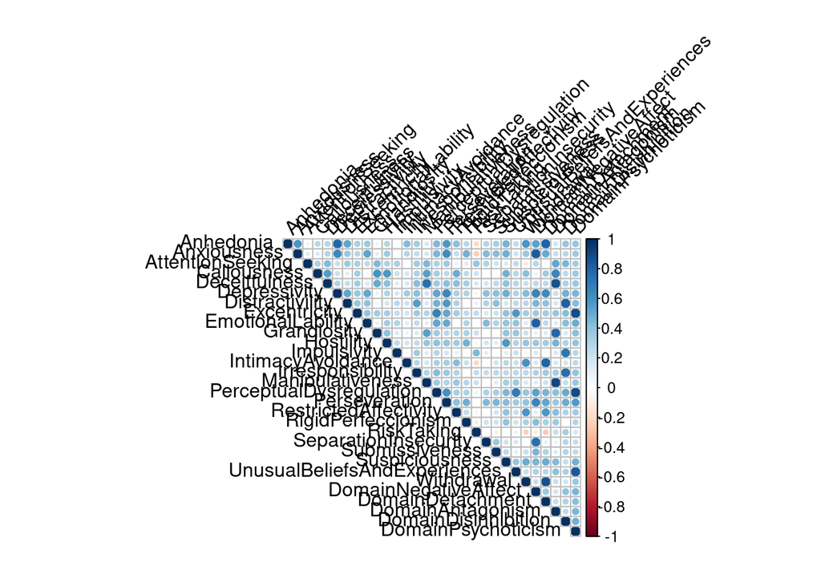

Se puede ver que hay correlaciones altas entre facetas, eso puede ser un problema para la regresión multivaiada.

```
##
## Call:  cv.glmnet(x = d_mat, y = d$ConfMean, type.measure = "mse", nfolds = nrow(d))
##
## Measure: Mean-Squared Error
##
##      Lambda Index Measure      SE Nonzero
## min 0.03675    11  0.2806 0.02287       6
## 1se 0.09316     1  0.2856 0.02351       0
```

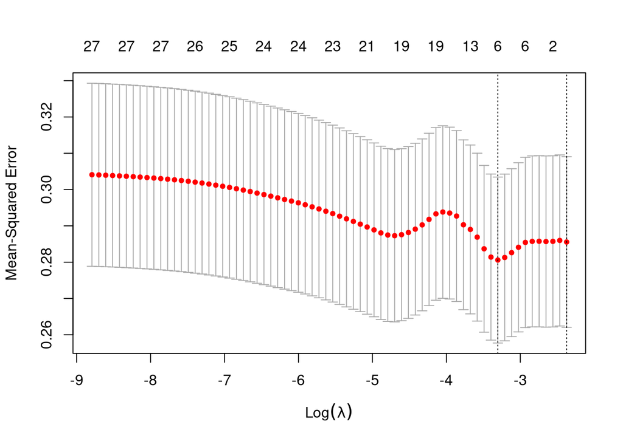

```
## 28 x 1 sparse Matrix of class "dgCMatrix"
##                                       s1
## (Intercept)                   2.61864887
## gender                        .
## Anhedonia                     .
## Anxiousness                   .
## AttentionSeeking              .
## Callousness                   .
## Deceitfulness                 .
## Depressivity                  .
## Distractivility               .
## Excentricity                  .
## EmotionalLability             .
## Grandiosity                   0.04703840
## Hostility                     0.03534389
## Impulsivity                   0.06812566
## IntimacyAvoidance             .
## Irresponsibility              .
## Manipulativeness              .
## PerceptualDysregulation       .
## Perseveration                 .
## RestrictedAffectivity         0.02647069
## RigidPerfeccionism            .
## RiskTaking                    .
## SeparationInsecurity         -0.02858590
## Submissiveness               -0.04508031
## Suspiciousness                .
## UnusualBeliefsAndExperiences  .
## Withdrawal                    .
## age                           .
```

Usando regularización con un alpha y lambda elegido por loocv

```
##
## Call:  glmnet(x = d_mat, y = d$ConfMean, family = "gaussian", alpha = alpha_selected,      lambda = lambda_selected)
##
##   Df %Dev Lambda
## 1  6 6.16 0.1555
```

```
## 28 x 1 sparse Matrix of class "dgCMatrix"
##                                       s0
## (Intercept)                   2.62326470
## gender                        .
## Anhedonia                     .
## Anxiousness                   .
## AttentionSeeking              .
## Callousness                   .
## Deceitfulness                 .
## Depressivity                  .
## Distractivility               .
## Excentricity                  .
## EmotionalLability             .
## Grandiosity                   0.04262017
## Hostility                     0.03413707
## Impulsivity                   0.05767559
## IntimacyAvoidance             .
## Irresponsibility              .
## Manipulativeness              .
## PerceptualDysregulation       .
## Perseveration                 .
## RestrictedAffectivity         0.02406707
## RigidPerfeccionism            .
## RiskTaking                    .
## SeparationInsecurity         -0.02577387
## Submissiveness               -0.03855809
## Suspiciousness                .
## UnusualBeliefsAndExperiences  .
## Withdrawal                    .
## age                           .
```

```
## [1] "probability of 0 (page 154, Statistical learning with sparsity... Hastie"
```

```
## [1] "intercept"
```

```
## [1] 0
```

```
## [1] "Grandiosity"
```

```
## [1] 0.7864
```

```
## [1] "Hostility"
```

```
## [1] 0.8128
```

```
## [1] "Impulsivity"
```

```
## [1] 0.7506
```

```
## [1] "RestrictedAffectivity"
```

```
## [1] 0.7962
```

```
## [1] "SeparationInsecurity"
```

```
## [1] 0.7434
```

```
## [1] "Submissiveness"
```

```
## [1] 0.743
```

Conclusión: Acá hay una mayor diversidad de resultados. El análisis mñas conservador es el último, que no muestra ningún tipo de relación entre alpha y lambda elegido por loocv. Aunque sin duda grandiosidad muestra cierta relación, que es significativa en la mayoría de los análisis.

# Analisis para metacognición

#### dominios

Regresion beta multivariada (sin escalar, mc va de 0.5 a 1)

```
##
## Call:
## betareg(formula = mc ~ DomainNegativeAffect.norm + DomainDetachment.norm +
##     DomainAntagonism.norm + DomainDisinhibition.norm + DomainPsychoticism.norm +
##     gender + age.norm, data = d)
##
## Standardized weighted residuals 2:
##     Min      1Q  Median      3Q     Max
## -1.8148 -0.7148 -0.0619  0.6363  2.8358
##
## Coefficients (mean model with logit link):
##                            Estimate Std. Error z value Pr(>|z|)
## (Intercept)                0.473653   0.019078  24.827   <2e-16 ***
## DomainNegativeAffect.norm  0.007879   0.019838   0.397   0.6913
## DomainDetachment.norm     -0.009204   0.018229  -0.505   0.6136
## DomainAntagonism.norm      0.030911   0.018693   1.654   0.0982 .
## DomainDisinhibition.norm  -0.008920   0.018981  -0.470   0.6384
## DomainPsychoticism.norm    0.006168   0.021356   0.289   0.7727
## gender                     0.011319   0.036778   0.308   0.7583
## age.norm                   0.012006   0.017206   0.698   0.4853
##
## Phi coefficients (precision model with identity link):
##       Estimate Std. Error z value Pr(>|z|)
## (phi)   72.417      6.798   10.65   <2e-16 ***
## ---
## Signif. codes:  0 '***' 0.001 '**' 0.01 '*' 0.05 '.' 0.1 ' ' 1
##
## Type of estimator: ML (maximum likelihood)
## Log-likelihood: 325.2 on 9 Df
## Pseudo R-squared: 0.01848
## Number of iterations: 19 (BFGS) + 2 (Fisher scoring)
```

Regresion beta multivariada (escalada, mc va de 0 a 1, se hizo (mc-0.5)*2)

```
##
## Call:
## betareg(formula = mc.norm ~ DomainNegativeAffect.norm + DomainDetachment.norm +
##     DomainAntagonism.norm + DomainDisinhibition.norm + DomainPsychoticism.norm +
##     gender + age.norm, data = d)
##
## Standardized weighted residuals 2:
##     Min      1Q  Median      3Q     Max
## -3.5838 -0.4859  0.1785  0.7141  1.9636
##
## Coefficients (mean model with logit link):
##                           Estimate Std. Error z value Pr(>|z|)
## (Intercept)               -1.20103    0.05169 -23.234   <2e-16 ***
## DomainNegativeAffect.norm  0.01378    0.05231   0.263   0.7922
## DomainDetachment.norm     -0.01756    0.04815  -0.365   0.7154
## DomainAntagonism.norm      0.08673    0.04877   1.778   0.0754 .
## DomainDisinhibition.norm  -0.03046    0.05001  -0.609   0.5424
## DomainPsychoticism.norm    0.01871    0.05602   0.334   0.7384
## gender                     0.01606    0.09661   0.166   0.8680
## age.norm                   0.04100    0.04494   0.912   0.3616
##
## Phi coefficients (precision model with identity link):
##       Estimate Std. Error z value Pr(>|z|)
## (phi)   11.980      1.105   10.84   <2e-16 ***
## ---
## Signif. codes:  0 '***' 0.001 '**' 0.01 '*' 0.05 '.' 0.1 ' ' 1
##
## Type of estimator: ML (maximum likelihood)
## Log-likelihood: 175.6 on 9 Df
## Pseudo R-squared: 0.01818
## Number of iterations: 17 (BFGS) + 1 (Fisher scoring)
```

Regresion beta univariada (sin escalar, mc va de 0.5 a 1)

```
## [1] "Antagonismo"
```

```
##
## Call:
## betareg(formula = mc ~ vec_variables_values[[i]] + age.norm + gender +
##     age.norm:vec_variables_values[[i]] + gender:vec_variables_values[[i]],
##     data = d)
##
## Standardized weighted residuals 2:
##     Min      1Q  Median      3Q     Max
## -1.7861 -0.6674 -0.0785  0.6143  2.8214
##
## Coefficients (mean model with logit link):
##                                     Estimate Std. Error z value Pr(>|z|)
## (Intercept)                         0.468019   0.020065  23.325   <2e-16 ***
## vec_variables_values[[i]]           0.021864   0.019933   1.097    0.273
## age.norm                            0.001263   0.019617   0.064    0.949
## gender                              0.012811   0.036943   0.347    0.729
## vec_variables_values[[i]]:age.norm -0.017234   0.020382  -0.846    0.398
## vec_variables_values[[i]]:gender    0.016926   0.038284   0.442    0.658
##
## Phi coefficients (precision model with identity link):
##       Estimate Std. Error z value Pr(>|z|)
## (phi)   72.528      6.808   10.65   <2e-16 ***
## ---
## Signif. codes:  0 '***' 0.001 '**' 0.01 '*' 0.05 '.' 0.1 ' ' 1
##
## Type of estimator: ML (maximum likelihood)
## Log-likelihood: 325.4 on 7 Df
## Pseudo R-squared: 0.01995
## Number of iterations: 17 (BFGS) + 2 (Fisher scoring)
```

```
## [1] "Detachment"
```

```
##
## Call:
## betareg(formula = mc ~ vec_variables_values[[i]] + age.norm + gender +
##     age.norm:vec_variables_values[[i]] + gender:vec_variables_values[[i]],
##     data = d)
##
## Standardized weighted residuals 2:
##     Min      1Q  Median      3Q     Max
## -1.8188 -0.7113 -0.0552  0.6130  2.9025
##
## Coefficients (mean model with logit link):
##                                     Estimate Std. Error z value Pr(>|z|)
## (Intercept)                         0.472487   0.019306  24.473   <2e-16 ***
## vec_variables_values[[i]]           0.002495   0.018747   0.133    0.894
## age.norm                            0.004547   0.016543   0.275    0.783
## gender                              0.017884   0.036371   0.492    0.623
## vec_variables_values[[i]]:age.norm  0.009012   0.017722   0.509    0.611
## vec_variables_values[[i]]:gender   -0.008188   0.039184  -0.209    0.834
##
## Phi coefficients (precision model with identity link):
##       Estimate Std. Error z value Pr(>|z|)
## (phi)   71.280      6.691   10.65   <2e-16 ***
## ---
## Signif. codes:  0 '***' 0.001 '**' 0.01 '*' 0.05 '.' 0.1 ' ' 1
##
## Type of estimator: ML (maximum likelihood)
## Log-likelihood: 323.4 on 7 Df
## Pseudo R-squared: 0.002861
## Number of iterations: 16 (BFGS) + 2 (Fisher scoring)
```

```
## [1] "Disinhibition"
```

```
##
## Call:
## betareg(formula = mc ~ vec_variables_values[[i]] + age.norm + gender +
##     age.norm:vec_variables_values[[i]] + gender:vec_variables_values[[i]],
##     data = d)
##
## Standardized weighted residuals 2:
##     Min      1Q  Median      3Q     Max
## -1.8392 -0.6872 -0.0528  0.6367  2.8717
##
## Coefficients (mean model with logit link):
##                                      Estimate Std. Error z value Pr(>|z|)
## (Intercept)                         4.678e-01  1.932e-02  24.218   <2e-16 ***
## vec_variables_values[[i]]          -4.196e-05  1.917e-02  -0.002    0.998
## age.norm                           -9.922e-04  1.700e-02  -0.058    0.953
## gender                              2.332e-02  3.608e-02   0.646    0.518
## vec_variables_values[[i]]:age.norm -1.767e-02  1.839e-02  -0.961    0.336
## vec_variables_values[[i]]:gender    1.278e-04  3.676e-02   0.003    0.997
##
## Phi coefficients (precision model with identity link):
##       Estimate Std. Error z value Pr(>|z|)
## (phi)    71.48       6.71   10.65   <2e-16 ***
## ---
## Signif. codes:  0 '***' 0.001 '**' 0.01 '*' 0.05 '.' 0.1 ' ' 1
##
## Type of estimator: ML (maximum likelihood)
## Log-likelihood: 323.8 on 7 Df
## Pseudo R-squared: 0.005631
## Number of iterations: 20 (BFGS) + 2 (Fisher scoring)
```

```
## [1] "NegativeAffect"
```

```
##
## Call:
## betareg(formula = mc ~ vec_variables_values[[i]] + age.norm + gender +
##     age.norm:vec_variables_values[[i]] + gender:vec_variables_values[[i]],
##     data = d)
##
## Standardized weighted residuals 2:
##     Min      1Q  Median      3Q     Max
## -1.8323 -0.6921 -0.0617  0.6424  2.9010
##
## Coefficients (mean model with logit link):
##                                     Estimate Std. Error z value Pr(>|z|)
## (Intercept)                         0.467779   0.020424  22.904   <2e-16 ***
## vec_variables_values[[i]]           0.006733   0.020580   0.327    0.744
## age.norm                            0.002449   0.019186   0.128    0.898
## gender                              0.024672   0.036967   0.667    0.505
## vec_variables_values[[i]]:age.norm -0.007361   0.020670  -0.356    0.722
## vec_variables_values[[i]]:gender    0.002647   0.036732   0.072    0.943
##
## Phi coefficients (precision model with identity link):
##       Estimate Std. Error z value Pr(>|z|)
## (phi)   71.306      6.693   10.65   <2e-16 ***
## ---
## Signif. codes:  0 '***' 0.001 '**' 0.01 '*' 0.05 '.' 0.1 ' ' 1
##
## Type of estimator: ML (maximum likelihood)
## Log-likelihood: 323.5 on 7 Df
## Pseudo R-squared: 0.003199
## Number of iterations: 25 (BFGS) + 2 (Fisher scoring)
```

```
## [1] "Psychoticism"
```

```
##
## Call:
## betareg(formula = mc ~ vec_variables_values[[i]] + age.norm + gender +
##     age.norm:vec_variables_values[[i]] + gender:vec_variables_values[[i]],
##     data = d)
##
## Standardized weighted residuals 2:
##     Min      1Q  Median      3Q     Max
## -1.8242 -0.7157 -0.0303  0.6294  2.9246
##
## Coefficients (mean model with logit link):
##                                    Estimate Std. Error z value Pr(>|z|)
## (Intercept)                        0.471916   0.019607  24.069   <2e-16 ***
## vec_variables_values[[i]]          0.005957   0.019458   0.306    0.759
## age.norm                           0.005728   0.017255   0.332    0.740
## gender                             0.017514   0.036047   0.486    0.627
## vec_variables_values[[i]]:age.norm 0.002934   0.019390   0.151    0.880
## vec_variables_values[[i]]:gender   0.038383   0.039060   0.983    0.326
##
## Phi coefficients (precision model with identity link):
##       Estimate Std. Error z value Pr(>|z|)
## (phi)   71.776      6.737   10.65   <2e-16 ***
## ---
## Signif. codes:  0 '***' 0.001 '**' 0.01 '*' 0.05 '.' 0.1 ' ' 1
##
## Type of estimator: ML (maximum likelihood)
## Log-likelihood: 324.2 on 7 Df
## Pseudo R-squared: 0.009708
## Number of iterations: 15 (BFGS) + 1 (Fisher scoring)
```

Regresion beta univariada (escalada, mc va de 0 a 1, se hizo (mc-0.5)*2)

```
## [1] "Antagonismo"
```

```
##
## Call:
## betareg(formula = mc.norm ~ vec_variables_values[[i]] + age.norm + gender +
##     age.norm:vec_variables_values[[i]] + gender:vec_variables_values[[i]],
##     data = d)
##
## Standardized weighted residuals 2:
##     Min      1Q  Median      3Q     Max
## -3.6138 -0.4464  0.1377  0.6735  1.9405
##
## Coefficients (mean model with logit link):
##                                     Estimate Std. Error z value Pr(>|z|)
## (Intercept)                        -1.219582   0.054419 -22.411   <2e-16 ***
## vec_variables_values[[i]]           0.061265   0.051937   1.180    0.238
## age.norm                            0.008472   0.051272   0.165    0.869
## gender                              0.025966   0.097834   0.265    0.791
## vec_variables_values[[i]]:age.norm -0.054259   0.052381  -1.036    0.300
## vec_variables_values[[i]]:gender    0.038972   0.099285   0.393    0.695
##
## Phi coefficients (precision model with identity link):
##       Estimate Std. Error z value Pr(>|z|)
## (phi)   12.015      1.109   10.84   <2e-16 ***
## ---
## Signif. codes:  0 '***' 0.001 '**' 0.01 '*' 0.05 '.' 0.1 ' ' 1
##
## Type of estimator: ML (maximum likelihood)
## Log-likelihood: 175.9 on 7 Df
## Pseudo R-squared: 0.0209
## Number of iterations: 14 (BFGS) + 2 (Fisher scoring)
```

```
## [1] "Detachment"
```

```
##
## Call:
## betareg(formula = mc.norm ~ vec_variables_values[[i]] + age.norm + gender +
##     age.norm:vec_variables_values[[i]] + gender:vec_variables_values[[i]],
##     data = d)
##
## Standardized weighted residuals 2:
##     Min      1Q  Median      3Q     Max
## -3.7489 -0.4815  0.1752  0.7102  1.9997
##
## Coefficients (mean model with logit link):
##                                    Estimate Std. Error z value Pr(>|z|)
## (Intercept)                        -1.20376    0.05235 -22.995   <2e-16 ***
## vec_variables_values[[i]]           0.01372    0.04950   0.277    0.782
## age.norm                            0.02352    0.04315   0.545    0.586
## gender                              0.03524    0.09561   0.369    0.712
## vec_variables_values[[i]]:age.norm  0.01484    0.04632   0.320    0.749
## vec_variables_values[[i]]:gender   -0.03123    0.10301  -0.303    0.762
##
## Phi coefficients (precision model with identity link):
##       Estimate Std. Error z value Pr(>|z|)
## (phi)   11.766      1.085   10.84   <2e-16 ***
## ---
## Signif. codes:  0 '***' 0.001 '**' 0.01 '*' 0.05 '.' 0.1 ' ' 1
##
## Type of estimator: ML (maximum likelihood)
## Log-likelihood: 173.6 on 7 Df
## Pseudo R-squared: 0.002478
## Number of iterations: 14 (BFGS) + 2 (Fisher scoring)
```

```
## [1] "Disinhibition"
```

```
##
## Call:
## betareg(formula = mc.norm ~ vec_variables_values[[i]] + age.norm + gender +
##     age.norm:vec_variables_values[[i]] + gender:vec_variables_values[[i]],
##     data = d)
##
## Standardized weighted residuals 2:
##     Min      1Q  Median      3Q     Max
## -3.7660 -0.4838  0.1495  0.7132  1.9800
##
## Coefficients (mean model with logit link):
##                                     Estimate Std. Error z value Pr(>|z|)
## (Intercept)                        -1.212006   0.052626 -23.031   <2e-16 ***
## vec_variables_values[[i]]          -0.001847   0.050843  -0.036    0.971
## age.norm                            0.011102   0.044910   0.247    0.805
## gender                              0.047302   0.094921   0.498    0.618
## vec_variables_values[[i]]:age.norm -0.030648   0.048524  -0.632    0.528
## vec_variables_values[[i]]:gender   -0.005238   0.096612  -0.054    0.957
##
## Phi coefficients (precision model with identity link):
##       Estimate Std. Error z value Pr(>|z|)
## (phi)   11.779      1.086   10.84   <2e-16 ***
## ---
## Signif. codes:  0 '***' 0.001 '**' 0.01 '*' 0.05 '.' 0.1 ' ' 1
##
## Type of estimator: ML (maximum likelihood)
## Log-likelihood: 173.7 on 7 Df
## Pseudo R-squared: 0.003615
## Number of iterations: 15 (BFGS) + 2 (Fisher scoring)
```

```
## [1] "NegativeAffect"
```

```
##
## Call:
## betareg(formula = mc.norm ~ vec_variables_values[[i]] + age.norm + gender +
##     age.norm:vec_variables_values[[i]] + gender:vec_variables_values[[i]],
##     data = d)
##
## Standardized weighted residuals 2:
##     Min      1Q  Median      3Q     Max
## -3.7608 -0.4658  0.1734  0.7034  2.0119
##
## Coefficients (mean model with logit link):
##                                     Estimate Std. Error z value Pr(>|z|)
## (Intercept)                        -1.216876   0.055329 -21.994   <2e-16 ***
## vec_variables_values[[i]]          -0.005342   0.054286  -0.098    0.922
## age.norm                            0.010074   0.050273   0.200    0.841
## gender                              0.060487   0.096688   0.626    0.532
## vec_variables_values[[i]]:age.norm -0.030153   0.053472  -0.564    0.573
## vec_variables_values[[i]]:gender    0.061976   0.096179   0.644    0.519
##
## Phi coefficients (precision model with identity link):
##       Estimate Std. Error z value Pr(>|z|)
## (phi)   11.800      1.088   10.84   <2e-16 ***
## ---
## Signif. codes:  0 '***' 0.001 '**' 0.01 '*' 0.05 '.' 0.1 ' ' 1
##
## Type of estimator: ML (maximum likelihood)
## Log-likelihood: 173.9 on 7 Df
## Pseudo R-squared: 0.004938
## Number of iterations: 14 (BFGS) + 2 (Fisher scoring)
```

```
## [1] "Psychoticism"
```

```
##
## Call:
## betareg(formula = mc.norm ~ vec_variables_values[[i]] + age.norm + gender +
##     age.norm:vec_variables_values[[i]] + gender:vec_variables_values[[i]],
##     data = d)
##
## Standardized weighted residuals 2:
##     Min      1Q  Median      3Q     Max
## -3.7517 -0.5075  0.1950  0.7074  1.9975
##
## Coefficients (mean model with logit link):
##                                     Estimate Std. Error z value Pr(>|z|)
## (Intercept)                        -1.209330   0.053132 -22.761   <2e-16 ***
## vec_variables_values[[i]]           0.010474   0.051260   0.204    0.838
## age.norm                            0.020882   0.044871   0.465    0.642
## gender                              0.036741   0.094931   0.387    0.699
## vec_variables_values[[i]]:age.norm -0.009598   0.050187  -0.191    0.848
## vec_variables_values[[i]]:gender    0.118578   0.101939   1.163    0.245
##
## Phi coefficients (precision model with identity link):
##       Estimate Std. Error z value Pr(>|z|)
## (phi)   11.872      1.095   10.84   <2e-16 ***
## ---
## Signif. codes:  0 '***' 0.001 '**' 0.01 '*' 0.05 '.' 0.1 ' ' 1
##
## Type of estimator: ML (maximum likelihood)
## Log-likelihood: 174.6 on 7 Df
## Pseudo R-squared: 0.01026
## Number of iterations: 14 (BFGS) + 2 (Fisher scoring)
```

Regresion lineal multivariada

```
##
## Call:
## lm(formula = mc ~ DomainNegativeAffect.norm + DomainDetachment.norm +
##     DomainAntagonism.norm + DomainDisinhibition.norm + DomainPsychoticism.norm +
##     gender + age.norm, data = d)
##
## Residuals:
##       Min        1Q    Median        3Q       Max
## -0.105796 -0.039577 -0.002291  0.037214  0.145432
##
## Coefficients:
##                            Estimate Std. Error t value Pr(>|t|)
## (Intercept)                0.616166   0.004560 135.114   <2e-16 ***
## DomainNegativeAffect.norm  0.001803   0.004743   0.380    0.704
## DomainDetachment.norm     -0.002020   0.004359  -0.463    0.644
## DomainAntagonism.norm      0.007327   0.004460   1.643    0.102
## DomainDisinhibition.norm  -0.002220   0.004536  -0.489    0.625
## DomainPsychoticism.norm    0.001417   0.005101   0.278    0.781
## gender                     0.002470   0.008785   0.281    0.779
## age.norm                   0.002822   0.004110   0.687    0.493
## ---
## Signif. codes:  0 '***' 0.001 '**' 0.01 '*' 0.05 '.' 0.1 ' ' 1
##
## Residual standard error: 0.05737 on 216 degrees of freedom
## Multiple R-squared:  0.01851,    Adjusted R-squared:  -0.01329
## F-statistic: 0.5821 on 7 and 216 DF,  p-value: 0.7702
```

Regresion lineal univariada

```
## [1] "Antagonismo"
```

```
##
## Call:
## lm(formula = mc ~ vec_variables_values[[i]] + age.norm + gender +
##     age.norm:vec_variables_values[[i]] + gender:vec_variables_values[[i]],
##     data = d)
##
## Residuals:
##       Min        1Q    Median        3Q       Max
## -0.104276 -0.036798 -0.002861  0.035652  0.144481
##
## Coefficients:
##                                     Estimate Std. Error t value Pr(>|t|)
## (Intercept)                         0.614776   0.004776 128.726   <2e-16 ***
## vec_variables_values[[i]]           0.005113   0.004733   1.080    0.281
## age.norm                            0.000201   0.004661   0.043    0.966
## gender                              0.002877   0.008795   0.327    0.744
## vec_variables_values[[i]]:age.norm -0.004237   0.004829  -0.877    0.381
## vec_variables_values[[i]]:gender    0.004008   0.009077   0.442    0.659
## ---
## Signif. codes:  0 '***' 0.001 '**' 0.01 '*' 0.05 '.' 0.1 ' ' 1
##
## Residual standard error: 0.05705 on 218 degrees of freedom
## Multiple R-squared:  0.0204, Adjusted R-squared:  -0.002065
## F-statistic: 0.9081 on 5 and 218 DF,  p-value: 0.4766
```

```
## [1] "Detachment"
```

```
##
## Call:
## lm(formula = mc ~ vec_variables_values[[i]] + age.norm + gender +
##     age.norm:vec_variables_values[[i]] + gender:vec_variables_values[[i]],
##     data = d)
##
## Residuals:
##       Min        1Q    Median        3Q       Max
## -0.107257 -0.039191 -0.001469  0.036458  0.150414
##
## Coefficients:
##                                      Estimate Std. Error t value Pr(>|t|)
## (Intercept)                         0.6158688  0.0045965 133.986   <2e-16 ***
## vec_variables_values[[i]]           0.0006829  0.0044662   0.153    0.879
## age.norm                            0.0010704  0.0039345   0.272    0.786
## gender                              0.0040583  0.0086526   0.469    0.640
## vec_variables_values[[i]]:age.norm  0.0018283  0.0042155   0.434    0.665
## vec_variables_values[[i]]:gender   -0.0019521  0.0093225  -0.209    0.834
## ---
## Signif. codes:  0 '***' 0.001 '**' 0.01 '*' 0.05 '.' 0.1 ' ' 1
##
## Residual standard error: 0.05757 on 218 degrees of freedom
## Multiple R-squared:  0.002471,   Adjusted R-squared:  -0.02041
## F-statistic: 0.108 on 5 and 218 DF,  p-value: 0.9905
```

```
## [1] "Disinhibition"
```

```
##
## Call:
## lm(formula = mc ~ vec_variables_values[[i]] + age.norm + gender +
##     age.norm:vec_variables_values[[i]] + gender:vec_variables_values[[i]],
##     data = d)
##
## Residuals:
##       Min        1Q    Median        3Q       Max
## -0.108179 -0.038133 -0.001717  0.037408  0.148705
##
## Coefficients:
##                                      Estimate Std. Error t value Pr(>|t|)
## (Intercept)                         0.6148592  0.0046036 133.561   <2e-16 ***
## vec_variables_values[[i]]          -0.0001259  0.0045681  -0.028    0.978
## age.norm                           -0.0001967  0.0040526  -0.049    0.961
## gender                              0.0052570  0.0085854   0.612    0.541
## vec_variables_values[[i]]:age.norm -0.0039039  0.0043805  -0.891    0.374
## vec_variables_values[[i]]:gender    0.0001546  0.0087428   0.018    0.986
## ---
## Signif. codes:  0 '***' 0.001 '**' 0.01 '*' 0.05 '.' 0.1 ' ' 1
##
## Residual standard error: 0.05749 on 218 degrees of freedom
## Multiple R-squared:  0.005126,   Adjusted R-squared:  -0.01769
## F-statistic: 0.2247 on 5 and 218 DF,  p-value: 0.9516
```

```
## [1] "NegativeAffect"
```

```
##
## Call:
## lm(formula = mc ~ vec_variables_values[[i]] + age.norm + gender +
##     age.norm:vec_variables_values[[i]] + gender:vec_variables_values[[i]],
##     data = d)
##
## Residuals:
##       Min        1Q    Median        3Q       Max
## -0.107967 -0.038570 -0.002055  0.037924  0.150355
##
## Coefficients:
##                                      Estimate Std. Error t value Pr(>|t|)
## (Intercept)                         0.6147325  0.0048644 126.375   <2e-16 ***
## vec_variables_values[[i]]           0.0012642  0.0049017   0.258    0.797
## age.norm                            0.0004199  0.0045649   0.092    0.927
## gender                              0.0057266  0.0087894   0.652    0.515
## vec_variables_values[[i]]:age.norm -0.0020301  0.0049120  -0.413    0.680
## vec_variables_values[[i]]:gender    0.0013420  0.0087338   0.154    0.878
## ---
## Signif. codes:  0 '***' 0.001 '**' 0.01 '*' 0.05 '.' 0.1 ' ' 1
##
## Residual standard error: 0.05754 on 218 degrees of freedom
## Multiple R-squared:  0.00333,    Adjusted R-squared:  -0.01953
## F-statistic: 0.1457 on 5 and 218 DF,  p-value: 0.9812
```

```
## [1] "Psychoticism"
```

```
##
## Call:
## lm(formula = mc ~ vec_variables_values[[i]] + age.norm + gender +
##     age.norm:vec_variables_values[[i]] + gender:vec_variables_values[[i]],
##     data = d)
##
## Residuals:
##       Min        1Q    Median        3Q       Max
## -0.107109 -0.039768 -0.000105  0.037082  0.150989
##
## Coefficients:
##                                     Estimate Std. Error t value Pr(>|t|)
## (Intercept)                        0.6156776  0.0046669 131.923   <2e-16 ***
## vec_variables_values[[i]]          0.0012516  0.0046316   0.270    0.787
## age.norm                           0.0012469  0.0040984   0.304    0.761
## gender                             0.0039723  0.0085751   0.463    0.644
## vec_variables_values[[i]]:age.norm 0.0002971  0.0046033   0.065    0.949
## vec_variables_values[[i]]:gender   0.0092670  0.0092774   0.999    0.319
## ---
## Signif. codes:  0 '***' 0.001 '**' 0.01 '*' 0.05 '.' 0.1 ' ' 1
##
## Residual standard error: 0.05736 on 218 degrees of freedom
## Multiple R-squared:  0.009663,   Adjusted R-squared:  -0.01305
## F-statistic: 0.4254 on 5 and 218 DF,  p-value: 0.8307
```

Regresión logística mixta

```
## Generalized linear mixed model fit by maximum likelihood (Laplace
##   Approximation) [glmerMod]
##  Family: binomial  ( logit )
## Formula:
## discrimination_is_correct ~ confidence_key.norm + confidence_key.norm:DomainNegativeAffect.norm +
##     confidence_key.norm:DomainDetachment.norm + confidence_key.norm:DomainAntagonism.norm +
##     confidence_key.norm:DomainDisinhibition.norm + confidence_key.norm:DomainPsychoticism.norm +
##     confidence_key.norm:gender + confidence_key.norm:age.norm +
##     (1 | Participant)
##    Data: df_total
## Control: glmerControl(optimizer = "bobyqa", optCtrl = list(maxfun = 2e+05))
##
##      AIC      BIC   logLik deviance df.resid
##  26591.9  26672.5 -13285.9  26571.9    23471
##
## Scaled residuals:
##     Min      1Q  Median      3Q     Max
## -2.5434 -1.1689  0.5200  0.6433  1.0263
##
## Random effects:
##  Groups      Name        Variance Std.Dev.
##  Participant (Intercept) 0.03641  0.1908
## Number of obs: 23481, groups:  Participant, 224
##
## Fixed effects:
##                                               Estimate Std. Error z value
## (Intercept)                                    0.28071    0.03664   7.661
## confidence_key.norm                            1.36015    0.06372  21.344
## confidence_key.norm:DomainNegativeAffect.norm  0.01755    0.03749   0.468
## confidence_key.norm:DomainDetachment.norm     -0.02345    0.03423  -0.685
## confidence_key.norm:DomainAntagonism.norm      0.01810    0.03513   0.515
## confidence_key.norm:DomainDisinhibition.norm  -0.05119    0.03563  -1.437
## confidence_key.norm:DomainPsychoticism.norm    0.01192    0.04069   0.293
## confidence_key.norm:gender                     0.05924    0.07052   0.840
## confidence_key.norm:age.norm                   0.02914    0.03374   0.864
##                                               Pr(>|z|)
## (Intercept)                                   1.84e-14 ***
## confidence_key.norm                            < 2e-16 ***
## confidence_key.norm:DomainNegativeAffect.norm    0.640
## confidence_key.norm:DomainDetachment.norm        0.493
```

[output cut: 12 more lines]

[output not shown]

Conclusión: No hay nada significativo, los dominios no muestran relación con metacognición

#### facetas

Regresion beta multivariada (sin escalar, mc va de 0.5 a 1)

```
##
## Call:
## betareg(formula = mc ~ Anhedonia.norm + Anxiousness.norm + AttentionSeeking.norm +
##     Callousness.norm + Deceitfulness.norm + Depressivity.norm + Distractivility.norm +
##     Excentricity.norm + EmotionalLability.norm + Grandiosity.norm + Hostility.norm +
##     Impulsivity.norm + IntimacyAvoidance.norm + Irresponsibility.norm +
##     Manipulativeness.norm + PerceptualDysregulation.norm + Perseveration.norm +
##     Perseveration.norm + RestrictedAffectivity.norm + RigidPerfeccionism.norm +
##     RiskTaking.norm + SeparationInsecurity.norm + Submissiveness.norm +
##     Suspiciousness.norm + UnusualBeliefsAndExperiences.norm + Withdrawal.norm +
##     gender + age.norm, data = d)
##
## Standardized weighted residuals 2:
##     Min      1Q  Median      3Q     Max
## -2.1403 -0.7904 -0.0680  0.6156  3.5583
##
## Coefficients (mean model with logit link):
##                                     Estimate Std. Error z value Pr(>|z|)
## (Intercept)                        0.4783392  0.0190048  25.169  < 2e-16 ***
## Anhedonia.norm                    -0.0199752  0.0303714  -0.658  0.51073
## Anxiousness.norm                   0.0678900  0.0256057   2.651  0.00802 **
## AttentionSeeking.norm              0.0054988  0.0236211   0.233  0.81592
## Callousness.norm                   0.0203546  0.0266593   0.764  0.44516
## Deceitfulness.norm                -0.0275560  0.0278349  -0.990  0.32219
## Depressivity.norm                 -0.0107651  0.0306154  -0.352  0.72512
## Distractivility.norm              -0.0105880  0.0258550  -0.410  0.68216
## Excentricity.norm                 -0.0038783  0.0245183  -0.158  0.87431
## EmotionalLability.norm            -0.0291732  0.0237243  -1.230  0.21882
## Grandiosity.norm                   0.0020881  0.0234246   0.089  0.92897
## Hostility.norm                    -0.0192715  0.0244408  -0.788  0.43041
## Impulsivity.norm                  -0.0237198  0.0199307  -1.190  0.23400
## IntimacyAvoidance.norm            -0.0180847  0.0216578  -0.835  0.40371
## Irresponsibility.norm              0.0279298  0.0226503   1.233  0.21754
## Manipulativeness.norm              0.0381440  0.0267492   1.426  0.15387
## PerceptualDysregulation.norm       0.0444697  0.0303099   1.467  0.14233
## Perseveration.norm                 0.0090999  0.0288239   0.316  0.75223
## RestrictedAffectivity.norm         0.0158962  0.0227585   0.698  0.48488
## RigidPerfeccionism.norm            0.0012016  0.0219665   0.055  0.95638
## RiskTaking.norm                    0.0033760  0.0210008   0.161  0.87229
## SeparationInsecurity.norm         -0.0096536  0.0206177  -0.468  0.63963
## Submissiveness.norm               -0.0001769  0.0199842  -0.009  0.99294
## Suspiciousness.norm               -0.0284507  0.0239675  -1.187  0.23521
## UnusualBeliefsAndExperiences.norm -0.0116656  0.0240662  -0.485  0.62787
## Withdrawal.norm                   -0.0114409  0.0281417  -0.407  0.68434
## gender                            -0.0034411  0.0397508  -0.087  0.93102
## age.norm                           0.0154096  0.0170945   0.901  0.36735
##
## Phi coefficients (precision model with identity link):
##       Estimate Std. Error z value Pr(>|z|)
## (phi)   79.164      7.435   10.65   <2e-16 ***
## ---
## Signif. codes:  0 '***' 0.001 '**' 0.01 '*' 0.05 '.' 0.1 ' ' 1
##
## Type of estimator: ML (maximum likelihood)
## Log-likelihood: 335.2 on 29 Df
## Pseudo R-squared: 0.102
## Number of iterations: 37 (BFGS) + 2 (Fisher scoring)
```

Regresion beta multivariada (escalada, mc va de 0 a 1, se hizo (mc-0.5)*2)

```
##
## Call:
## betareg(formula = mc.norm ~ Anhedonia.norm + Anxiousness.norm + AttentionSeeking.norm +
##     Callousness.norm + Deceitfulness.norm + Depressivity.norm + Distractivility.norm +
##     Excentricity.norm + EmotionalLability.norm + Grandiosity.norm + Hostility.norm +
##     Impulsivity.norm + IntimacyAvoidance.norm + Irresponsibility.norm +
##     Manipulativeness.norm + PerceptualDysregulation.norm + Perseveration.norm +
##     Perseveration.norm + RestrictedAffectivity.norm + RigidPerfeccionism.norm +
##     RiskTaking.norm + SeparationInsecurity.norm + Submissiveness.norm +
##     Suspiciousness.norm + UnusualBeliefsAndExperiences.norm + Withdrawal.norm +
##     gender + age.norm, data = d)
##
## Standardized weighted residuals 2:
##     Min      1Q  Median      3Q     Max
## -4.0019 -0.6386  0.1051  0.7049  2.4779
##
## Coefficients (mean model with logit link):
##                                     Estimate Std. Error z value Pr(>|z|)
## (Intercept)                       -1.1919144  0.0510493 -23.348   <2e-16 ***
## Anhedonia.norm                    -0.0591726  0.0804035  -0.736   0.4618
## Anxiousness.norm                   0.1642042  0.0677617   2.423   0.0154 *
## AttentionSeeking.norm             -0.0109926  0.0627046  -0.175   0.8608
## Callousness.norm                   0.0562355  0.0697608   0.806   0.4202
## Deceitfulness.norm                -0.0909608  0.0729585  -1.247   0.2125
## Depressivity.norm                 -0.0048505  0.0812492  -0.060   0.9524
## Distractivility.norm              -0.0246194  0.0675736  -0.364   0.7156
## Excentricity.norm                  0.0013444  0.0649310   0.021   0.9835
## EmotionalLability.norm            -0.1267753  0.0622687  -2.036   0.0418 *
## Grandiosity.norm                  -0.0005755  0.0612071  -0.009   0.9925
## Hostility.norm                    -0.0739184  0.0640249  -1.155   0.2483
## Impulsivity.norm                  -0.0769044  0.0533798  -1.441   0.1497
## IntimacyAvoidance.norm            -0.0658546  0.0571862  -1.152   0.2495
## Irresponsibility.norm              0.0655154  0.0589997   1.110   0.2668
## Manipulativeness.norm              0.1343686  0.0704164   1.908   0.0564 .
## PerceptualDysregulation.norm       0.1019879  0.0796033   1.281   0.2001
## Perseveration.norm                 0.0506463  0.0759022   0.667   0.5046
## RestrictedAffectivity.norm         0.0161912  0.0596519   0.271   0.7861
## RigidPerfeccionism.norm            0.0214814  0.0577643   0.372   0.7100
## RiskTaking.norm                    0.0401800  0.0559420   0.718   0.4726
## SeparationInsecurity.norm         -0.0023334  0.0542905  -0.043   0.9657
## Submissiveness.norm                0.0203994  0.0525585   0.388   0.6979
## Suspiciousness.norm               -0.0847635  0.0634748  -1.335   0.1817
## UnusualBeliefsAndExperiences.norm -0.0112519  0.0644219  -0.175   0.8613
## Withdrawal.norm                    0.0006069  0.0749221   0.008   0.9935
## gender                            -0.0569796  0.1044510  -0.546   0.5854
## age.norm                           0.0484634  0.0451103   1.074   0.2827
##
## Phi coefficients (precision model with identity link):
##       Estimate Std. Error z value Pr(>|z|)
## (phi)   13.381      1.238    10.8   <2e-16 ***
## ---
## Signif. codes:  0 '***' 0.001 '**' 0.01 '*' 0.05 '.' 0.1 ' ' 1
##
## Type of estimator: ML (maximum likelihood)
## Log-likelihood: 187.5 on 29 Df
## Pseudo R-squared: 0.1086
## Number of iterations: 39 (BFGS) + 2 (Fisher scoring)
```

Regresion beta univariada (sin escalar, mc va de 0.5 a 1)

```
## [1] "Anhedonia"
```

```
##
## Call:
## betareg(formula = mc ~ vec_variables_values[[i]] + age.norm + gender +
##     age.norm:vec_variables_values[[i]] + gender:vec_variables_values[[i]],
##     data = d)
##
## Standardized weighted residuals 2:
##     Min      1Q  Median      3Q     Max
## -1.8067 -0.6962 -0.0582  0.6213  2.9251
##
## Coefficients (mean model with logit link):
##                                     Estimate Std. Error z value Pr(>|z|)
## (Intercept)                         0.469707   0.019399  24.213   <2e-16 ***
## vec_variables_values[[i]]           0.003352   0.018864   0.178    0.859
## age.norm                            0.003314   0.016976   0.195    0.845
## gender                              0.020174   0.036771   0.549    0.583
## vec_variables_values[[i]]:age.norm -0.005658   0.017551  -0.322    0.747
## vec_variables_values[[i]]:gender   -0.023587   0.041728  -0.565    0.572
##
## Phi coefficients (precision model with identity link):
##       Estimate Std. Error z value Pr(>|z|)
## (phi)    71.38       6.70   10.65   <2e-16 ***
## ---
## Signif. codes:  0 '***' 0.001 '**' 0.01 '*' 0.05 '.' 0.1 ' ' 1
##
## Type of estimator: ML (maximum likelihood)
## Log-likelihood: 323.6 on 7 Df
## Pseudo R-squared: 0.004172
## Number of iterations: 13 (BFGS) + 2 (Fisher scoring)
```

```
## [1] "Anxiousness"
```

```
##
## Call:
## betareg(formula = mc ~ vec_variables_values[[i]] + age.norm + gender +
##     age.norm:vec_variables_values[[i]] + gender:vec_variables_values[[i]],
##     data = d)
##
## Standardized weighted residuals 2:
##     Min      1Q  Median      3Q     Max
## -1.9669 -0.7308 -0.0746  0.6539  2.9086
##
## Coefficients (mean model with logit link):
##                                     Estimate Std. Error z value Pr(>|z|)
## (Intercept)                         0.470568   0.019796  23.771   <2e-16 ***
## vec_variables_values[[i]]           0.038372   0.019456   1.972   0.0486 *
## age.norm                            0.014260   0.018015   0.792   0.4286
## gender                              0.024650   0.036544   0.675   0.5000
## vec_variables_values[[i]]:age.norm  0.008616   0.020344   0.423   0.6719
## vec_variables_values[[i]]:gender   -0.022993   0.037257  -0.617   0.5371
##
## Phi coefficients (precision model with identity link):
##       Estimate Std. Error z value Pr(>|z|)
## (phi)   72.498      6.806   10.65   <2e-16 ***
## ---
## Signif. codes:  0 '***' 0.001 '**' 0.01 '*' 0.05 '.' 0.1 ' ' 1
##
## Type of estimator: ML (maximum likelihood)
## Log-likelihood: 325.3 on 7 Df
## Pseudo R-squared: 0.01934
## Number of iterations: 21 (BFGS) + 2 (Fisher scoring)
```

```
## [1] "AttentionSeeking"
```

```
##
## Call:
## betareg(formula = mc ~ vec_variables_values[[i]] + age.norm + gender +
##     age.norm:vec_variables_values[[i]] + gender:vec_variables_values[[i]],
##     data = d)
##
## Standardized weighted residuals 2:
##     Min      1Q  Median      3Q     Max
## -1.9521 -0.6668 -0.0374  0.6692  2.8319
##
## Coefficients (mean model with logit link):
##                                     Estimate Std. Error z value Pr(>|z|)
## (Intercept)                         0.465533   0.019530  23.837   <2e-16 ***
## vec_variables_values[[i]]           0.006885   0.019451   0.354    0.723
## age.norm                           -0.005001   0.017642  -0.283    0.777
## gender                              0.019282   0.036997   0.521    0.602
## vec_variables_values[[i]]:age.norm -0.029467   0.019027  -1.549    0.121
## vec_variables_values[[i]]:gender    0.017634   0.038018   0.464    0.643
##
## Phi coefficients (precision model with identity link):
##       Estimate Std. Error z value Pr(>|z|)
## (phi)   72.242      6.781   10.65   <2e-16 ***
## ---
## Signif. codes:  0 '***' 0.001 '**' 0.01 '*' 0.05 '.' 0.1 ' ' 1
##
## Type of estimator: ML (maximum likelihood)
## Log-likelihood: 324.9 on 7 Df
## Pseudo R-squared: 0.01596
## Number of iterations: 21 (BFGS) + 2 (Fisher scoring)
```

```
## [1] "Callousness"
```

```
##
## Call:
## betareg(formula = mc ~ vec_variables_values[[i]] + age.norm + gender +
##     age.norm:vec_variables_values[[i]] + gender:vec_variables_values[[i]],
##     data = d)
##
## Standardized weighted residuals 2:
##     Min      1Q  Median      3Q     Max
## -1.9865 -0.6716 -0.1105  0.6177  3.0238
##
## Coefficients (mean model with logit link):
##                                    Estimate Std. Error z value Pr(>|z|)
## (Intercept)                         0.46192    0.01963  23.529   <2e-16 ***
## vec_variables_values[[i]]          -0.01076    0.02143  -0.502   0.6156
## age.norm                           -0.01174    0.01868  -0.629   0.5296
## gender                              0.02003    0.03623   0.553   0.5803
## vec_variables_values[[i]]:age.norm -0.04038    0.02308  -1.749   0.0803 .
## vec_variables_values[[i]]:gender    0.05588    0.03580   1.561   0.1186
##
## Phi coefficients (precision model with identity link):
##       Estimate Std. Error z value Pr(>|z|)
## (phi)   73.048      6.858   10.65   <2e-16 ***
## ---
## Signif. codes:  0 '***' 0.001 '**' 0.01 '*' 0.05 '.' 0.1 ' ' 1
##
## Type of estimator: ML (maximum likelihood)
## Log-likelihood: 326.2 on 7 Df
## Pseudo R-squared: 0.02669
## Number of iterations: 20 (BFGS) + 2 (Fisher scoring)
```

```
## [1] "Deceitfulness"
```

```
##
## Call:
## betareg(formula = mc ~ vec_variables_values[[i]] + age.norm + gender +
##     age.norm:vec_variables_values[[i]] + gender:vec_variables_values[[i]],
##     data = d)
##
## Standardized weighted residuals 2:
##     Min      1Q  Median      3Q     Max
## -1.7644 -0.6937 -0.0727  0.5738  2.8542
##
## Coefficients (mean model with logit link):
##                                      Estimate Std. Error z value Pr(>|z|)
## (Intercept)                         0.4623149  0.0197875  23.364   <2e-16 ***
## vec_variables_values[[i]]           0.0159990  0.0198495   0.806   0.4202
## age.norm                           -0.0103483  0.0190166  -0.544   0.5863
## gender                              0.0238505  0.0367382   0.649   0.5162
## vec_variables_values[[i]]:age.norm -0.0393063  0.0209908  -1.873   0.0611 .
## vec_variables_values[[i]]:gender   -0.0007748  0.0364688  -0.021   0.9830
##
## Phi coefficients (precision model with identity link):
##       Estimate Std. Error z value Pr(>|z|)
## (phi)   72.843      6.838   10.65   <2e-16 ***
## ---
## Signif. codes:  0 '***' 0.001 '**' 0.01 '*' 0.05 '.' 0.1 ' ' 1
##
## Type of estimator: ML (maximum likelihood)
## Log-likelihood: 325.9 on 7 Df
## Pseudo R-squared: 0.02413
## Number of iterations: 20 (BFGS) + 2 (Fisher scoring)
```

```
## [1] "Depressivity"
```

```
##
## Call:
## betareg(formula = mc ~ vec_variables_values[[i]] + age.norm + gender +
##     age.norm:vec_variables_values[[i]] + gender:vec_variables_values[[i]],
##     data = d)
##
## Standardized weighted residuals 2:
##     Min      1Q  Median      3Q     Max
## -1.8163 -0.7083 -0.0672  0.6381  2.9036
##
## Coefficients (mean model with logit link):
##                                     Estimate Std. Error z value Pr(>|z|)
## (Intercept)                         0.468358   0.019733  23.734   <2e-16 ***
## vec_variables_values[[i]]           0.005324   0.019590   0.272    0.786
## age.norm                            0.001640   0.018353   0.089    0.929
## gender                              0.021491   0.037215   0.577    0.564
## vec_variables_values[[i]]:age.norm -0.009514   0.021620  -0.440    0.660
## vec_variables_values[[i]]:gender   -0.021711   0.042273  -0.514    0.608
##
## Phi coefficients (precision model with identity link):
##       Estimate Std. Error z value Pr(>|z|)
## (phi)   71.393      6.701   10.65   <2e-16 ***
## ---
## Signif. codes:  0 '***' 0.001 '**' 0.01 '*' 0.05 '.' 0.1 ' ' 1
##
## Type of estimator: ML (maximum likelihood)
## Log-likelihood: 323.6 on 7 Df
## Pseudo R-squared: 0.004376
## Number of iterations: 16 (BFGS) + 2 (Fisher scoring)
```

```
## [1] "Distractivility"
```

```
##
## Call:
## betareg(formula = mc ~ vec_variables_values[[i]] + age.norm + gender +
##     age.norm:vec_variables_values[[i]] + gender:vec_variables_values[[i]],
##     data = d)
##
## Standardized weighted residuals 2:
##     Min      1Q  Median      3Q     Max
## -1.8430 -0.6906 -0.0656  0.6359  2.9277
##
## Coefficients (mean model with logit link):
##                                      Estimate Std. Error z value Pr(>|z|)
## (Intercept)                         0.4690921  0.0192285  24.396   <2e-16 ***
## vec_variables_values[[i]]           0.0054985  0.0191632   0.287    0.774
## age.norm                           -0.0002403  0.0172364  -0.014    0.989
## gender                              0.0219731  0.0360397   0.610    0.542
## vec_variables_values[[i]]:age.norm -0.0152661  0.0202711  -0.753    0.451
## vec_variables_values[[i]]:gender   -0.0028875  0.0376372  -0.077    0.939
##
## Phi coefficients (precision model with identity link):
##       Estimate Std. Error z value Pr(>|z|)
## (phi)   71.436      6.705   10.65   <2e-16 ***
## ---
## Signif. codes:  0 '***' 0.001 '**' 0.01 '*' 0.05 '.' 0.1 ' ' 1
##
## Type of estimator: ML (maximum likelihood)
## Log-likelihood: 323.7 on 7 Df
## Pseudo R-squared: 0.005038
## Number of iterations: 17 (BFGS) + 2 (Fisher scoring)
```

```
## [1] "EmotionalLability"
```

```
##
## Call:
## betareg(formula = mc ~ vec_variables_values[[i]] + age.norm + gender +
##     age.norm:vec_variables_values[[i]] + gender:vec_variables_values[[i]],
##     data = d)
##
## Standardized weighted residuals 2:
##     Min      1Q  Median      3Q     Max
## -1.8312 -0.7314 -0.1001  0.6147  2.9034
##
## Coefficients (mean model with logit link):
##                                     Estimate Std. Error z value Pr(>|z|)
## (Intercept)                         0.464627   0.019993  23.239   <2e-16 ***
## vec_variables_values[[i]]          -0.020628   0.019112  -1.079    0.280
## age.norm                           -0.005618   0.016942  -0.332    0.740
## gender                              0.022996   0.037663   0.611    0.541
## vec_variables_values[[i]]:age.norm -0.028453   0.020501  -1.388    0.165
## vec_variables_values[[i]]:gender    0.014827   0.041126   0.361    0.718
##
## Phi coefficients (precision model with identity link):
##       Estimate Std. Error z value Pr(>|z|)
## (phi)   72.068      6.765   10.65   <2e-16 ***
## ---
## Signif. codes:  0 '***' 0.001 '**' 0.01 '*' 0.05 '.' 0.1 ' ' 1
##
## Type of estimator: ML (maximum likelihood)
## Log-likelihood: 324.7 on 7 Df
## Pseudo R-squared: 0.0136
## Number of iterations: 21 (BFGS) + 3 (Fisher scoring)
```

```
## [1] "Excentricity"
```

```
##
## Call:
## betareg(formula = mc ~ vec_variables_values[[i]] + age.norm + gender +
##     age.norm:vec_variables_values[[i]] + gender:vec_variables_values[[i]],
##     data = d)
##
## Standardized weighted residuals 2:
##     Min      1Q  Median      3Q     Max
## -1.8338 -0.7080 -0.0533  0.6277  2.9269
##
## Coefficients (mean model with logit link):
##                                     Estimate Std. Error z value Pr(>|z|)
## (Intercept)                         0.470959   0.019344  24.346   <2e-16 ***
## vec_variables_values[[i]]          -0.004099   0.019572  -0.209    0.834
## age.norm                            0.003000   0.016892   0.178    0.859
## gender                              0.009135   0.036787   0.248    0.804
## vec_variables_values[[i]]:age.norm  0.001493   0.015869   0.094    0.925
## vec_variables_values[[i]]:gender    0.047789   0.036866   1.296    0.195
##
## Phi coefficients (precision model with identity link):
##       Estimate Std. Error z value Pr(>|z|)
## (phi)   71.849      6.744   10.65   <2e-16 ***
## ---
## Signif. codes:  0 '***' 0.001 '**' 0.01 '*' 0.05 '.' 0.1 ' ' 1
##
## Type of estimator: ML (maximum likelihood)
## Log-likelihood: 324.3 on 7 Df
## Pseudo R-squared: 0.01069
## Number of iterations: 20 (BFGS) + 2 (Fisher scoring)
```

```
## [1] "Grandiosity"
```

```
##
## Call:
## betareg(formula = mc ~ vec_variables_values[[i]] + age.norm + gender +
##     age.norm:vec_variables_values[[i]] + gender:vec_variables_values[[i]],
##     data = d)
##
## Standardized weighted residuals 2:
##     Min      1Q  Median      3Q     Max
## -1.8299 -0.6899 -0.0611  0.6690  3.0078
##
## Coefficients (mean model with logit link):
##                                    Estimate Std. Error z value Pr(>|z|)
## (Intercept)                         0.47509    0.01957  24.280   <2e-16 ***
## vec_variables_values[[i]]           0.01147    0.02015   0.569    0.569
## age.norm                            0.01257    0.01816   0.692    0.489
## gender                              0.01145    0.03609   0.317    0.751
## vec_variables_values[[i]]:age.norm  0.01573    0.02078   0.757    0.449
## vec_variables_values[[i]]:gender    0.04132    0.03670   1.126    0.260
##
## Phi coefficients (precision model with identity link):
##       Estimate Std. Error z value Pr(>|z|)
## (phi)   72.146      6.772   10.65   <2e-16 ***
## ---
## Signif. codes:  0 '***' 0.001 '**' 0.01 '*' 0.05 '.' 0.1 ' ' 1
##
## Type of estimator: ML (maximum likelihood)
## Log-likelihood: 324.8 on 7 Df
## Pseudo R-squared: 0.01483
## Number of iterations: 15 (BFGS) + 2 (Fisher scoring)
```

```
## [1] "Hostility"
```

```
##
## Call:
## betareg(formula = mc ~ vec_variables_values[[i]] + age.norm + gender +
##     age.norm:vec_variables_values[[i]] + gender:vec_variables_values[[i]],
##     data = d)
##
## Standardized weighted residuals 2:
##     Min      1Q  Median      3Q     Max
## -1.8298 -0.7089 -0.0810  0.6451  2.9307
##
## Coefficients (mean model with logit link):
##                                     Estimate Std. Error z value Pr(>|z|)
## (Intercept)                         0.467190   0.019205  24.327   <2e-16 ***
## vec_variables_values[[i]]          -0.006607   0.018436  -0.358   0.7201
## age.norm                            0.001731   0.016219   0.107   0.9150
## gender                              0.026857   0.037109   0.724   0.4692
## vec_variables_values[[i]]:age.norm -0.031440   0.018920  -1.662   0.0966 .
## vec_variables_values[[i]]:gender    0.016584   0.040656   0.408   0.6833
##
## Phi coefficients (precision model with identity link):
##       Estimate Std. Error z value Pr(>|z|)
## (phi)   72.148      6.773   10.65   <2e-16 ***
## ---
## Signif. codes:  0 '***' 0.001 '**' 0.01 '*' 0.05 '.' 0.1 ' ' 1
##
## Type of estimator: ML (maximum likelihood)
## Log-likelihood: 324.8 on 7 Df
## Pseudo R-squared: 0.01486
## Number of iterations: 21 (BFGS) + 2 (Fisher scoring)
```

```
## [1] "Impulsivity"
```

```
##
## Call:
## betareg(formula = mc ~ vec_variables_values[[i]] + age.norm + gender +
##     age.norm:vec_variables_values[[i]] + gender:vec_variables_values[[i]],
##     data = d)
##
## Standardized weighted residuals 2:
##     Min      1Q  Median      3Q     Max
## -1.7899 -0.7150 -0.0852  0.6108  3.1003
##
## Coefficients (mean model with logit link):
##                                     Estimate Std. Error z value Pr(>|z|)
## (Intercept)                         0.470999   0.019041  24.736   <2e-16 ***
## vec_variables_values[[i]]          -0.020189   0.018625  -1.084    0.278
## age.norm                            0.002371   0.016291   0.146    0.884
## gender                              0.020242   0.035898   0.564    0.573
## vec_variables_values[[i]]:age.norm -0.002081   0.015294  -0.136    0.892
## vec_variables_values[[i]]:gender    0.016112   0.037442   0.430    0.667
##
## Phi coefficients (precision model with identity link):
##       Estimate Std. Error z value Pr(>|z|)
## (phi)   71.573      6.718   10.65   <2e-16 ***
## ---
## Signif. codes:  0 '***' 0.001 '**' 0.01 '*' 0.05 '.' 0.1 ' ' 1
##
## Type of estimator: ML (maximum likelihood)
## Log-likelihood: 323.9 on 7 Df
## Pseudo R-squared: 0.006902
## Number of iterations: 17 (BFGS) + 2 (Fisher scoring)
```

```
## [1] "IntimacyAvoidance"
```

```
##
## Call:
## betareg(formula = mc ~ vec_variables_values[[i]] + age.norm + gender +
##     age.norm:vec_variables_values[[i]] + gender:vec_variables_values[[i]],
##     data = d)
##
## Standardized weighted residuals 2:
##     Min      1Q  Median      3Q     Max
## -1.8188 -0.7080 -0.0608  0.6602  2.8773
##
## Coefficients (mean model with logit link):
##                                     Estimate Std. Error z value Pr(>|z|)
## (Intercept)                        0.4736371  0.0191556  24.726   <2e-16 ***
## vec_variables_values[[i]]          0.0028880  0.0182049   0.159    0.874
## age.norm                           0.0046022  0.0163580   0.281    0.778
## gender                             0.0209664  0.0363329   0.577    0.564
## vec_variables_values[[i]]:age.norm 0.0217317  0.0177681   1.223    0.221
## vec_variables_values[[i]]:gender   0.0008229  0.0414800   0.020    0.984
##
## Phi coefficients (precision model with identity link):
##       Estimate Std. Error z value Pr(>|z|)
## (phi)   71.673      6.728   10.65   <2e-16 ***
## ---
## Signif. codes:  0 '***' 0.001 '**' 0.01 '*' 0.05 '.' 0.1 ' ' 1
##
## Type of estimator: ML (maximum likelihood)
## Log-likelihood:   324 on 7 Df
## Pseudo R-squared: 0.008367
## Number of iterations: 15 (BFGS) + 2 (Fisher scoring)
```

```
## [1] "Irresponsibility"
```

```
##
## Call:
## betareg(formula = mc ~ vec_variables_values[[i]] + age.norm + gender +
##     age.norm:vec_variables_values[[i]] + gender:vec_variables_values[[i]],
##     data = d)
##
## Standardized weighted residuals 2:
##     Min      1Q  Median      3Q     Max
## -1.8886 -0.7539 -0.0189  0.6388  2.9775
##
## Coefficients (mean model with logit link):
##                                     Estimate Std. Error z value Pr(>|z|)
## (Intercept)                         0.464237   0.019583  23.706   <2e-16 ***
## vec_variables_values[[i]]           0.018015   0.018871   0.955    0.340
## age.norm                           -0.007962   0.019401  -0.410    0.682
## gender                              0.027296   0.036253   0.753    0.451
## vec_variables_values[[i]]:age.norm -0.028516   0.018970  -1.503    0.133
## vec_variables_values[[i]]:gender   -0.012587   0.039316  -0.320    0.749
##
## Phi coefficients (precision model with identity link):
##       Estimate Std. Error z value Pr(>|z|)
## (phi)   72.353      6.792   10.65   <2e-16 ***
## ---
## Signif. codes:  0 '***' 0.001 '**' 0.01 '*' 0.05 '.' 0.1 ' ' 1
##
## Type of estimator: ML (maximum likelihood)
## Log-likelihood: 325.1 on 7 Df
## Pseudo R-squared: 0.01744
## Number of iterations: 20 (BFGS) + 2 (Fisher scoring)
```

```
## [1] "Manipulativeness"
```

```
##
## Call:
## betareg(formula = mc ~ vec_variables_values[[i]] + age.norm + gender +
##     age.norm:vec_variables_values[[i]] + gender:vec_variables_values[[i]],
##     data = d)
##
## Standardized weighted residuals 2:
##     Min      1Q  Median      3Q     Max
## -1.8196 -0.6596 -0.0600  0.5312  2.9111
##
## Coefficients (mean model with logit link):
##                                     Estimate Std. Error z value Pr(>|z|)
## (Intercept)                         0.466271   0.019854  23.485   <2e-16 ***
## vec_variables_values[[i]]           0.029811   0.019759   1.509    0.131
## age.norm                           -0.001491   0.019062  -0.078    0.938
## gender                              0.019054   0.036794   0.518    0.605
## vec_variables_values[[i]]:age.norm -0.025697   0.019831  -1.296    0.195
## vec_variables_values[[i]]:gender   -0.001257   0.038261  -0.033    0.974
##
## Phi coefficients (precision model with identity link):
##       Estimate Std. Error z value Pr(>|z|)
## (phi)   73.163      6.868   10.65   <2e-16 ***
## ---
## Signif. codes:  0 '***' 0.001 '**' 0.01 '*' 0.05 '.' 0.1 ' ' 1
##
## Type of estimator: ML (maximum likelihood)
## Log-likelihood: 326.4 on 7 Df
## Pseudo R-squared: 0.0284
## Number of iterations: 24 (BFGS) + 3 (Fisher scoring)
```

```
## [1] "PerceptualDysregulation"
```

```
##
## Call:
## betareg(formula = mc ~ vec_variables_values[[i]] + age.norm + gender +
##     age.norm:vec_variables_values[[i]] + gender:vec_variables_values[[i]],
##     data = d)
##
## Standardized weighted residuals 2:
##     Min      1Q  Median      3Q     Max
## -1.8213 -0.7158 -0.0440  0.6590  2.9167
##
## Coefficients (mean model with logit link):
##                                    Estimate Std. Error z value Pr(>|z|)
## (Intercept)                        0.472811   0.019807  23.871   <2e-16 ***
## vec_variables_values[[i]]          0.019025   0.019963   0.953    0.341
## age.norm                           0.010794   0.017852   0.605    0.545
## gender                             0.027070   0.036343   0.745    0.456
## vec_variables_values[[i]]:age.norm 0.009506   0.021243   0.447    0.655
## vec_variables_values[[i]]:gender   0.035506   0.040315   0.881    0.378
##
## Phi coefficients (precision model with identity link):
##       Estimate Std. Error z value Pr(>|z|)
## (phi)   72.249      6.782   10.65   <2e-16 ***
## ---
## Signif. codes:  0 '***' 0.001 '**' 0.01 '*' 0.05 '.' 0.1 ' ' 1
##
## Type of estimator: ML (maximum likelihood)
## Log-likelihood: 324.9 on 7 Df
## Pseudo R-squared: 0.01623
## Number of iterations: 23 (BFGS) + 3 (Fisher scoring)
```

```
## [1] "Perseveration"
```

```
##
## Call:
## betareg(formula = mc ~ vec_variables_values[[i]] + age.norm + gender +
##     age.norm:vec_variables_values[[i]] + gender:vec_variables_values[[i]],
##     data = d)
##
## Standardized weighted residuals 2:
##     Min      1Q  Median      3Q     Max
## -1.8210 -0.6691 -0.0680  0.6516  2.9725
##
## Coefficients (mean model with logit link):
##                                      Estimate Std. Error z value Pr(>|z|)
## (Intercept)                         0.4671500  0.0192780  24.232   <2e-16 ***
## vec_variables_values[[i]]           0.0081052  0.0191702   0.423    0.672
## age.norm                            0.0005675  0.0168159   0.034    0.973
## gender                              0.0218683  0.0359514   0.608    0.543
## vec_variables_values[[i]]:age.norm -0.0170766  0.0150730  -1.133    0.257
## vec_variables_values[[i]]:gender    0.0335377  0.0367522   0.913    0.361
##
## Phi coefficients (precision model with identity link):
##       Estimate Std. Error z value Pr(>|z|)
## (phi)   72.184      6.776   10.65   <2e-16 ***
## ---
## Signif. codes:  0 '***' 0.001 '**' 0.01 '*' 0.05 '.' 0.1 ' ' 1
##
## Type of estimator: ML (maximum likelihood)
## Log-likelihood: 324.8 on 7 Df
## Pseudo R-squared: 0.01529
## Number of iterations: 16 (BFGS) + 2 (Fisher scoring)
```

[output not shown]

[output not shown]

```
## [1] "RestrictedAffectivity"
```

```
##
## Call:
## betareg(formula = mc ~ vec_variables_values[[i]] + age.norm + gender +
##     age.norm:vec_variables_values[[i]] + gender:vec_variables_values[[i]],
##     data = d)
##
## Standardized weighted residuals 2:
##     Min      1Q  Median      3Q     Max
## -1.9123 -0.6950 -0.0431  0.5862  3.0445
##
## Coefficients (mean model with logit link):
##                                    Estimate Std. Error z value Pr(>|z|)
## (Intercept)                        0.472736   0.019163  24.670   <2e-16 ***
## vec_variables_values[[i]]          0.017132   0.019836   0.864    0.388
## age.norm                           0.004754   0.016368   0.290    0.771
## gender                             0.014450   0.036375   0.397    0.691
## vec_variables_values[[i]]:age.norm 0.006083   0.021617   0.281    0.778
## vec_variables_values[[i]]:gender   0.005979   0.036758   0.163    0.871
##
## Phi coefficients (precision model with identity link):
##       Estimate Std. Error z value Pr(>|z|)
## (phi)   71.606      6.721   10.65   <2e-16 ***
## ---
## Signif. codes:  0 '***' 0.001 '**' 0.01 '*' 0.05 '.' 0.1 ' ' 1
##
## Type of estimator: ML (maximum likelihood)
## Log-likelihood: 323.9 on 7 Df
## Pseudo R-squared: 0.007332
## Number of iterations: 16 (BFGS) + 2 (Fisher scoring)
```

```
## [1] "RigidPerfeccionism"
```

```
##
## Call:
## betareg(formula = mc ~ vec_variables_values[[i]] + age.norm + gender +
##     age.norm:vec_variables_values[[i]] + gender:vec_variables_values[[i]],
##     data = d)
##
## Standardized weighted residuals 2:
##     Min      1Q  Median      3Q     Max
## -1.8401 -0.6618 -0.1006  0.6348  2.9744
##
## Coefficients (mean model with logit link):
##                                     Estimate Std. Error z value Pr(>|z|)
## (Intercept)                         0.466517   0.019115  24.406   <2e-16 ***
## vec_variables_values[[i]]           0.024429   0.018895   1.293    0.196
## age.norm                            0.002056   0.016481   0.125    0.901
## gender                              0.021047   0.036025   0.584    0.559
## vec_variables_values[[i]]:age.norm -0.019947   0.015734  -1.268    0.205
## vec_variables_values[[i]]:gender   -0.039822   0.037072  -1.074    0.283
##
## Phi coefficients (precision model with identity link):
##       Estimate Std. Error z value Pr(>|z|)
## (phi)   72.287      6.786   10.65   <2e-16 ***
## ---
## Signif. codes:  0 '***' 0.001 '**' 0.01 '*' 0.05 '.' 0.1 ' ' 1
##
## Type of estimator: ML (maximum likelihood)
## Log-likelihood:   325 on 7 Df
## Pseudo R-squared: 0.01656
## Number of iterations: 20 (BFGS) + 2 (Fisher scoring)
```

```
## [1] "RiskTaking"
```

```
##
## Call:
## betareg(formula = mc ~ vec_variables_values[[i]] + age.norm + gender +
##     age.norm:vec_variables_values[[i]] + gender:vec_variables_values[[i]],
##     data = d)
##
## Standardized weighted residuals 2:
##     Min      1Q  Median      3Q     Max
## -2.0297 -0.7127 -0.0723  0.6092  2.9467
##
## Coefficients (mean model with logit link):
##                                     Estimate Std. Error z value Pr(>|z|)
## (Intercept)                         0.469064   0.019163  24.477   <2e-16 ***
## vec_variables_values[[i]]          -0.011012   0.019420  -0.567    0.571
## age.norm                            0.001496   0.016230   0.092    0.927
## gender                              0.008632   0.037743   0.229    0.819
## vec_variables_values[[i]]:age.norm -0.012902   0.015260  -0.845    0.398
## vec_variables_values[[i]]:gender    0.047467   0.037411   1.269    0.205
##
## Phi coefficients (precision model with identity link):
##       Estimate Std. Error z value Pr(>|z|)
## (phi)    72.02       6.76   10.65   <2e-16 ***
## ---
## Signif. codes:  0 '***' 0.001 '**' 0.01 '*' 0.05 '.' 0.1 ' ' 1
##
## Type of estimator: ML (maximum likelihood)
## Log-likelihood: 324.6 on 7 Df
## Pseudo R-squared: 0.0131
## Number of iterations: 17 (BFGS) + 2 (Fisher scoring)
```

```
## [1] "SeparationInsecurity"
```

```
##
## Call:
## betareg(formula = mc ~ vec_variables_values[[i]] + age.norm + gender +
##     age.norm:vec_variables_values[[i]] + gender:vec_variables_values[[i]],
##     data = d)
##
## Standardized weighted residuals 2:
##     Min      1Q  Median      3Q     Max
## -1.8503 -0.7050 -0.0528  0.6097  2.9004
##
## Coefficients (mean model with logit link):
##                                     Estimate Std. Error z value Pr(>|z|)
## (Intercept)                         0.470821   0.019773  23.811   <2e-16 ***
## vec_variables_values[[i]]          -0.006659   0.020073  -0.332    0.740
## age.norm                            0.001938   0.019638   0.099    0.921
## gender                              0.020926   0.036040   0.581    0.561
## vec_variables_values[[i]]:age.norm -0.001318   0.019770  -0.067    0.947
## vec_variables_values[[i]]:gender    0.019885   0.036370   0.547    0.585
##
## Phi coefficients (precision model with identity link):
##       Estimate Std. Error z value Pr(>|z|)
## (phi)   71.285      6.691   10.65   <2e-16 ***
## ---
## Signif. codes:  0 '***' 0.001 '**' 0.01 '*' 0.05 '.' 0.1 ' ' 1
##
## Type of estimator: ML (maximum likelihood)
## Log-likelihood: 323.4 on 7 Df
## Pseudo R-squared: 0.002921
## Number of iterations: 14 (BFGS) + 1 (Fisher scoring)
```

```
## [1] "Submissiveness"
```

```
##
## Call:
## betareg(formula = mc ~ vec_variables_values[[i]] + age.norm + gender +
##     age.norm:vec_variables_values[[i]] + gender:vec_variables_values[[i]],
##     data = d)
##
## Standardized weighted residuals 2:
##     Min      1Q  Median      3Q     Max
## -1.7865 -0.6861 -0.0278  0.6110  3.0954
##
## Coefficients (mean model with logit link):
##                                      Estimate Std. Error z value Pr(>|z|)
## (Intercept)                         0.4664964  0.0192538  24.229   <2e-16 ***
## vec_variables_values[[i]]           0.0007675  0.0185456   0.041    0.967
## age.norm                           -0.0040080  0.0173454  -0.231    0.817
## gender                              0.0233083  0.0358971   0.649    0.516
## vec_variables_values[[i]]:age.norm -0.0245067  0.0180065  -1.361    0.174
## vec_variables_values[[i]]:gender    0.0264655  0.0402594   0.657    0.511
##
## Phi coefficients (precision model with identity link):
##       Estimate Std. Error z value Pr(>|z|)
## (phi)   71.936      6.753   10.65   <2e-16 ***
## ---
## Signif. codes:  0 '***' 0.001 '**' 0.01 '*' 0.05 '.' 0.1 ' ' 1
##
## Type of estimator: ML (maximum likelihood)
## Log-likelihood: 324.5 on 7 Df
## Pseudo R-squared: 0.01183
## Number of iterations: 25 (BFGS) + 3 (Fisher scoring)
```

```
## [1] "Suspiciousness"
```

```
##
## Call:
## betareg(formula = mc ~ vec_variables_values[[i]] + age.norm + gender +
##     age.norm:vec_variables_values[[i]] + gender:vec_variables_values[[i]],
##     data = d)
##
## Standardized weighted residuals 2:
##     Min      1Q  Median      3Q     Max
## -1.8268 -0.7146 -0.0482  0.6147  2.9523
##
## Coefficients (mean model with logit link):
##                                      Estimate Std. Error z value Pr(>|z|)
## (Intercept)                         0.4713308  0.0196138  24.031   <2e-16 ***
## vec_variables_values[[i]]          -0.0087852  0.0186464  -0.471    0.638
## age.norm                            0.0013598  0.0172201   0.079    0.937
## gender                              0.0195202  0.0366967   0.532    0.595
## vec_variables_values[[i]]:age.norm -0.0001249  0.0154405  -0.008    0.994
## vec_variables_values[[i]]:gender    0.0040653  0.0416796   0.098    0.922
##
## Phi coefficients (precision model with identity link):
##       Estimate Std. Error z value Pr(>|z|)
## (phi)   71.265      6.689   10.65   <2e-16 ***
## ---
## Signif. codes:  0 '***' 0.001 '**' 0.01 '*' 0.05 '.' 0.1 ' ' 1
##
## Type of estimator: ML (maximum likelihood)
## Log-likelihood: 323.4 on 7 Df
## Pseudo R-squared: 0.002622
## Number of iterations: 16 (BFGS) + 2 (Fisher scoring)
```

```
## [1] "UnusualBeliefsAndExperiences"
```

```
##
## Call:
## betareg(formula = mc ~ vec_variables_values[[i]] + age.norm + gender +
##     age.norm:vec_variables_values[[i]] + gender:vec_variables_values[[i]],
##     data = d)
##
## Standardized weighted residuals 2:
##     Min      1Q  Median      3Q     Max
## -1.8186 -0.6883 -0.0317  0.6275  2.9047
##
## Coefficients (mean model with logit link):
##                                     Estimate Std. Error z value Pr(>|z|)
## (Intercept)                         0.470718   0.019375  24.295   <2e-16 ***
## vec_variables_values[[i]]           0.004472   0.019125   0.234    0.815
## age.norm                            0.004084   0.016517   0.247    0.805
## gender                              0.021361   0.036099   0.592    0.554
## vec_variables_values[[i]]:age.norm -0.001005   0.020056  -0.050    0.960
## vec_variables_values[[i]]:gender    0.007056   0.039626   0.178    0.859
##
## Phi coefficients (precision model with identity link):
##       Estimate Std. Error z value Pr(>|z|)
## (phi)   71.245      6.687   10.65   <2e-16 ***
## ---
## Signif. codes:  0 '***' 0.001 '**' 0.01 '*' 0.05 '.' 0.1 ' ' 1
##
## Type of estimator: ML (maximum likelihood)
## Log-likelihood: 323.4 on 7 Df
## Pseudo R-squared: 0.002346
## Number of iterations: 19 (BFGS) + 2 (Fisher scoring)
```

```
## [1] "Withdrawal"
```

```
##
## Call:
## betareg(formula = mc ~ vec_variables_values[[i]] + age.norm + gender +
##     age.norm:vec_variables_values[[i]] + gender:vec_variables_values[[i]],
##     data = d)
##
## Standardized weighted residuals 2:
##     Min      1Q  Median      3Q     Max
## -1.8346 -0.7040 -0.0618  0.6199  2.8858
##
## Coefficients (mean model with logit link):
##                                    Estimate Std. Error z value Pr(>|z|)
## (Intercept)                        0.471963   0.019129  24.673   <2e-16 ***
## vec_variables_values[[i]]          0.000092   0.019036   0.005    0.996
## age.norm                           0.003538   0.016314   0.217    0.828
## gender                             0.018679   0.036116   0.517    0.605
## vec_variables_values[[i]]:age.norm 0.009644   0.017701   0.545    0.586
## vec_variables_values[[i]]:gender   0.006409   0.036909   0.174    0.862
##
## Phi coefficients (precision model with identity link):
##       Estimate Std. Error z value Pr(>|z|)
## (phi)   71.298      6.692   10.65   <2e-16 ***
## ---
## Signif. codes:  0 '***' 0.001 '**' 0.01 '*' 0.05 '.' 0.1 ' ' 1
##
## Type of estimator: ML (maximum likelihood)
## Log-likelihood: 323.5 on 7 Df
## Pseudo R-squared: 0.003086
## Number of iterations: 16 (BFGS) + 2 (Fisher scoring)
```

Regresion beta univariada (escalada, mc va de 0 a 1, se hizo (mc-0.5)*2)

```
## [1] "Anhedonia"
```

```
##
## Call:
## betareg(formula = mc.norm ~ vec_variables_values[[i]] + age.norm + gender +
##     age.norm:vec_variables_values[[i]] + gender:vec_variables_values[[i]],
##     data = d)
##
## Standardized weighted residuals 2:
##     Min      1Q  Median      3Q     Max
## -3.6970 -0.4688  0.1409  0.6994  2.0043
##
## Coefficients (mean model with logit link):
##                                    Estimate Std. Error z value Pr(>|z|)
## (Intercept)                        -1.21159    0.05273 -22.978   <2e-16 ***
## vec_variables_values[[i]]           0.01600    0.04980   0.321    0.748
## age.norm                            0.02107    0.04453   0.473    0.636
## gender                              0.04394    0.09678   0.454    0.650
## vec_variables_values[[i]]:age.norm -0.02089    0.04636  -0.451    0.652
## vec_variables_values[[i]]:gender   -0.06458    0.11017  -0.586    0.558
##
## Phi coefficients (precision model with identity link):
##       Estimate Std. Error z value Pr(>|z|)
## (phi)   11.802      1.089   10.84   <2e-16 ***
## ---
## Signif. codes:  0 '***' 0.001 '**' 0.01 '*' 0.05 '.' 0.1 ' ' 1
##
## Type of estimator: ML (maximum likelihood)
## Log-likelihood: 173.9 on 7 Df
## Pseudo R-squared: 0.005496
## Number of iterations: 14 (BFGS) + 2 (Fisher scoring)
```

```
## [1] "Anxiousness"
```

```
##
## Call:
## betareg(formula = mc.norm ~ vec_variables_values[[i]] + age.norm + gender +
##     age.norm:vec_variables_values[[i]] + gender:vec_variables_values[[i]],
##     data = d)
##
## Standardized weighted residuals 2:
##     Min      1Q  Median      3Q     Max
## -3.9910 -0.5125  0.1318  0.7116  2.0444
##
## Coefficients (mean model with logit link):
##                                    Estimate Std. Error z value Pr(>|z|)
## (Intercept)                        -1.20872    0.05390 -22.426   <2e-16 ***
## vec_variables_values[[i]]           0.08379    0.05203   1.610    0.107
## age.norm                            0.04299    0.04663   0.922    0.357
## gender                              0.05734    0.09597   0.598    0.550
## vec_variables_values[[i]]:age.norm  0.01695    0.05434   0.312    0.755
## vec_variables_values[[i]]:gender   -0.00943    0.09861  -0.096    0.924
##
## Phi coefficients (precision model with identity link):
##       Estimate Std. Error z value Pr(>|z|)
## (phi)   11.941      1.102   10.84   <2e-16 ***
## ---
## Signif. codes:  0 '***' 0.001 '**' 0.01 '*' 0.05 '.' 0.1 ' ' 1
##
## Type of estimator: ML (maximum likelihood)
## Log-likelihood: 175.2 on 7 Df
## Pseudo R-squared: 0.01663
## Number of iterations: 14 (BFGS) + 2 (Fisher scoring)
```

```
## [1] "AttentionSeeking"
```

```
##
## Call:
## betareg(formula = mc.norm ~ vec_variables_values[[i]] + age.norm + gender +
##     age.norm:vec_variables_values[[i]] + gender:vec_variables_values[[i]],
##     data = d)
##
## Standardized weighted residuals 2:
##     Min      1Q  Median      3Q     Max
## -3.9309 -0.4601  0.1942  0.7250  1.9620
##
## Coefficients (mean model with logit link):
##                                      Estimate Std. Error z value Pr(>|z|)
## (Intercept)                        -1.2196770  0.0533117 -22.878   <2e-16 ***
## vec_variables_values[[i]]           0.0087589  0.0515954   0.170    0.865
## age.norm                           -0.0007449  0.0466519  -0.016    0.987
## gender                              0.0415761  0.0978880   0.425    0.671
## vec_variables_values[[i]]:age.norm -0.0611043  0.0496361  -1.231    0.218
## vec_variables_values[[i]]:gender    0.0427850  0.0999997   0.428    0.669
##
## Phi coefficients (precision model with identity link):
##       Estimate Std. Error z value Pr(>|z|)
## (phi)   11.865      1.095   10.84   <2e-16 ***
## ---
## Signif. codes:  0 '***' 0.001 '**' 0.01 '*' 0.05 '.' 0.1 ' ' 1
##
## Type of estimator: ML (maximum likelihood)
## Log-likelihood: 174.5 on 7 Df
## Pseudo R-squared: 0.01037
## Number of iterations: 14 (BFGS) + 2 (Fisher scoring)
```

```
## [1] "Callousness"
```

```
##
## Call:
## betareg(formula = mc.norm ~ vec_variables_values[[i]] + age.norm + gender +
##     age.norm:vec_variables_values[[i]] + gender:vec_variables_values[[i]],
##     data = d)
##
## Standardized weighted residuals 2:
##     Min      1Q  Median      3Q     Max
## -3.7471 -0.4742  0.1225  0.7133  2.0588
##
## Coefficients (mean model with logit link):
##                                    Estimate Std. Error z value Pr(>|z|)
## (Intercept)                        -1.23590    0.05362 -23.049   <2e-16 ***
## vec_variables_values[[i]]          -0.03510    0.05685  -0.617   0.5370
## age.norm                           -0.02135    0.04944  -0.432   0.6659
## gender                              0.04767    0.09580   0.498   0.6188
## vec_variables_values[[i]]:age.norm -0.10981    0.06057  -1.813   0.0698 .
## vec_variables_values[[i]]:gender    0.14922    0.09089   1.642   0.1006
##
## Phi coefficients (precision model with identity link):
##       Estimate Std. Error z value Pr(>|z|)
## (phi)   12.096      1.116   10.84   <2e-16 ***
## ---
## Signif. codes:  0 '***' 0.001 '**' 0.01 '*' 0.05 '.' 0.1 ' ' 1
##
## Type of estimator: ML (maximum likelihood)
## Log-likelihood: 176.6 on 7 Df
## Pseudo R-squared: 0.02729
## Number of iterations: 15 (BFGS) + 2 (Fisher scoring)
```

```
## [1] "Deceitfulness"
```

```
##
## Call:
## betareg(formula = mc.norm ~ vec_variables_values[[i]] + age.norm + gender +
##     age.norm:vec_variables_values[[i]] + gender:vec_variables_values[[i]],
##     data = d)
##
## Standardized weighted residuals 2:
##     Min      1Q  Median      3Q     Max
## -3.6434 -0.5150  0.1515  0.6853  1.9681
##
## Coefficients (mean model with logit link):
##                                    Estimate Std. Error z value Pr(>|z|)
## (Intercept)                        -1.23643    0.05397 -22.909   <2e-16 ***
## vec_variables_values[[i]]           0.04337    0.05189   0.836   0.4032
## age.norm                           -0.02220    0.05040  -0.440   0.6596
## gender                              0.05681    0.09676   0.587   0.5571
## vec_variables_values[[i]]:age.norm -0.11573    0.05403  -2.142   0.0322 *
## vec_variables_values[[i]]:gender   -0.00345    0.09452  -0.036   0.9709
##
## Phi coefficients (precision model with identity link):
##       Estimate Std. Error z value Pr(>|z|)
## (phi)   12.098      1.117   10.83   <2e-16 ***
## ---
## Signif. codes:  0 '***' 0.001 '**' 0.01 '*' 0.05 '.' 0.1 ' ' 1
##
## Type of estimator: ML (maximum likelihood)
## Log-likelihood: 176.6 on 7 Df
## Pseudo R-squared: 0.02686
## Number of iterations: 14 (BFGS) + 2 (Fisher scoring)
```

```
## [1] "Depressivity"
```

```
##
## Call:
## betareg(formula = mc.norm ~ vec_variables_values[[i]] + age.norm + gender +
##     age.norm:vec_variables_values[[i]] + gender:vec_variables_values[[i]],
##     data = d)
##
## Standardized weighted residuals 2:
##     Min      1Q  Median      3Q     Max
## -3.7331 -0.4855  0.1406  0.7098  1.9872
##
## Coefficients (mean model with logit link):
##                                    Estimate Std. Error z value Pr(>|z|)
## (Intercept)                        -1.21657    0.05367 -22.667   <2e-16 ***
## vec_variables_values[[i]]           0.01754    0.05165   0.340    0.734
## age.norm                            0.01296    0.04839   0.268    0.789
## gender                              0.05103    0.09791   0.521    0.602
## vec_variables_values[[i]]:age.norm -0.03617    0.05698  -0.635    0.526
## vec_variables_values[[i]]:gender   -0.04395    0.11130  -0.395    0.693
##
## Phi coefficients (precision model with identity link):
##       Estimate Std. Error z value Pr(>|z|)
## (phi)   11.805      1.089   10.84   <2e-16 ***
## ---
## Signif. codes:  0 '***' 0.001 '**' 0.01 '*' 0.05 '.' 0.1 ' ' 1
##
## Type of estimator: ML (maximum likelihood)
## Log-likelihood:   174 on 7 Df
## Pseudo R-squared: 0.005723
## Number of iterations: 14 (BFGS) + 2 (Fisher scoring)
```

```
## [1] "Distractivility"
```

```
##
## Call:
## betareg(formula = mc.norm ~ vec_variables_values[[i]] + age.norm + gender +
##     age.norm:vec_variables_values[[i]] + gender:vec_variables_values[[i]],
##     data = d)
##
## Standardized weighted residuals 2:
##     Min      1Q  Median      3Q     Max
## -3.7871 -0.4722  0.1747  0.7182  2.0037
##
## Coefficients (mean model with logit link):
##                                    Estimate Std. Error z value Pr(>|z|)
## (Intercept)                        -1.21115    0.05229 -23.162   <2e-16 ***
## vec_variables_values[[i]]           0.02477    0.05053   0.490    0.624
## age.norm                            0.01283    0.04525   0.283    0.777
## gender                              0.04654    0.09468   0.492    0.623
## vec_variables_values[[i]]:age.norm -0.03400    0.05277  -0.644    0.519
## vec_variables_values[[i]]:gender   -0.02286    0.09865  -0.232    0.817
##
## Phi coefficients (precision model with identity link):
##       Estimate Std. Error z value Pr(>|z|)
## (phi)   11.799      1.088   10.84   <2e-16 ***
## ---
## Signif. codes:  0 '***' 0.001 '**' 0.01 '*' 0.05 '.' 0.1 ' ' 1
##
## Type of estimator: ML (maximum likelihood)
## Log-likelihood: 173.9 on 7 Df
## Pseudo R-squared: 0.004926
## Number of iterations: 14 (BFGS) + 2 (Fisher scoring)
```

```
## [1] "EmotionalLability"
```

```
##
## Call:
## betareg(formula = mc.norm ~ vec_variables_values[[i]] + age.norm + gender +
##     age.norm:vec_variables_values[[i]] + gender:vec_variables_values[[i]],
##     data = d)
##
## Standardized weighted residuals 2:
##     Min      1Q  Median      3Q     Max
## -3.7480 -0.5385  0.1263  0.7287  2.0235
##
## Coefficients (mean model with logit link):
##                                     Estimate Std. Error z value Pr(>|z|)
## (Intercept)                        -1.220929   0.054352 -22.464   <2e-16 ***
## vec_variables_values[[i]]          -0.084329   0.050505  -1.670    0.095 .
## age.norm                           -0.003923   0.045422  -0.086    0.931
## gender                              0.049519   0.098836   0.501    0.616
## vec_variables_values[[i]]:age.norm -0.070670   0.054038  -1.308    0.191
## vec_variables_values[[i]]:gender    0.080912   0.107491   0.753    0.452
##
## Phi coefficients (precision model with identity link):
##       Estimate Std. Error z value Pr(>|z|)
## (phi)   11.982      1.106   10.84   <2e-16 ***
## ---
## Signif. codes:  0 '***' 0.001 '**' 0.01 '*' 0.05 '.' 0.1 ' ' 1
##
## Type of estimator: ML (maximum likelihood)
## Log-likelihood: 175.6 on 7 Df
## Pseudo R-squared: 0.01913
## Number of iterations: 14 (BFGS) + 2 (Fisher scoring)
```

```
## [1] "Excentricity"
```

```
##
## Call:
## betareg(formula = mc.norm ~ vec_variables_values[[i]] + age.norm + gender +
##     age.norm:vec_variables_values[[i]] + gender:vec_variables_values[[i]],
##     data = d)
##
## Standardized weighted residuals 2:
##     Min      1Q  Median      3Q     Max
## -3.7799 -0.5186  0.1699  0.7147  2.0491
##
## Coefficients (mean model with logit link):
##                                     Estimate Std. Error z value Pr(>|z|)
## (Intercept)                        -1.209340   0.052461 -23.052   <2e-16 ***
## vec_variables_values[[i]]          -0.013558   0.051876  -0.261    0.794
## age.norm                            0.015103   0.043984   0.343    0.731
## gender                              0.009460   0.097678   0.097    0.923
## vec_variables_values[[i]]:age.norm -0.002222   0.041030  -0.054    0.957
## vec_variables_values[[i]]:gender    0.147138   0.096866   1.519    0.129
##
## Phi coefficients (precision model with identity link):
##       Estimate Std. Error z value Pr(>|z|)
## (phi)   11.905      1.098   10.84   <2e-16 ***
## ---
## Signif. codes:  0 '***' 0.001 '**' 0.01 '*' 0.05 '.' 0.1 ' ' 1
##
## Type of estimator: ML (maximum likelihood)
## Log-likelihood: 174.9 on 7 Df
## Pseudo R-squared: 0.01324
## Number of iterations: 15 (BFGS) + 2 (Fisher scoring)
```

```
## [1] "Grandiosity"
```

```
##
## Call:
## betareg(formula = mc.norm ~ vec_variables_values[[i]] + age.norm + gender +
##     age.norm:vec_variables_values[[i]] + gender:vec_variables_values[[i]],
##     data = d)
##
## Standardized weighted residuals 2:
##     Min      1Q  Median      3Q     Max
## -3.7641 -0.4751  0.1463  0.7273  2.0506
##
## Coefficients (mean model with logit link):
##                                    Estimate Std. Error z value Pr(>|z|)
## (Intercept)                        -1.19891    0.05280 -22.706   <2e-16 ***
## vec_variables_values[[i]]           0.02494    0.05291   0.471    0.637
## age.norm                            0.04410    0.04685   0.941    0.347
## gender                              0.01545    0.09547   0.162    0.871
## vec_variables_values[[i]]:age.norm  0.03348    0.05388   0.621    0.534
## vec_variables_values[[i]]:gender    0.12629    0.09486   1.331    0.183
##
## Phi coefficients (precision model with identity link):
##       Estimate Std. Error z value Pr(>|z|)
## (phi)   11.939      1.102   10.84   <2e-16 ***
## ---
## Signif. codes:  0 '***' 0.001 '**' 0.01 '*' 0.05 '.' 0.1 ' ' 1
##
## Type of estimator: ML (maximum likelihood)
## Log-likelihood: 175.2 on 7 Df
## Pseudo R-squared: 0.01505
## Number of iterations: 14 (BFGS) + 2 (Fisher scoring)
```

```
## [1] "Hostility"
```

```
##
## Call:
## betareg(formula = mc.norm ~ vec_variables_values[[i]] + age.norm + gender +
##     age.norm:vec_variables_values[[i]] + gender:vec_variables_values[[i]],
##     data = d)
##
## Standardized weighted residuals 2:
##     Min      1Q  Median      3Q     Max
## -3.7588 -0.4811  0.1384  0.7319  2.0422
##
## Coefficients (mean model with logit link):
##                                    Estimate Std. Error z value Pr(>|z|)
## (Intercept)                        -1.21590    0.05239 -23.208   <2e-16 ***
## vec_variables_values[[i]]          -0.02910    0.04893  -0.595    0.552
## age.norm                            0.01779    0.04269   0.417    0.677
## gender                              0.05935    0.09720   0.611    0.541
## vec_variables_values[[i]]:age.norm -0.07706    0.04981  -1.547    0.122
## vec_variables_values[[i]]:gender    0.06565    0.10630   0.618    0.537
##
## Phi coefficients (precision model with identity link):
##       Estimate Std. Error z value Pr(>|z|)
## (phi)   11.909      1.099   10.84   <2e-16 ***
## ---
## Signif. codes:  0 '***' 0.001 '**' 0.01 '*' 0.05 '.' 0.1 ' ' 1
##
## Type of estimator: ML (maximum likelihood)
## Log-likelihood: 174.9 on 7 Df
## Pseudo R-squared: 0.01247
## Number of iterations: 15 (BFGS) + 2 (Fisher scoring)
```

```
## [1] "Impulsivity"
```

```
##
## Call:
## betareg(formula = mc.norm ~ vec_variables_values[[i]] + age.norm + gender +
##     age.norm:vec_variables_values[[i]] + gender:vec_variables_values[[i]],
##     data = d)
##
## Standardized weighted residuals 2:
##     Min      1Q  Median      3Q     Max
## -3.6570 -0.5097  0.1609  0.7059  2.1408
##
## Coefficients (mean model with logit link):
##                                    Estimate Std. Error z value Pr(>|z|)
## (Intercept)                        -1.20596    0.05163 -23.357   <2e-16 ***
## vec_variables_values[[i]]          -0.07197    0.04986  -1.443    0.149
## age.norm                            0.01562    0.04256   0.367    0.714
## gender                              0.03974    0.09417   0.422    0.673
## vec_variables_values[[i]]:age.norm  0.01044    0.04045   0.258    0.796
## vec_variables_values[[i]]:gender    0.06074    0.09873   0.615    0.538
##
## Phi coefficients (precision model with identity link):
##       Estimate Std. Error z value Pr(>|z|)
## (phi)   11.873      1.095   10.84   <2e-16 ***
## ---
## Signif. codes:  0 '***' 0.001 '**' 0.01 '*' 0.05 '.' 0.1 ' ' 1
##
## Type of estimator: ML (maximum likelihood)
## Log-likelihood: 174.6 on 7 Df
## Pseudo R-squared: 0.01074
## Number of iterations: 14 (BFGS) + 2 (Fisher scoring)
```

```
## [1] "IntimacyAvoidance"
```

```
##
## Call:
## betareg(formula = mc.norm ~ vec_variables_values[[i]] + age.norm + gender +
##     age.norm:vec_variables_values[[i]] + gender:vec_variables_values[[i]],
##     data = d)
##
## Standardized weighted residuals 2:
##     Min      1Q  Median      3Q     Max
## -3.6215 -0.4904  0.1669  0.7239  1.9747
##
## Coefficients (mean model with logit link):
##                                     Estimate Std. Error z value Pr(>|z|)
## (Intercept)                        -1.200507   0.051898 -23.132   <2e-16 ***
## vec_variables_values[[i]]           0.002304   0.048170   0.048    0.962
## age.norm                            0.022250   0.042595   0.522    0.601
## gender                              0.042406   0.095553   0.444    0.657
## vec_variables_values[[i]]:age.norm  0.053273   0.046219   1.153    0.249
## vec_variables_values[[i]]:gender   -0.002893   0.109305  -0.026    0.979
##
## Phi coefficients (precision model with identity link):
##       Estimate Std. Error z value Pr(>|z|)
## (phi)   11.826      1.091   10.84   <2e-16 ***
## ---
## Signif. codes:  0 '***' 0.001 '**' 0.01 '*' 0.05 '.' 0.1 ' ' 1
##
## Type of estimator: ML (maximum likelihood)
## Log-likelihood: 174.1 on 7 Df
## Pseudo R-squared: 0.006777
## Number of iterations: 15 (BFGS) + 1 (Fisher scoring)
```

```
## [1] "Irresponsibility"
```

```
##
## Call:
## betareg(formula = mc.norm ~ vec_variables_values[[i]] + age.norm + gender +
##     age.norm:vec_variables_values[[i]] + gender:vec_variables_values[[i]],
##     data = d)
##
## Standardized weighted residuals 2:
##     Min      1Q  Median      3Q     Max
## -3.7091 -0.5539  0.2154  0.7182  2.0285
##
## Coefficients (mean model with logit link):
##                                     Estimate Std. Error z value Pr(>|z|)
## (Intercept)                        -1.224547   0.053568 -22.860   <2e-16 ***
## vec_variables_values[[i]]           0.051378   0.049611   1.036    0.300
## age.norm                           -0.009725   0.051829  -0.188    0.851
## gender                              0.061631   0.095475   0.646    0.519
## vec_variables_values[[i]]:age.norm -0.068533   0.050290  -1.363    0.173
## vec_variables_values[[i]]:gender   -0.053719   0.103106  -0.521    0.602
##
## Phi coefficients (precision model with identity link):
##       Estimate Std. Error z value Pr(>|z|)
## (phi)   11.943      1.102   10.84   <2e-16 ***
## ---
## Signif. codes:  0 '***' 0.001 '**' 0.01 '*' 0.05 '.' 0.1 ' ' 1
##
## Type of estimator: ML (maximum likelihood)
## Log-likelihood: 175.2 on 7 Df
## Pseudo R-squared: 0.01683
## Number of iterations: 14 (BFGS) + 2 (Fisher scoring)
```

```
## [1] "Manipulativeness"
```

```
##
## Call:
## betareg(formula = mc.norm ~ vec_variables_values[[i]] + age.norm + gender +
##     age.norm:vec_variables_values[[i]] + gender:vec_variables_values[[i]],
##     data = d)
##
## Standardized weighted residuals 2:
##     Min      1Q  Median      3Q     Max
## -3.7553 -0.4685  0.1672  0.6443  2.0002
##
## Coefficients (mean model with logit link):
##                                     Estimate Std. Error z value Pr(>|z|)
## (Intercept)                        -1.224254   0.053977 -22.681   <2e-16 ***
## vec_variables_values[[i]]           0.087513   0.051563   1.697   0.0897 .
## age.norm                            0.003965   0.049884   0.079   0.9367
## gender                              0.046759   0.097099   0.482   0.6301
## vec_variables_values[[i]]:age.norm -0.073018   0.051112  -1.429   0.1531
## vec_variables_values[[i]]:gender   -0.030120   0.099522  -0.303   0.7622
##
## Phi coefficients (precision model with identity link):
##       Estimate Std. Error z value Pr(>|z|)
## (phi)    12.13       1.12   10.83   <2e-16 ***
## ---
## Signif. codes:  0 '***' 0.001 '**' 0.01 '*' 0.05 '.' 0.1 ' ' 1
##
## Type of estimator: ML (maximum likelihood)
## Log-likelihood: 176.9 on 7 Df
## Pseudo R-squared: 0.02964
## Number of iterations: 14 (BFGS) + 2 (Fisher scoring)
```

```
## [1] "PerceptualDysregulation"
```

```
##
## Call:
## betareg(formula = mc.norm ~ vec_variables_values[[i]] + age.norm + gender +
##     age.norm:vec_variables_values[[i]] + gender:vec_variables_values[[i]],
##     data = d)
##
## Standardized weighted residuals 2:
##     Min      1Q  Median      3Q     Max
## -3.7480 -0.4980  0.1783  0.6858  1.9850
##
## Coefficients (mean model with logit link):
##                                     Estimate Std. Error z value Pr(>|z|)
## (Intercept)                        -1.210463   0.053717 -22.534   <2e-16 ***
## vec_variables_values[[i]]           0.035013   0.052367   0.669    0.504
## age.norm                            0.029171   0.046300   0.630    0.529
## gender                              0.064536   0.095010   0.679    0.497
## vec_variables_values[[i]]:age.norm -0.003854   0.055212  -0.070    0.944
## vec_variables_values[[i]]:gender    0.117697   0.104663   1.125    0.261
##
## Phi coefficients (precision model with identity link):
##       Estimate Std. Error z value Pr(>|z|)
## (phi)    11.93       1.10   10.84   <2e-16 ***
## ---
## Signif. codes:  0 '***' 0.001 '**' 0.01 '*' 0.05 '.' 0.1 ' ' 1
##
## Type of estimator: ML (maximum likelihood)
## Log-likelihood: 175.1 on 7 Df
## Pseudo R-squared: 0.01402
## Number of iterations: 14 (BFGS) + 2 (Fisher scoring)
```

```
## [1] "Perseveration"
```

```
##
## Call:
## betareg(formula = mc.norm ~ vec_variables_values[[i]] + age.norm + gender +
##     age.norm:vec_variables_values[[i]] + gender:vec_variables_values[[i]],
##     data = d)
##
## Standardized weighted residuals 2:
##     Min      1Q  Median      3Q     Max
## -3.6875 -0.4725  0.1304  0.7243  2.0600
##
## Coefficients (mean model with logit link):
##                                    Estimate Std. Error z value Pr(>|z|)
## (Intercept)                        -1.22207    0.05251 -23.275   <2e-16 ***
## vec_variables_values[[i]]           0.03266    0.05074   0.644    0.520
## age.norm                            0.01164    0.04435   0.263    0.793
## gender                              0.05010    0.09461   0.530    0.596
## vec_variables_values[[i]]:age.norm -0.05859    0.03886  -1.508    0.132
## vec_variables_values[[i]]:gender    0.07738    0.09631   0.803    0.422
##
## Phi coefficients (precision model with identity link):
##       Estimate Std. Error z value Pr(>|z|)
## (phi)   11.987      1.106   10.84   <2e-16 ***
## ---
## Signif. codes:  0 '***' 0.001 '**' 0.01 '*' 0.05 '.' 0.1 ' ' 1
##
## Type of estimator: ML (maximum likelihood)
## Log-likelihood: 175.6 on 7 Df
## Pseudo R-squared: 0.01889
## Number of iterations: 14 (BFGS) + 2 (Fisher scoring)
```

```
## [1] "Anhedonia"
```

```
##
## Call:
## betareg(formula = mc.norm ~ vec_variables_values[[i]] + age.norm + gender +
##     age.norm:vec_variables_values[[i]] + gender:vec_variables_values[[i]],
##     data = d)
##
## Standardized weighted residuals 2:
##     Min      1Q  Median      3Q     Max
## -3.6970 -0.4688  0.1409  0.6994  2.0043
##
## Coefficients (mean model with logit link):
##                                    Estimate Std. Error z value Pr(>|z|)
## (Intercept)                        -1.21159    0.05273 -22.978   <2e-16 ***
## vec_variables_values[[i]]           0.01600    0.04980   0.321    0.748
## age.norm                            0.02107    0.04453   0.473    0.636
## gender                              0.04394    0.09678   0.454    0.650
## vec_variables_values[[i]]:age.norm -0.02089    0.04636  -0.451    0.652
## vec_variables_values[[i]]:gender   -0.06458    0.11017  -0.586    0.558
##
## Phi coefficients (precision model with identity link):
##       Estimate Std. Error z value Pr(>|z|)
## (phi)   11.802      1.089   10.84   <2e-16 ***
## ---
## Signif. codes:  0 '***' 0.001 '**' 0.01 '*' 0.05 '.' 0.1 ' ' 1
##
## Type of estimator: ML (maximum likelihood)
## Log-likelihood: 173.9 on 7 Df
## Pseudo R-squared: 0.005496
## Number of iterations: 14 (BFGS) + 2 (Fisher scoring)
```

```
## [1] "RestrictedAffectivity"
```

```
##
## Call:
## betareg(formula = mc.norm ~ vec_variables_values[[i]] + age.norm + gender +
##     age.norm:vec_variables_values[[i]] + gender:vec_variables_values[[i]],
##     data = d)
##
## Standardized weighted residuals 2:
##     Min      1Q  Median      3Q     Max
## -3.7217 -0.4753  0.2049  0.6710  2.0673
##
## Coefficients (mean model with logit link):
##                                     Estimate Std. Error z value Pr(>|z|)
## (Intercept)                        -1.203606   0.052012 -23.141   <2e-16 ***
## vec_variables_values[[i]]           0.033519   0.052295   0.641    0.522
## age.norm                            0.022004   0.042761   0.515    0.607
## gender                              0.028641   0.095940   0.299    0.765
## vec_variables_values[[i]]:age.norm  0.001224   0.056499   0.022    0.983
## vec_variables_values[[i]]:gender    0.014645   0.096490   0.152    0.879
##
## Phi coefficients (precision model with identity link):
##       Estimate Std. Error z value Pr(>|z|)
## (phi)   11.799      1.088   10.84   <2e-16 ***
## ---
## Signif. codes:  0 '***' 0.001 '**' 0.01 '*' 0.05 '.' 0.1 ' ' 1
##
## Type of estimator: ML (maximum likelihood)
## Log-likelihood: 173.9 on 7 Df
## Pseudo R-squared: 0.005028
## Number of iterations: 14 (BFGS) + 2 (Fisher scoring)
```

```
## [1] "RigidPerfeccionism"
```

```
##
## Call:
## betareg(formula = mc.norm ~ vec_variables_values[[i]] + age.norm + gender +
##     age.norm:vec_variables_values[[i]] + gender:vec_variables_values[[i]],
##     data = d)
##
## Standardized weighted residuals 2:
##     Min      1Q  Median      3Q     Max
## -3.4991 -0.4484  0.1240  0.7204  2.0384
##
## Coefficients (mean model with logit link):
##                                    Estimate Std. Error z value Pr(>|z|)
## (Intercept)                        -1.22309    0.05219 -23.433   <2e-16 ***
## vec_variables_values[[i]]           0.06740    0.04980   1.353    0.176
## age.norm                            0.01627    0.04353   0.374    0.709
## gender                              0.04818    0.09475   0.508    0.611
## vec_variables_values[[i]]:age.norm -0.06752    0.04115  -1.641    0.101
## vec_variables_values[[i]]:gender   -0.08881    0.09734  -0.912    0.362
##
## Phi coefficients (precision model with identity link):
##       Estimate Std. Error z value Pr(>|z|)
## (phi)   12.005      1.108   10.84   <2e-16 ***
## ---
## Signif. codes:  0 '***' 0.001 '**' 0.01 '*' 0.05 '.' 0.1 ' ' 1
##
## Type of estimator: ML (maximum likelihood)
## Log-likelihood: 175.8 on 7 Df
## Pseudo R-squared: 0.02136
## Number of iterations: 14 (BFGS) + 2 (Fisher scoring)
```

```
## [1] "RiskTaking"
```

```
##
## Call:
## betareg(formula = mc.norm ~ vec_variables_values[[i]] + age.norm + gender +
##     age.norm:vec_variables_values[[i]] + gender:vec_variables_values[[i]],
##     data = d)
##
## Standardized weighted residuals 2:
##     Min      1Q  Median      3Q     Max
## -3.7539 -0.4985  0.1604  0.7092  2.0313
##
## Coefficients (mean model with logit link):
##                                     Estimate Std. Error z value Pr(>|z|)
## (Intercept)                        -1.212681   0.052136 -23.260   <2e-16 ***
## vec_variables_values[[i]]          -0.028185   0.051657  -0.546   0.5853
## age.norm                            0.015514   0.042512   0.365   0.7152
## gender                             -0.003438   0.100716  -0.034   0.9728
## vec_variables_values[[i]]:age.norm -0.020694   0.040158  -0.515   0.6063
## vec_variables_values[[i]]:gender    0.162279   0.098189   1.653   0.0984 .
##
## Phi coefficients (precision model with identity link):
##       Estimate Std. Error z value Pr(>|z|)
## (phi)   11.928      1.101   10.84   <2e-16 ***
## ---
## Signif. codes:  0 '***' 0.001 '**' 0.01 '*' 0.05 '.' 0.1 ' ' 1
##
## Type of estimator: ML (maximum likelihood)
## Log-likelihood: 175.1 on 7 Df
## Pseudo R-squared: 0.01389
## Number of iterations: 15 (BFGS) + 2 (Fisher scoring)
```

```
## [1] "SeparationInsecurity"
```

```
##
## Call:
## betareg(formula = mc.norm ~ vec_variables_values[[i]] + age.norm + gender +
##     age.norm:vec_variables_values[[i]] + gender:vec_variables_values[[i]],
##     data = d)
##
## Standardized weighted residuals 2:
##     Min      1Q  Median      3Q     Max
## -3.7887 -0.4972  0.1909  0.6915  1.9955
##
## Coefficients (mean model with logit link):
##                                    Estimate Std. Error z value Pr(>|z|)
## (Intercept)                        -1.21047    0.05357 -22.597   <2e-16 ***
## vec_variables_values[[i]]          -0.01921    0.05314  -0.362    0.718
## age.norm                            0.01209    0.05145   0.235    0.814
## gender                              0.04593    0.09446   0.486    0.627
## vec_variables_values[[i]]:age.norm -0.01584    0.05165  -0.307    0.759
## vec_variables_values[[i]]:gender    0.09033    0.09461   0.955    0.340
##
## Phi coefficients (precision model with identity link):
##       Estimate Std. Error z value Pr(>|z|)
## (phi)   11.809      1.089   10.84   <2e-16 ***
## ---
## Signif. codes:  0 '***' 0.001 '**' 0.01 '*' 0.05 '.' 0.1 ' ' 1
##
## Type of estimator: ML (maximum likelihood)
## Log-likelihood:   174 on 7 Df
## Pseudo R-squared: 0.005542
## Number of iterations: 14 (BFGS) + 2 (Fisher scoring)
```

```
## [1] "Submissiveness"
```

```
##
## Call:
## betareg(formula = mc.norm ~ vec_variables_values[[i]] + age.norm + gender +
##     age.norm:vec_variables_values[[i]] + gender:vec_variables_values[[i]],
##     data = d)
##
## Standardized weighted residuals 2:
##     Min      1Q  Median      3Q     Max
## -3.6298 -0.5053  0.1751  0.7255  2.1320
##
## Coefficients (mean model with logit link):
##                                      Estimate Std. Error z value Pr(>|z|)
## (Intercept)                        -1.2208022  0.0524285 -23.285   <2e-16 ***
## vec_variables_values[[i]]           0.0261044  0.0488120   0.535    0.593
## age.norm                           -0.0001913  0.0459858  -0.004    0.997
## gender                              0.0485877  0.0942445   0.516    0.606
## vec_variables_values[[i]]:age.norm -0.0749450  0.0460789  -1.626    0.104
## vec_variables_values[[i]]:gender    0.0313580  0.1048895   0.299    0.765
##
## Phi coefficients (precision model with identity link):
##       Estimate Std. Error z value Pr(>|z|)
## (phi)   11.947      1.102   10.84   <2e-16 ***
## ---
## Signif. codes:  0 '***' 0.001 '**' 0.01 '*' 0.05 '.' 0.1 ' ' 1
##
## Type of estimator: ML (maximum likelihood)
## Log-likelihood: 175.3 on 7 Df
## Pseudo R-squared: 0.01712
## Number of iterations: 13 (BFGS) + 2 (Fisher scoring)
```

```
## [1] "Suspiciousness"
```

```
##
## Call:
## betareg(formula = mc.norm ~ vec_variables_values[[i]] + age.norm + gender +
##     age.norm:vec_variables_values[[i]] + gender:vec_variables_values[[i]],
##     data = d)
##
## Standardized weighted residuals 2:
##     Min      1Q  Median      3Q     Max
## -3.7617 -0.5125  0.1728  0.7134  2.0262
##
## Coefficients (mean model with logit link):
##                                     Estimate Std. Error z value Pr(>|z|)
## (Intercept)                        -1.202092   0.053080 -22.647   <2e-16 ***
## vec_variables_values[[i]]          -0.028662   0.049396  -0.580    0.562
## age.norm                            0.015868   0.045119   0.352    0.725
## gender                              0.035679   0.096347   0.370    0.711
## vec_variables_values[[i]]:age.norm  0.009313   0.040457   0.230    0.818
## vec_variables_values[[i]]:gender    0.031615   0.109379   0.289    0.773
##
## Phi coefficients (precision model with identity link):
##       Estimate Std. Error z value Pr(>|z|)
## (phi)   11.780      1.086   10.84   <2e-16 ***
## ---
## Signif. codes:  0 '***' 0.001 '**' 0.01 '*' 0.05 '.' 0.1 ' ' 1
##
## Type of estimator: ML (maximum likelihood)
## Log-likelihood: 173.7 on 7 Df
## Pseudo R-squared: 0.003761
## Number of iterations: 14 (BFGS) + 2 (Fisher scoring)
```

```
## [1] "UnusualBeliefsAndExperiences"
```

```
##
## Call:
## betareg(formula = mc.norm ~ vec_variables_values[[i]] + age.norm + gender +
##     age.norm:vec_variables_values[[i]] + gender:vec_variables_values[[i]],
##     data = d)
##
## Standardized weighted residuals 2:
##     Min      1Q  Median      3Q     Max
## -3.7349 -0.4769  0.1793  0.6995  1.9674
##
## Coefficients (mean model with logit link):
##                                     Estimate Std. Error z value Pr(>|z|)
## (Intercept)                        -1.210326   0.052626 -22.998   <2e-16 ***
## vec_variables_values[[i]]           0.013644   0.050367   0.271    0.786
## age.norm                            0.020213   0.043181   0.468    0.640
## gender                              0.043094   0.094746   0.455    0.649
## vec_variables_values[[i]]:age.norm -0.022185   0.052442  -0.423    0.672
## vec_variables_values[[i]]:gender    0.002907   0.103562   0.028    0.978
##
## Phi coefficients (precision model with identity link):
##       Estimate Std. Error z value Pr(>|z|)
## (phi)   11.776      1.086   10.84   <2e-16 ***
## ---
## Signif. codes:  0 '***' 0.001 '**' 0.01 '*' 0.05 '.' 0.1 ' ' 1
##
## Type of estimator: ML (maximum likelihood)
## Log-likelihood: 173.7 on 7 Df
## Pseudo R-squared: 0.003363
## Number of iterations: 14 (BFGS) + 2 (Fisher scoring)
```

```
## [1] "Withdrawal"
```

```
##
## Call:
## betareg(formula = mc.norm ~ vec_variables_values[[i]] + age.norm + gender +
##     age.norm:vec_variables_values[[i]] + gender:vec_variables_values[[i]],
##     data = d)
##
## Standardized weighted residuals 2:
##     Min      1Q  Median      3Q     Max
## -3.7461 -0.4928  0.1865  0.7077  2.0057
##
## Coefficients (mean model with logit link):
##                                     Estimate Std. Error z value Pr(>|z|)
## (Intercept)                        -1.204509   0.051911 -23.204   <2e-16 ***
## vec_variables_values[[i]]           0.014660   0.050243   0.292    0.770
## age.norm                            0.021215   0.042613   0.498    0.619
## gender                              0.037789   0.094856   0.398    0.690
## vec_variables_values[[i]]:age.norm  0.014740   0.046165   0.319    0.750
## vec_variables_values[[i]]:gender    0.009797   0.096622   0.101    0.919
##
## Phi coefficients (precision model with identity link):
##       Estimate Std. Error z value Pr(>|z|)
## (phi)   11.771      1.086   10.84   <2e-16 ***
## ---
## Signif. codes:  0 '***' 0.001 '**' 0.01 '*' 0.05 '.' 0.1 ' ' 1
##
## Type of estimator: ML (maximum likelihood)
## Log-likelihood: 173.6 on 7 Df
## Pseudo R-squared: 0.002891
## Number of iterations: 14 (BFGS) + 2 (Fisher scoring)
```

Regresion lineal multivariada

```
##
## Call:
## lm(formula = mc ~ Anhedonia.norm + Anxiousness.norm + AttentionSeeking.norm +
##     Callousness.norm + Deceitfulness.norm + Depressivity.norm +
##     Distractivility.norm + Excentricity.norm + EmotionalLability.norm +
##     Grandiosity.norm + Hostility.norm + Impulsivity.norm + IntimacyAvoidance.norm +
##     Irresponsibility.norm + Manipulativeness.norm + PerceptualDysregulation.norm +
##     Perseveration.norm + Perseveration.norm + RestrictedAffectivity.norm +
##     RigidPerfeccionism.norm + RiskTaking.norm + SeparationInsecurity.norm +
##     Submissiveness.norm + Suspiciousness.norm + UnusualBeliefsAndExperiences.norm +
##     Withdrawal.norm + gender + age.norm, data = d)
##
## Residuals:
##      Min       1Q   Median       3Q      Max
## -0.11244 -0.04099 -0.00212  0.03336  0.16396
##
## Coefficients:
##                                     Estimate Std. Error t value Pr(>|t|)
## (Intercept)                        6.172e-01  4.758e-03 129.728   <2e-16 ***
## Anhedonia.norm                    -5.200e-03  7.616e-03  -0.683   0.4955
## Anxiousness.norm                   1.593e-02  6.415e-03   2.483   0.0139 *
## AttentionSeeking.norm              1.279e-03  5.926e-03   0.216   0.8293
## Callousness.norm                   4.980e-03  6.667e-03   0.747   0.4560
## Deceitfulness.norm                -6.614e-03  6.966e-03  -0.949   0.3435
## Depressivity.norm                 -2.089e-03  7.677e-03  -0.272   0.7858
## Distractivility.norm              -2.378e-03  6.469e-03  -0.368   0.7136
## Excentricity.norm                 -6.625e-04  6.145e-03  -0.108   0.9143
## EmotionalLability.norm            -7.301e-03  5.938e-03  -1.230   0.2203
## Grandiosity.norm                  -2.039e-07  5.858e-03   0.000   1.0000
## Hostility.norm                    -4.711e-03  6.114e-03  -0.771   0.4419
## Impulsivity.norm                  -5.573e-03  5.003e-03  -1.114   0.2666
## IntimacyAvoidance.norm            -4.191e-03  5.426e-03  -0.772   0.4408
## Irresponsibility.norm              6.098e-03  5.660e-03   1.078   0.2826
## Manipulativeness.norm              9.448e-03  6.698e-03   1.411   0.1599
## PerceptualDysregulation.norm       1.011e-02  7.586e-03   1.333   0.1840
## Perseveration.norm                 2.341e-03  7.221e-03   0.324   0.7461
## RestrictedAffectivity.norm         3.594e-03  5.696e-03   0.631   0.5288
## RigidPerfeccionism.norm            2.758e-04  5.503e-03   0.050   0.9601
## RiskTaking.norm                    8.085e-04  5.270e-03   0.153   0.8782
## SeparationInsecurity.norm         -2.029e-03  5.164e-03  -0.393   0.6948
## Submissiveness.norm                3.856e-05  5.003e-03   0.008   0.9939
## Suspiciousness.norm               -6.697e-03  6.005e-03  -1.115   0.2662
## UnusualBeliefsAndExperiences.norm -2.498e-03  6.043e-03  -0.413   0.6798
## Withdrawal.norm                   -2.340e-03  7.064e-03  -0.331   0.7408
## gender                            -1.298e-03  9.955e-03  -0.130   0.8964
## age.norm                           3.610e-03  4.286e-03   0.842   0.4006
## ---
## Signif. codes:  0 '***' 0.001 '**' 0.01 '*' 0.05 '.' 0.1 ' ' 1
##
## Residual standard error: 0.05757 on 196 degrees of freedom
## Multiple R-squared:  0.1029, Adjusted R-squared:  -0.02063
## F-statistic: 0.8331 on 27 and 196 DF,  p-value: 0.7051
```

Regresion lineal univariada

```
## [1] "Anhedonia"
```

```
##
## Call:
## lm(formula = mc ~ vec_variables_values[[i]] + age.norm + gender +
##     age.norm:vec_variables_values[[i]] + gender:vec_variables_values[[i]],
##     data = d)
##
## Residuals:
##       Min        1Q    Median        3Q       Max
## -0.106163 -0.038705 -0.001557  0.036670  0.151679
##
## Coefficients:
##                                      Estimate Std. Error t value Pr(>|t|)
## (Intercept)                         0.6152111  0.0046197 133.170   <2e-16 ***
## vec_variables_values[[i]]           0.0007576  0.0044926   0.169    0.866
## age.norm                            0.0007608  0.0040407   0.188    0.851
## gender                              0.0046316  0.0087483   0.529    0.597
## vec_variables_values[[i]]:age.norm -0.0015668  0.0041817  -0.375    0.708
## vec_variables_values[[i]]:gender   -0.0054643  0.0099345  -0.550    0.583
## ---
## Signif. codes:  0 '***' 0.001 '**' 0.01 '*' 0.05 '.' 0.1 ' ' 1
##
## Residual standard error: 0.05751 on 218 degrees of freedom
## Multiple R-squared:  0.004402,   Adjusted R-squared:  -0.01843
## F-statistic: 0.1928 on 5 and 218 DF,  p-value: 0.9651
```

```
## [1] "Anxiousness"
```

```
##
## Call:
## lm(formula = mc ~ vec_variables_values[[i]] + age.norm + gender +
##     age.norm:vec_variables_values[[i]] + gender:vec_variables_values[[i]],
##     data = d)
##
## Residuals:
##      Min       1Q   Median       3Q      Max
## -0.11456 -0.04009 -0.00281  0.03810  0.14932
##
## Coefficients:
##                                     Estimate Std. Error t value Pr(>|t|)
## (Intercept)                         0.615395   0.004715 130.506   <2e-16 ***
## vec_variables_values[[i]]           0.008870   0.004641   1.911   0.0573 .
## age.norm                            0.003261   0.004274   0.763   0.4464
## gender                              0.005669   0.008690   0.652   0.5149
## vec_variables_values[[i]]:age.norm  0.001801   0.004858   0.371   0.7112
## vec_variables_values[[i]]:gender   -0.004922   0.008868  -0.555   0.5795
## ---
## Signif. codes:  0 '***' 0.001 '**' 0.01 '*' 0.05 '.' 0.1 ' ' 1
##
## Residual standard error: 0.05709 on 218 degrees of freedom
## Multiple R-squared:  0.01912,    Adjusted R-squared:  -0.003375
## F-statistic:  0.85 on 5 and 218 DF,  p-value: 0.5157
```

```
## [1] "AttentionSeeking"
```

```
##
## Call:
## lm(formula = mc ~ vec_variables_values[[i]] + age.norm + gender +
##     age.norm:vec_variables_values[[i]] + gender:vec_variables_values[[i]],
##     data = d)
##
## Residuals:
##       Min        1Q    Median        3Q       Max
## -0.113729 -0.036952 -0.000294  0.039221  0.145768
##
## Coefficients:
##                                     Estimate Std. Error t value Pr(>|t|)
## (Intercept)                         0.614284   0.004653 132.009   <2e-16 ***
## vec_variables_values[[i]]           0.001529   0.004633   0.330    0.742
## age.norm                           -0.001150   0.004202  -0.274    0.785
## gender                              0.004315   0.008808   0.490    0.625
## vec_variables_values[[i]]:age.norm -0.006730   0.004517  -1.490    0.138
## vec_variables_values[[i]]:gender    0.004311   0.009038   0.477    0.634
## ---
## Signif. codes:  0 '***' 0.001 '**' 0.01 '*' 0.05 '.' 0.1 ' ' 1
##
## Residual standard error: 0.05719 on 218 degrees of freedom
## Multiple R-squared:  0.01551,    Adjusted R-squared:  -0.007065
## F-statistic: 0.6871 on 5 and 218 DF,  p-value: 0.6337
```

```
## [1] "Callousness"
```

```
##
## Call:
## lm(formula = mc ~ vec_variables_values[[i]] + age.norm + gender +
##     age.norm:vec_variables_values[[i]] + gender:vec_variables_values[[i]],
##     data = d)
##
## Residuals:
##       Min        1Q    Median        3Q       Max
## -0.113902 -0.036981 -0.003647  0.036154  0.154695
##
## Coefficients:
##                                     Estimate Std. Error t value Pr(>|t|)
## (Intercept)                         0.613350   0.004676 131.176   <2e-16 ***
## vec_variables_values[[i]]          -0.002559   0.005099  -0.502   0.6163
## age.norm                           -0.002785   0.004444  -0.627   0.5315
## gender                              0.004588   0.008618   0.532   0.5950
## vec_variables_values[[i]]:age.norm -0.009671   0.005479  -1.765   0.0789 .
## vec_variables_values[[i]]:gender    0.012906   0.008436   1.530   0.1275
## ---
## Signif. codes:  0 '***' 0.001 '**' 0.01 '*' 0.05 '.' 0.1 ' ' 1
##
## Residual standard error: 0.05684 on 218 degrees of freedom
## Multiple R-squared:  0.02757,    Adjusted R-squared:  0.005266
## F-statistic: 1.236 on 5 and 218 DF,  p-value: 0.2932
```

```
## [1] "Deceitfulness"
```

```
##
## Call:
## lm(formula = mc ~ vec_variables_values[[i]] + age.norm + gender +
##     age.norm:vec_variables_values[[i]] + gender:vec_variables_values[[i]],
##     data = d)
##
## Residuals:
##       Min        1Q    Median        3Q       Max
## -0.102692 -0.038410 -0.002556  0.033738  0.146261
##
## Coefficients:
##                                      Estimate Std. Error t value Pr(>|t|)
## (Intercept)                         6.134e-01  4.712e-03 130.173   <2e-16 ***
## vec_variables_values[[i]]           3.649e-03  4.713e-03   0.774   0.4397
## age.norm                           -2.553e-03  4.528e-03  -0.564   0.5734
## gender                              5.471e-03  8.736e-03   0.626   0.5318
## vec_variables_values[[i]]:age.norm -9.494e-03  4.970e-03  -1.910   0.0574 .
## vec_variables_values[[i]]:gender    7.784e-05  8.646e-03   0.009   0.9928
## ---
## Signif. codes:  0 '***' 0.001 '**' 0.01 '*' 0.05 '.' 0.1 ' ' 1
##
## Residual standard error: 0.05691 on 218 degrees of freedom
## Multiple R-squared:  0.02517,    Adjusted R-squared:  0.002814
## F-statistic: 1.126 on 5 and 218 DF,  p-value: 0.3475
```

```
## [1] "Depressivity"
```

```
##
## Call:
## lm(formula = mc ~ vec_variables_values[[i]] + age.norm + gender +
##     age.norm:vec_variables_values[[i]] + gender:vec_variables_values[[i]],
##     data = d)
##
## Residuals:
##       Min        1Q    Median        3Q       Max
## -0.106954 -0.039671 -0.002157  0.037419  0.150392
##
## Coefficients:
##                                      Estimate Std. Error t value Pr(>|t|)
## (Intercept)                         0.6148606  0.0047004 130.811   <2e-16 ***
## vec_variables_values[[i]]           0.0011671  0.0046645   0.250    0.803
## age.norm                            0.0002765  0.0043712   0.063    0.950
## gender                              0.0050148  0.0088547   0.566    0.572
## vec_variables_values[[i]]:age.norm -0.0025857  0.0051496  -0.502    0.616
## vec_variables_values[[i]]:gender   -0.0047249  0.0100631  -0.470    0.639
## ---
## Signif. codes:  0 '***' 0.001 '**' 0.01 '*' 0.05 '.' 0.1 ' ' 1
##
## Residual standard error: 0.05751 on 218 degrees of freedom
## Multiple R-squared:  0.004566,   Adjusted R-squared:  -0.01826
## F-statistic:   0.2 on 5 and 218 DF,  p-value: 0.9622
```

```
## [1] "Distractivility"
```

```
##
## Call:
## lm(formula = mc ~ vec_variables_values[[i]] + age.norm + gender +
##     age.norm:vec_variables_values[[i]] + gender:vec_variables_values[[i]],
##     data = d)
##
## Residuals:
##       Min        1Q    Median        3Q       Max
## -0.108507 -0.038288 -0.001958  0.037645  0.151720
##
## Coefficients:
##                                      Estimate Std. Error t value Pr(>|t|)
## (Intercept)                         6.151e-01  4.580e-03 134.312   <2e-16 ***
## vec_variables_values[[i]]           1.306e-03  4.562e-03   0.286    0.775
## age.norm                           -5.625e-05  4.104e-03  -0.014    0.989
## gender                              5.006e-03  8.572e-03   0.584    0.560
## vec_variables_values[[i]]:age.norm -3.608e-03  4.816e-03  -0.749    0.455
## vec_variables_values[[i]]:gender   -6.629e-04  8.948e-03  -0.074    0.941
## ---
## Signif. codes:  0 '***' 0.001 '**' 0.01 '*' 0.05 '.' 0.1 ' ' 1
##
## Residual standard error: 0.0575 on 218 degrees of freedom
## Multiple R-squared:  0.004985,   Adjusted R-squared:  -0.01784
## F-statistic: 0.2184 on 5 and 218 DF,  p-value: 0.9544
```

```
## [1] "EmotionalLability"
```

```
##
## Call:
## lm(formula = mc ~ vec_variables_values[[i]] + age.norm + gender +
##     age.norm:vec_variables_values[[i]] + gender:vec_variables_values[[i]],
##     data = d)
##
## Residuals:
##       Min        1Q    Median        3Q       Max
## -0.107222 -0.039850 -0.003851  0.035715  0.149668
##
## Coefficients:
##                                     Estimate Std. Error t value Pr(>|t|)
## (Intercept)                         0.614071   0.004764 128.910   <2e-16 ***
## vec_variables_values[[i]]          -0.005125   0.004550  -1.126    0.261
## age.norm                           -0.001318   0.004045  -0.326    0.745
## gender                              0.005238   0.008958   0.585    0.559
## vec_variables_values[[i]]:age.norm -0.006700   0.004877  -1.374    0.171
## vec_variables_values[[i]]:gender    0.003862   0.009772   0.395    0.693
## ---
## Signif. codes:  0 '***' 0.001 '**' 0.01 '*' 0.05 '.' 0.1 ' ' 1
##
## Residual standard error: 0.05723 on 218 degrees of freedom
## Multiple R-squared:  0.01427,    Adjusted R-squared:  -0.008334
## F-statistic: 0.6314 on 5 and 218 DF,  p-value: 0.676
```

```
## [1] "Excentricity"
```

```
##
## Call:
## lm(formula = mc ~ vec_variables_values[[i]] + age.norm + gender +
##     age.norm:vec_variables_values[[i]] + gender:vec_variables_values[[i]],
##     data = d)
##
## Residuals:
##       Min        1Q    Median        3Q       Max
## -0.107644 -0.039743 -0.001379  0.037113  0.150350
##
## Coefficients:
##                                      Estimate Std. Error t value Pr(>|t|)
## (Intercept)                         0.6155089  0.0046055 133.645   <2e-16 ***
## vec_variables_values[[i]]          -0.0009882  0.0046638  -0.212    0.832
## age.norm                            0.0006458  0.0040143   0.161    0.872
## gender                              0.0019666  0.0087629   0.224    0.823
## vec_variables_values[[i]]:age.norm  0.0001561  0.0037658   0.041    0.967
## vec_variables_values[[i]]:gender    0.0113127  0.0087654   1.291    0.198
## ---
## Signif. codes:  0 '***' 0.001 '**' 0.01 '*' 0.05 '.' 0.1 ' ' 1
##
## Residual standard error: 0.05733 on 218 degrees of freedom
## Multiple R-squared:  0.01071,    Adjusted R-squared:  -0.01198
## F-statistic: 0.4718 on 5 and 218 DF,  p-value: 0.797
```

```
## [1] "Grandiosity"
```

```
##
## Call:
## lm(formula = mc ~ vec_variables_values[[i]] + age.norm + gender +
##     age.norm:vec_variables_values[[i]] + gender:vec_variables_values[[i]],
##     data = d)
##
## Residuals:
##       Min        1Q    Median        3Q       Max
## -0.106787 -0.038601 -0.001266  0.038914  0.153433
##
## Coefficients:
##                                    Estimate Std. Error t value Pr(>|t|)
## (Intercept)                        0.616469   0.004655 132.435   <2e-16 ***
## vec_variables_values[[i]]          0.002503   0.004794   0.522    0.602
## age.norm                           0.002920   0.004307   0.678    0.498
## gender                             0.002494   0.008593   0.290    0.772
## vec_variables_values[[i]]:age.norm 0.003520   0.004936   0.713    0.477
## vec_variables_values[[i]]:gender   0.009836   0.008698   1.131    0.259
## ---
## Signif. codes:  0 '***' 0.001 '**' 0.01 '*' 0.05 '.' 0.1 ' ' 1
##
## Residual standard error: 0.05722 on 218 degrees of freedom
## Multiple R-squared:  0.01442,    Adjusted R-squared:  -0.008182
## F-statistic: 0.638 on 5 and 218 DF,  p-value: 0.6709
```

```
## [1] "Hostility"
```

```
##
## Call:
## lm(formula = mc ~ vec_variables_values[[i]] + age.norm + gender +
##     age.norm:vec_variables_values[[i]] + gender:vec_variables_values[[i]],
##     data = d)
##
## Residuals:
##       Min        1Q    Median        3Q       Max
## -0.107179 -0.038768 -0.003051  0.037390  0.148597
##
## Coefficients:
##                                      Estimate Std. Error t value Pr(>|t|)
## (Intercept)                         0.6146741  0.0045754 134.344   <2e-16 ***
## vec_variables_values[[i]]          -0.0016463  0.0043915  -0.375    0.708
## age.norm                            0.0004522  0.0038604   0.117    0.907
## gender                              0.0061828  0.0088193   0.701    0.484
## vec_variables_values[[i]]:age.norm -0.0073430  0.0045005  -1.632    0.104
## vec_variables_values[[i]]:gender    0.0043485  0.0096570   0.450    0.653
## ---
## Signif. codes:  0 '***' 0.001 '**' 0.01 '*' 0.05 '.' 0.1 ' ' 1
##
## Residual standard error: 0.05721 on 218 degrees of freedom
## Multiple R-squared:  0.01475,    Adjusted R-squared:  -0.007844
## F-statistic: 0.6529 on 5 and 218 DF,  p-value: 0.6596
```

```
## [1] "Impulsivity"
```

```
##
## Call:
## lm(formula = mc ~ vec_variables_values[[i]] + age.norm + gender +
##     age.norm:vec_variables_values[[i]] + gender:vec_variables_values[[i]],
##     data = d)
##
## Residuals:
##       Min        1Q    Median        3Q       Max
## -0.105006 -0.040178 -0.003036  0.036305  0.159260
##
## Coefficients:
##                                      Estimate Std. Error t value Pr(>|t|)
## (Intercept)                         0.6155864  0.0045330 135.802   <2e-16 ***
## vec_variables_values[[i]]          -0.0049331  0.0044438  -1.110    0.268
## age.norm                            0.0005375  0.0038755   0.139    0.890
## gender                              0.0045385  0.0085368   0.532    0.596
## vec_variables_values[[i]]:age.norm -0.0001736  0.0036498  -0.048    0.962
## vec_variables_values[[i]]:gender    0.0041601  0.0089092   0.467    0.641
## ---
## Signif. codes:  0 '***' 0.001 '**' 0.01 '*' 0.05 '.' 0.1 ' ' 1
##
## Residual standard error: 0.05743 on 218 degrees of freedom
## Multiple R-squared:  0.007144,   Adjusted R-squared:  -0.01563
## F-statistic: 0.3137 on 5 and 218 DF,  p-value: 0.9044
```

```
## [1] "IntimacyAvoidance"
```

```
##
## Call:
## lm(formula = mc ~ vec_variables_values[[i]] + age.norm + gender +
##     age.norm:vec_variables_values[[i]] + gender:vec_variables_values[[i]],
##     data = d)
##
## Residuals:
##       Min        1Q    Median        3Q       Max
## -0.106491 -0.039663 -0.001855  0.038746  0.148739
##
## Coefficients:
##                                     Estimate Std. Error t value Pr(>|t|)
## (Intercept)                        0.6161454  0.0045596 135.132   <2e-16 ***
## vec_variables_values[[i]]          0.0007325  0.0043359   0.169    0.866
## age.norm                           0.0011099  0.0038870   0.286    0.775
## gender                             0.0048010  0.0086438   0.555    0.579
## vec_variables_values[[i]]:age.norm 0.0048973  0.0042192   1.161    0.247
## vec_variables_values[[i]]:gender   0.0004574  0.0098703   0.046    0.963
## ---
## Signif. codes:  0 '***' 0.001 '**' 0.01 '*' 0.05 '.' 0.1 ' ' 1
##
## Residual standard error: 0.05742 on 218 degrees of freedom
## Multiple R-squared:  0.007653,   Adjusted R-squared:  -0.01511
## F-statistic: 0.3362 on 5 and 218 DF,  p-value: 0.8906
```

```
## [1] "Irresponsibility"
```

```
##
## Call:
## lm(formula = mc ~ vec_variables_values[[i]] + age.norm + gender +
##     age.norm:vec_variables_values[[i]] + gender:vec_variables_values[[i]],
##     data = d)
##
## Residuals:
##       Min        1Q    Median        3Q       Max
## -0.105231 -0.041545  0.000491  0.036905  0.153149
##
## Coefficients:
##                                     Estimate Std. Error t value Pr(>|t|)
## (Intercept)                         0.613953   0.004669 131.497   <2e-16 ***
## vec_variables_values[[i]]           0.004065   0.004489   0.905    0.366
## age.norm                           -0.001909   0.004630  -0.412    0.680
## gender                              0.006273   0.008626   0.727    0.468
## vec_variables_values[[i]]:age.norm -0.006640   0.004520  -1.469    0.143
## vec_variables_values[[i]]:gender   -0.003107   0.009346  -0.332    0.740
## ---
## Signif. codes:  0 '***' 0.001 '**' 0.01 '*' 0.05 '.' 0.1 ' ' 1
##
## Residual standard error: 0.05715 on 218 degrees of freedom
## Multiple R-squared:  0.01701,    Adjusted R-squared:  -0.005535
## F-statistic: 0.7545 on 5 and 218 DF,  p-value: 0.5836
```

```
## [1] "Manipulativeness"
```

```
##
## Call:
## lm(formula = mc ~ vec_variables_values[[i]] + age.norm + gender +
##     age.norm:vec_variables_values[[i]] + gender:vec_variables_values[[i]],
##     data = d)
##
## Residuals:
##       Min        1Q    Median        3Q       Max
## -0.105790 -0.036142 -0.001515  0.031203  0.148973
##
## Coefficients:
##                                      Estimate Std. Error t value Pr(>|t|)
## (Intercept)                         0.6143812  0.0047247 130.035   <2e-16 ***
## vec_variables_values[[i]]           0.0071621  0.0046895   1.527    0.128
## age.norm                           -0.0003733  0.0045282  -0.082    0.934
## gender                              0.0043676  0.0087516   0.499    0.618
## vec_variables_values[[i]]:age.norm -0.0061479  0.0046972  -1.309    0.192
## vec_variables_values[[i]]:gender   -0.0005054  0.0090729  -0.056    0.956
## ---
## Signif. codes:  0 '***' 0.001 '**' 0.01 '*' 0.05 '.' 0.1 ' ' 1
##
## Residual standard error: 0.05678 on 218 degrees of freedom
## Multiple R-squared:  0.02946,    Adjusted R-squared:  0.007203
## F-statistic: 1.324 on 5 and 218 DF,  p-value: 0.2551
```

```
## [1] "PerceptualDysregulation"
```

```
##
## Call:
## lm(formula = mc ~ vec_variables_values[[i]] + age.norm + gender +
##     age.norm:vec_variables_values[[i]] + gender:vec_variables_values[[i]],
##     data = d)
##
## Residuals:
##       Min        1Q    Median        3Q       Max
## -0.106615 -0.039638 -0.000511  0.037337  0.149252
##
## Coefficients:
##                                    Estimate Std. Error t value Pr(>|t|)
## (Intercept)                        0.615837   0.004715 130.621   <2e-16 ***
## vec_variables_values[[i]]          0.004165   0.004747   0.877    0.381
## age.norm                           0.002350   0.004235   0.555    0.580
## gender                             0.006246   0.008632   0.724    0.470
## vec_variables_values[[i]]:age.norm 0.001672   0.005047   0.331    0.741
## vec_variables_values[[i]]:gender   0.008755   0.009565   0.915    0.361
## ---
## Signif. codes:  0 '***' 0.001 '**' 0.01 '*' 0.05 '.' 0.1 ' ' 1
##
## Residual standard error: 0.05719 on 218 degrees of freedom
## Multiple R-squared:  0.01567,    Adjusted R-squared:  -0.006903
## F-statistic: 0.6943 on 5 and 218 DF,  p-value: 0.6283
```

```
## [1] "Perseveration"
```

```
##
## Call:
## lm(formula = mc ~ vec_variables_values[[i]] + age.norm + gender +
##     age.norm:vec_variables_values[[i]] + gender:vec_variables_values[[i]],
##     data = d)
##
## Residuals:
##       Min        1Q    Median        3Q       Max
## -0.105110 -0.037301 -0.002128  0.038399  0.152604
##
## Coefficients:
##                                      Estimate Std. Error t value Pr(>|t|)
## (Intercept)                         6.146e-01  4.590e-03 133.888   <2e-16 ***
## vec_variables_values[[i]]           1.953e-03  4.565e-03   0.428    0.669
## age.norm                            8.732e-05  4.002e-03   0.022    0.983
## gender                              5.021e-03  8.548e-03   0.587    0.558
## vec_variables_values[[i]]:age.norm -4.304e-03  3.574e-03  -1.204    0.230
## vec_variables_values[[i]]:gender    7.901e-03  8.731e-03   0.905    0.366
## ---
## Signif. codes:  0 '***' 0.001 '**' 0.01 '*' 0.05 '.' 0.1 ' ' 1
##
## Residual standard error: 0.05717 on 218 degrees of freedom
## Multiple R-squared:  0.01627,    Adjusted R-squared:  -0.006288
## F-statistic: 0.7213 on 5 and 218 DF,  p-value: 0.6081
```

```
## [1] "Anhedonia"
```

```
##
## Call:
## lm(formula = mc ~ vec_variables_values[[i]] + age.norm + gender +
##     age.norm:vec_variables_values[[i]] + gender:vec_variables_values[[i]],
##     data = d)
##
## Residuals:
##       Min        1Q    Median        3Q       Max
## -0.106163 -0.038705 -0.001557  0.036670  0.151679
##
## Coefficients:
##                                      Estimate Std. Error t value Pr(>|t|)
## (Intercept)                         0.6152111  0.0046197 133.170   <2e-16 ***
## vec_variables_values[[i]]           0.0007576  0.0044926   0.169    0.866
## age.norm                            0.0007608  0.0040407   0.188    0.851
## gender                              0.0046316  0.0087483   0.529    0.597
## vec_variables_values[[i]]:age.norm -0.0015668  0.0041817  -0.375    0.708
## vec_variables_values[[i]]:gender   -0.0054643  0.0099345  -0.550    0.583
## ---
## Signif. codes:  0 '***' 0.001 '**' 0.01 '*' 0.05 '.' 0.1 ' ' 1
##
## Residual standard error: 0.05751 on 218 degrees of freedom
## Multiple R-squared:  0.004402,   Adjusted R-squared:  -0.01843
## F-statistic: 0.1928 on 5 and 218 DF,  p-value: 0.9651
```

```
## [1] "RestrictedAffectivity"
```

```
##
## Call:
## lm(formula = mc ~ vec_variables_values[[i]] + age.norm + gender +
##     age.norm:vec_variables_values[[i]] + gender:vec_variables_values[[i]],
##     data = d)
##
## Residuals:
##       Min        1Q    Median        3Q       Max
## -0.111095 -0.038718 -0.000293  0.033549  0.156058
##
## Coefficients:
##                                     Estimate Std. Error t value Pr(>|t|)
## (Intercept)                        0.6159275  0.0045615 135.028   <2e-16 ***
## vec_variables_values[[i]]          0.0038876  0.0047211   0.823    0.411
## age.norm                           0.0010827  0.0038924   0.278    0.781
## gender                             0.0032158  0.0086574   0.371    0.711
## vec_variables_values[[i]]:age.norm 0.0009035  0.0051385   0.176    0.861
## vec_variables_values[[i]]:gender   0.0015277  0.0087390   0.175    0.861
## ---
## Signif. codes:  0 '***' 0.001 '**' 0.01 '*' 0.05 '.' 0.1 ' ' 1
##
## Residual standard error: 0.05744 on 218 degrees of freedom
## Multiple R-squared:  0.007058,   Adjusted R-squared:  -0.01572
## F-statistic: 0.3099 on 5 and 218 DF,  p-value: 0.9067
```

```
## [1] "RigidPerfeccionism"
```

```
##
## Call:
## lm(formula = mc ~ vec_variables_values[[i]] + age.norm + gender +
##     age.norm:vec_variables_values[[i]] + gender:vec_variables_values[[i]],
##     data = d)
##
## Residuals:
##       Min        1Q    Median        3Q       Max
## -0.107657 -0.036262 -0.004353  0.037386  0.153255
##
## Coefficients:
##                                      Estimate Std. Error t value Pr(>|t|)
## (Intercept)                         0.6144383  0.0045525 134.967   <2e-16 ***
## vec_variables_values[[i]]           0.0057245  0.0044950   1.274    0.204
## age.norm                            0.0004539  0.0039237   0.116    0.908
## gender                              0.0047971  0.0085675   0.560    0.576
## vec_variables_values[[i]]:age.norm -0.0049971  0.0037405  -1.336    0.183
## vec_variables_values[[i]]:gender   -0.0092559  0.0088138  -1.050    0.295
## ---
## Signif. codes:  0 '***' 0.001 '**' 0.01 '*' 0.05 '.' 0.1 ' ' 1
##
## Residual standard error: 0.05713 on 218 degrees of freedom
## Multiple R-squared:  0.01758,    Adjusted R-squared:  -0.004948
## F-statistic: 0.7804 on 5 and 218 DF,  p-value: 0.5648
```

```
## [1] "RiskTaking"
```

```
##
## Call:
## lm(formula = mc ~ vec_variables_values[[i]] + age.norm + gender +
##     age.norm:vec_variables_values[[i]] + gender:vec_variables_values[[i]],
##     data = d)
##
## Residuals:
##       Min        1Q    Median        3Q       Max
## -0.106761 -0.040082 -0.002368  0.036030  0.151501
##
## Coefficients:
##                                      Estimate Std. Error t value Pr(>|t|)
## (Intercept)                         0.6150713  0.0045647 134.745   <2e-16 ***
## vec_variables_values[[i]]          -0.0028027  0.0046306  -0.605    0.546
## age.norm                            0.0003713  0.0038616   0.096    0.923
## gender                              0.0017816  0.0089953   0.198    0.843
## vec_variables_values[[i]]:age.norm -0.0027742  0.0036348  -0.763    0.446
## vec_variables_values[[i]]:gender    0.0116140  0.0088924   1.306    0.193
## ---
## Signif. codes:  0 '***' 0.001 '**' 0.01 '*' 0.05 '.' 0.1 ' ' 1
##
## Residual standard error: 0.05727 on 218 degrees of freedom
## Multiple R-squared:  0.01293,    Adjusted R-squared:  -0.009711
## F-statistic: 0.571 on 5 and 218 DF,  p-value: 0.7222
```

```
## [1] "SeparationInsecurity"
```

```
##
## Call:
## lm(formula = mc ~ vec_variables_values[[i]] + age.norm + gender +
##     age.norm:vec_variables_values[[i]] + gender:vec_variables_values[[i]],
##     data = d)
##
## Residuals:
##       Min        1Q    Median        3Q       Max
## -0.108759 -0.039114 -0.001629  0.036112  0.150092
##
## Coefficients:
##                                      Estimate Std. Error t value Pr(>|t|)
## (Intercept)                         0.6154410  0.0047068 130.756   <2e-16 ***
## vec_variables_values[[i]]          -0.0018327  0.0047822  -0.383    0.702
## age.norm                            0.0002959  0.0046719   0.063    0.950
## gender                              0.0047728  0.0085687   0.557    0.578
## vec_variables_values[[i]]:age.norm -0.0006460  0.0047024  -0.137    0.891
## vec_variables_values[[i]]:gender    0.0055145  0.0086411   0.638    0.524
## ---
## Signif. codes:  0 '***' 0.001 '**' 0.01 '*' 0.05 '.' 0.1 ' ' 1
##
## Residual standard error: 0.05754 on 218 degrees of freedom
## Multiple R-squared:  0.003393,   Adjusted R-squared:  -0.01947
## F-statistic: 0.1484 on 5 and 218 DF,  p-value: 0.9804
```

```
## [1] "Submissiveness"
```

```
##
## Call:
## lm(formula = mc ~ vec_variables_values[[i]] + age.norm + gender +
##     age.norm:vec_variables_values[[i]] + gender:vec_variables_values[[i]],
##     data = d)
##
## Residuals:
##       Min        1Q    Median        3Q       Max
## -0.104374 -0.038226  0.000015  0.036210  0.158842
##
## Coefficients:
##                                      Estimate Std. Error t value Pr(>|t|)
## (Intercept)                         0.6144636  0.0045862 133.981   <2e-16 ***
## vec_variables_values[[i]]           0.0003385  0.0044137   0.077    0.939
## age.norm                           -0.0009800  0.0041350  -0.237    0.813
## gender                              0.0052997  0.0085360   0.621    0.535
## vec_variables_values[[i]]:age.norm -0.0059482  0.0042637  -1.395    0.164
## vec_variables_values[[i]]:gender    0.0057056  0.0095597   0.597    0.551
## ---
## Signif. codes:  0 '***' 0.001 '**' 0.01 '*' 0.05 '.' 0.1 ' ' 1
##
## Residual standard error: 0.05728 on 218 degrees of freedom
## Multiple R-squared:  0.01236,    Adjusted R-squared:  -0.0103
## F-statistic: 0.5455 on 5 and 218 DF,  p-value: 0.7417
```

```
## [1] "Suspiciousness"
```

```
##
## Call:
## lm(formula = mc ~ vec_variables_values[[i]] + age.norm + gender +
##     age.norm:vec_variables_values[[i]] + gender:vec_variables_values[[i]],
##     data = d)
##
## Residuals:
##       Min        1Q    Median        3Q       Max
## -0.107706 -0.039319 -0.001031  0.036440  0.152816
##
## Coefficients:
##                                      Estimate Std. Error t value Pr(>|t|)
## (Intercept)                         6.157e-01  4.670e-03 131.834   <2e-16 ***
## vec_variables_values[[i]]          -2.118e-03  4.444e-03  -0.477    0.634
## age.norm                            3.343e-04  4.100e-03   0.082    0.935
## gender                              4.393e-03  8.729e-03   0.503    0.615
## vec_variables_values[[i]]:age.norm  3.023e-05  3.677e-03   0.008    0.993
## vec_variables_values[[i]]:gender    1.326e-03  9.915e-03   0.134    0.894
## ---
## Signif. codes:  0 '***' 0.001 '**' 0.01 '*' 0.05 '.' 0.1 ' ' 1
##
## Residual standard error: 0.05756 on 218 degrees of freedom
## Multiple R-squared:  0.002573,   Adjusted R-squared:  -0.0203
## F-statistic: 0.1125 on 5 and 218 DF,  p-value: 0.9895
```

```
## [1] "UnusualBeliefsAndExperiences"
```